# LR - Assignment Savan V1.0

```python
import numpy as np
import pandas as pd
import matplotlib.pyplot as plt
import seaborn as sns

import warnings
warnings.filterwarnings("ignore")
```

```python
cars = pd.read_csv('CarPrice_Assignment.csv')
cars.head()
```

|  | car_ID | symboling | CarName | fueltype | aspiration | doornumber | carbody | drivewheel | enginelocation | wheelbase | ... | enginesize | fuelsystem | boreratio | stroke | compressionratio | horsepower | peakrpm | citympg | highwaympg | price |
| --- | --- | --- | --- | --- | --- | --- | --- | --- | --- | --- | --- | --- | --- | --- | --- | --- | --- | --- | --- | --- | --- |
| 0 | 1 | 3 | alfa-romero giulia | gas | std | two | convertible | rwd | front | 88.6 | ... | 130 | mpfi | 3.47 | 2.68 | 9.0 | 111 | 5000 | 21 | 27 | 13495.0 |
| 1 | 2 | 3 | alfa-romero stelvio | gas | std | two | convertible | rwd | front | 88.6 | ... | 130 | mpfi | 3.47 | 2.68 | 9.0 | 111 | 5000 | 21 | 27 | 16500.0 |
| 2 | 3 | 1 | alfa-romero Quadrifoglio | gas | std | two | hatchback | rwd | front | 94.5 | ... | 152 | mpfi | 2.68 | 3.47 | 9.0 | 154 | 5000 | 19 | 26 | 16500.0 |
| 3 | 4 | 2 | audi 100 ls | gas | std | four | sedan | fwd | front | 99.8 | ... | 109 | mpfi | 3.19 | 3.40 | 10.0 | 102 | 5500 | 24 | 30 | 13950.0 |
| 4 | 5 | 2 | audi 100ls | gas | std | four | sedan | 4wd | front | 99.4 | ... | 136 | mpfi | 3.19 | 3.40 | 8.0 | 115 | 5500 | 18 | 22 | 17450.0 |

5 rows × 26 columns

### Preparing the Data:

```python
cars.shape
```

```
(205, 26)
```

```python
cars.columns
```

```
Index(['car_ID', 'symboling', 'CarName', 'fueltype', 'aspiration',
       'doornumber', 'carbody', 'drivewheel', 'enginelocation', 'wheelbase',
       'carlength', 'carwidth', 'carheight', 'curbweight', 'enginetype',
       'cylindernumber', 'enginesize', 'fuelsystem', 'boreratio', 'stroke',
       'compressionratio', 'horsepower', 'peakrpm', 'citympg', 'highwaympg',
       'price'],
      dtype='object')
```

```python
# Checking for null values:
cars.isnull().sum(axis='rows')

# AS we can see from the below output, there is no missing data in any of the columns.
```

```
car_ID              0
symboling           0
CarName             0
fueltype            0
aspiration          0
doornumber          0
carbody             0
drivewheel          0
enginelocation      0
wheelbase           0
carlength           0
carwidth            0
carheight           0
curbweight          0
enginetype          0
cylindernumber      0
enginesize          0
fuelsystem          0
boreratio           0
stroke              0
compressionratio    0
horsepower          0
peakrpm             0
citympg             0
highwaympg          0
price               0
dtype: int64
```

Since it is asked to only consider the car making company and not the model, therfore splitting the CarName column into each entity sperately.

```python
# The Car company and the model name has been seperated by a " " (whitespace).
# Splitting the Column:
company_model_name = cars['CarName'].str.split(" ", n = 1, expand = True)
company_model_name.head()
```

|  | 0 | 1 |
| --- | --- | --- |
| 0 | alfa-romero | giulia |
| 1 | alfa-romero | stelvio |
| 2 | alfa-romero | Quadrifoglio |
| 3 | audi | 100 ls |
| 4 | audi | 100ls |

```python
company_model_name = company_model_name.rename(columns = {0: 'Company_Name', 1 : 'Model_Name'})
company_model_name.head()
```

|  | Company_Name | Model_Name |
| --- | --- | --- |
| 0 | alfa-romero | giulia |
| 1 | alfa-romero | stelvio |
| 2 | alfa-romero | Quadrifoglio |
| 3 | audi | 100 ls |
| 4 | audi | 100ls |

```python
cars['Company_Name'] = company_model_name['Company_Name']
cars['Model_Name'] = company_model_name['Model_Name']
cars.head()
```

|  | car_ID | symboling | CarName | fueltype | aspiration | doornumber | carbody | drivewheel | enginelocation | wheelbase | ... | boreratio | stroke | compressionratio | horsepower | peakrpm | citympg | highwaympg | price | Company_Name | Model_Name |
| --- | --- | --- | --- | --- | --- | --- | --- | --- | --- | --- | --- | --- | --- | --- | --- | --- | --- | --- | --- | --- | --- |
| 0 | 1 | 3 | alfa-romero giulia | gas | std | two | convertible | rwd | front | 88.6 | ... | 3.47 | 2.68 | 9.0 | 111 | 5000 | 21 | 27 | 13495.0 | alfa-romero | giulia |
| 1 | 2 | 3 | alfa-romero stelvio | gas | std | two | convertible | rwd | front | 88.6 | ... | 3.47 | 2.68 | 9.0 | 111 | 5000 | 21 | 27 | 16500.0 | alfa-romero | stelvio |
| 2 | 3 | 1 | alfa-romero Quadrifoglio | gas | std | two | hatchback | rwd | front | 94.5 | ... | 2.68 | 3.47 | 9.0 | 154 | 5000 | 19 | 26 | 16500.0 | alfa-romero | Quadrifoglio |
| 3 | 4 | 2 | audi 100 ls | gas | std | four | sedan | fwd | front | 99.8 | ... | 3.19 | 3.40 | 10.0 | 102 | 5500 | 24 | 30 | 13950.0 | audi | 100 ls |
| 4 | 5 | 2 | audi 100ls | gas | std | four | sedan | 4wd | front | 99.4 | ... | 3.19 | 3.40 | 8.0 | 115 | 5500 | 18 | 22 | 17450.0 | audi | 100ls |

5 rows × 28 columns

```python
# Dropping the CarName column, since it is redundant:
cars.drop('CarName', axis='columns', inplace = True)
cars.head()
```

|  | car_ID | symboling | fueltype | aspiration | doornumber | carbody | drivewheel | enginelocation | wheelbase | carlength | ... | boreratio | stroke | compressionratio | horsepower | peakrpm | citympg | highwaympg | price | Company_Name | Model_Name |
| --- | --- | --- | --- | --- | --- | --- | --- | --- | --- | --- | --- | --- | --- | --- | --- | --- | --- | --- | --- | --- | --- |
| 0 | 1 | 3 | gas | std | two | convertible | rwd | front | 88.6 | 168.8 | ... | 3.47 | 2.68 | 9.0 | 111 | 5000 | 21 | 27 | 13495.0 | alfa-romero | giulia |
| 1 | 2 | 3 | gas | std | two | convertible | rwd | front | 88.6 | 168.8 | ... | 3.47 | 2.68 | 9.0 | 111 | 5000 | 21 | 27 | 16500.0 | alfa-romero | stelvio |
| 2 | 3 | 1 | gas | std | two | hatchback | rwd | front | 94.5 | 171.2 | ... | 2.68 | 3.47 | 9.0 | 154 | 5000 | 19 | 26 | 16500.0 | alfa-romero | Quadrifoglio |
| 3 | 4 | 2 | gas | std | four | sedan | fwd | front | 99.8 | 176.6 | ... | 3.19 | 3.40 | 10.0 | 102 | 5500 | 24 | 30 | 13950.0 | audi | 100 ls |
| 4 | 5 | 2 | gas | std | four | sedan | 4wd | front | 99.4 | 176.6 | ... | 3.19 | 3.40 | 8.0 | 115 | 5500 | 18 | 22 | 17450.0 | audi | 100ls |

5 rows × 27 columns

##### Checking for null values again, since the columns have been added

```python
cars.isnull().sum(axis='rows')
```

```
car_ID              0
symboling           0
fueltype            0
aspiration          0
doornumber          0
carbody             0
drivewheel          0
enginelocation      0
wheelbase           0
carlength           0
carwidth            0
carheight           0
curbweight          0
enginetype          0
cylindernumber      0
enginesize          0
fuelsystem          0
boreratio           0
stroke              0
compressionratio    0
horsepower          0
peakrpm             0
citympg             0
highwaympg          0
price               0
Company_Name        0
Model_Name          2
dtype: int64
```

```python
# We can see that Model_Name has 2 missing values:
cars[cars['Model_Name'].isnull()]
```

|  | car_ID | symboling | fueltype | aspiration | doornumber | carbody | drivewheel | enginelocation | wheelbase | carlength | ... | boreratio | stroke | compressionratio | horsepower | peakrpm | citympg | highwaympg | price | Company_Name | Model_Name |
| --- | --- | --- | --- | --- | --- | --- | --- | --- | --- | --- | --- | --- | --- | --- | --- | --- | --- | --- | --- | --- | --- |
| 138 | 139 | 2 | gas | std | two | hatchback | fwd | front | 93.7 | 156.9 | ... | 3.62 | 2.36 | 9.0 | 69 | 4900 | 31 | 36 | 5118.0 | subaru | None |
| 141 | 142 | 0 | gas | std | four | sedan | fwd | front | 97.2 | 172.0 | ... | 3.62 | 2.64 | 9.5 | 82 | 4800 | 32 | 37 | 7126.0 | subaru | None |

2 rows × 27 columns

It can be seen that the model name is not available for the cars manufactured by Subaru.  
Since we only need to consider the company name alone, hence these null values will have no impact whatsoever on our analysis.

##### Testing the Linear Relationship between the Price and all the independent variables:

Plotting scatter plots wrt to Price of the car

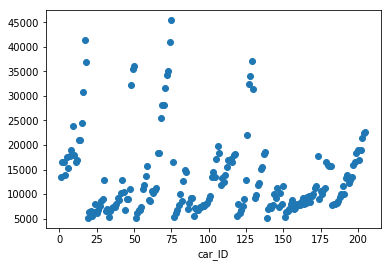

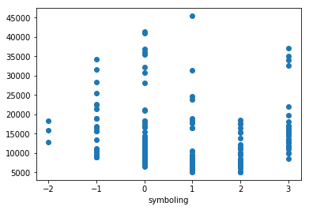

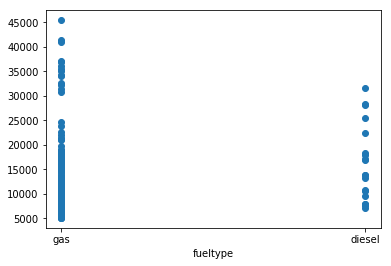

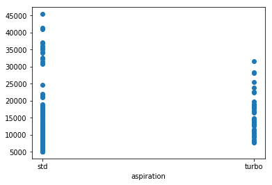

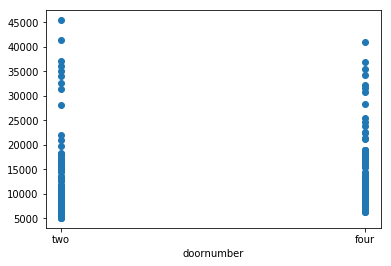

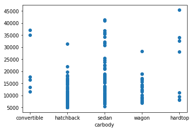

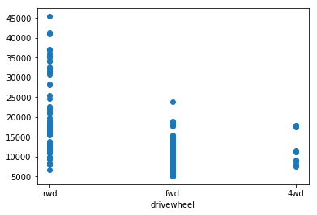

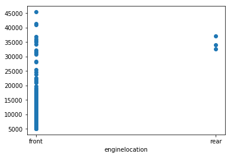

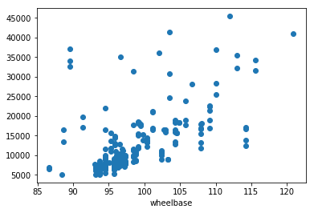

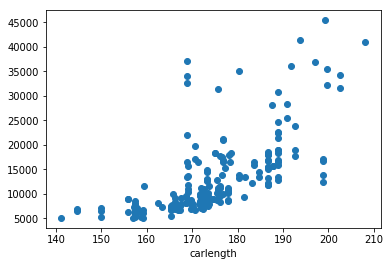

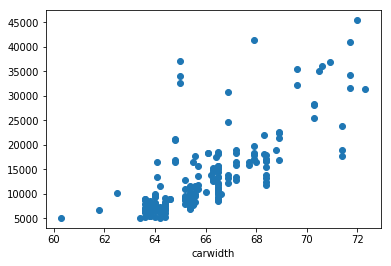

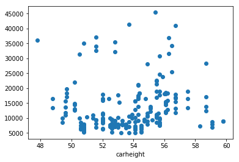

[14 more figures not shown]

```python
cols_df = list(cars.columns)
cols_df.pop(-1)  # Removing 'Model_Name' so that it does not throw error.

for i in cols_df:
    plt.scatter(i, 'price', data=cars)
    plt.xlabel(str(i))
    plt.show()
```

Plotting boxplots for the categorical variables:

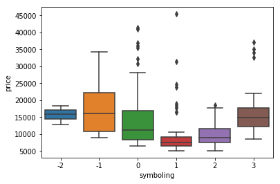

```python
sns.boxplot('symboling', 'price', data=cars)
```

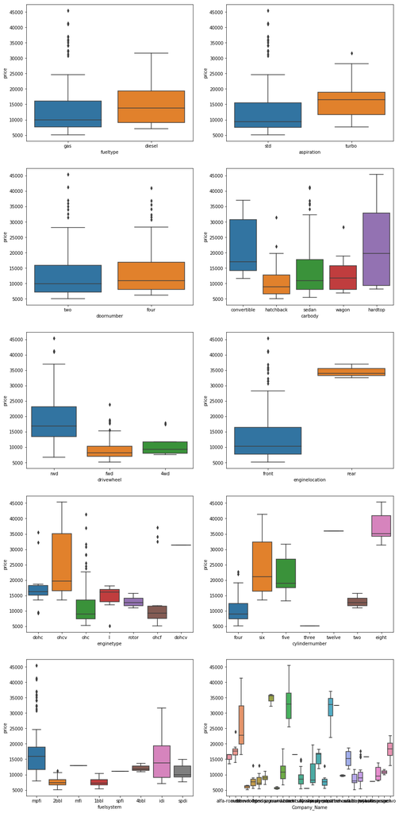

```python
cat_var = ['symboling', 'fueltype', 'aspiration', 'doornumber', 'carbody', 'drivewheel', 'enginelocation',
              'enginetype', 'cylindernumber', 'fuelsystem', 'Company_Name']

plt.figure(figsize = (15,40))
for i in cat_var[1:]:
    plt.subplot(6,2,cat_var.index(i))
    sns.boxplot(str(i), 'price', data=cars)
```

##### Preparing the Cartegorical Data:

We'll need to create dummy variables for some categorical columns and also do Label encoding where the number of levels in the variable are too high.

```python
# Preparing a list of categorical variables:
cat_var = ['symboling', 'fueltype', 'aspiration', 'doornumber', 'carbody', 'drivewheel', 'enginelocation',
              'enginetype', 'cylindernumber', 'fuelsystem', 'Company_Name']

cars[cat_var].head()
```

|  | symboling | fueltype | aspiration | doornumber | carbody | drivewheel | enginelocation | enginetype | cylindernumber | fuelsystem | Company_Name |
| --- | --- | --- | --- | --- | --- | --- | --- | --- | --- | --- | --- |
| 0 | 3 | gas | std | two | convertible | rwd | front | dohc | four | mpfi | alfa-romero |
| 1 | 3 | gas | std | two | convertible | rwd | front | dohc | four | mpfi | alfa-romero |
| 2 | 1 | gas | std | two | hatchback | rwd | front | ohcv | six | mpfi | alfa-romero |
| 3 | 2 | gas | std | four | sedan | fwd | front | ohc | four | mpfi | audi |
| 4 | 2 | gas | std | four | sedan | 4wd | front | ohc | five | mpfi | audi |

**Symboling**  
It is the measure of the risk associated with the vehicle, a higher value means high risk.  
The values can be in the range of -3 to +3 (both included). This poses a problem since there are both positive and negative values which will make it hard to interpret the coefficient of this variable.  
One thing that can be done is to make all the values positive by adding +3 to the entire column, so that:  
-3 becomes 0 and +3 becomes 6.  
This means that we've changed the range from [-3,3] to [0,6] which is easily interpretable.

```python
cars['symboling']=cars['symboling']+3
cars.head()
```

|  | car_ID | symboling | fueltype | aspiration | doornumber | carbody | drivewheel | enginelocation | wheelbase | carlength | ... | boreratio | stroke | compressionratio | horsepower | peakrpm | citympg | highwaympg | price | Company_Name | Model_Name |
| --- | --- | --- | --- | --- | --- | --- | --- | --- | --- | --- | --- | --- | --- | --- | --- | --- | --- | --- | --- | --- | --- |
| 0 | 1 | 6 | gas | std | two | convertible | rwd | front | 88.6 | 168.8 | ... | 3.47 | 2.68 | 9.0 | 111 | 5000 | 21 | 27 | 13495.0 | alfa-romero | giulia |
| 1 | 2 | 6 | gas | std | two | convertible | rwd | front | 88.6 | 168.8 | ... | 3.47 | 2.68 | 9.0 | 111 | 5000 | 21 | 27 | 16500.0 | alfa-romero | stelvio |
| 2 | 3 | 4 | gas | std | two | hatchback | rwd | front | 94.5 | 171.2 | ... | 2.68 | 3.47 | 9.0 | 154 | 5000 | 19 | 26 | 16500.0 | alfa-romero | Quadrifoglio |
| 3 | 4 | 5 | gas | std | four | sedan | fwd | front | 99.8 | 176.6 | ... | 3.19 | 3.40 | 10.0 | 102 | 5500 | 24 | 30 | 13950.0 | audi | 100 ls |
| 4 | 5 | 5 | gas | std | four | sedan | 4wd | front | 99.4 | 176.6 | ... | 3.19 | 3.40 | 8.0 | 115 | 5500 | 18 | 22 | 17450.0 | audi | 100ls |

5 rows × 27 columns

**FuelType**

```python
cars['fueltype'].value_counts()
```

```
gas       185
diesel     20
Name: fueltype, dtype: int64
```

```python
# Since there are only two categories, therfore it can be coded in a binary format:
binary_dict = {'gas':0, 'diesel':1}
cars['fueltype'] = cars['fueltype'].map(binary_dict)
cars[cat_var].head()
```

|  | symboling | fueltype | aspiration | doornumber | carbody | drivewheel | enginelocation | enginetype | cylindernumber | fuelsystem | Company_Name |
| --- | --- | --- | --- | --- | --- | --- | --- | --- | --- | --- | --- |
| 0 | 6 | 0 | std | two | convertible | rwd | front | dohc | four | mpfi | alfa-romero |
| 1 | 6 | 0 | std | two | convertible | rwd | front | dohc | four | mpfi | alfa-romero |
| 2 | 4 | 0 | std | two | hatchback | rwd | front | ohcv | six | mpfi | alfa-romero |
| 3 | 5 | 0 | std | four | sedan | fwd | front | ohc | four | mpfi | audi |
| 4 | 5 | 0 | std | four | sedan | 4wd | front | ohc | five | mpfi | audi |

**Aspiration**

```python
cars['aspiration'].value_counts()
```

```
std      168
turbo     37
Name: aspiration, dtype: int64
```

```python
# Since there are only two categories, therfore it can be coded in a binary format:
binary_dict = {'std':0, 'turbo':1}
cars['aspiration'] = cars['aspiration'].map(binary_dict)
cars[cat_var].head()
```

|  | symboling | fueltype | aspiration | doornumber | carbody | drivewheel | enginelocation | enginetype | cylindernumber | fuelsystem | Company_Name |
| --- | --- | --- | --- | --- | --- | --- | --- | --- | --- | --- | --- |
| 0 | 6 | 0 | 0 | two | convertible | rwd | front | dohc | four | mpfi | alfa-romero |
| 1 | 6 | 0 | 0 | two | convertible | rwd | front | dohc | four | mpfi | alfa-romero |
| 2 | 4 | 0 | 0 | two | hatchback | rwd | front | ohcv | six | mpfi | alfa-romero |
| 3 | 5 | 0 | 0 | four | sedan | fwd | front | ohc | four | mpfi | audi |
| 4 | 5 | 0 | 0 | four | sedan | 4wd | front | ohc | five | mpfi | audi |

**doornumber**

```python
cars['doornumber'].value_counts()
```

```
four    115
two      90
Name: doornumber, dtype: int64
```

```python
# Since there are only two categories, therfore it can be coded in a binary format:
binary_dict = {'four':0, 'two':1}
cars['doornumber'] = cars['doornumber'].map(binary_dict)
cars[cat_var].head()
```

|  | symboling | fueltype | aspiration | doornumber | carbody | drivewheel | enginelocation | enginetype | cylindernumber | fuelsystem | Company_Name |
| --- | --- | --- | --- | --- | --- | --- | --- | --- | --- | --- | --- |
| 0 | 6 | 0 | 0 | 1 | convertible | rwd | front | dohc | four | mpfi | alfa-romero |
| 1 | 6 | 0 | 0 | 1 | convertible | rwd | front | dohc | four | mpfi | alfa-romero |
| 2 | 4 | 0 | 0 | 1 | hatchback | rwd | front | ohcv | six | mpfi | alfa-romero |
| 3 | 5 | 0 | 0 | 0 | sedan | fwd | front | ohc | four | mpfi | audi |
| 4 | 5 | 0 | 0 | 0 | sedan | 4wd | front | ohc | five | mpfi | audi |

**carbody**

```python
cars['carbody'].value_counts()
```

```
sedan          96
hatchback      70
wagon          25
hardtop         8
convertible     6
Name: carbody, dtype: int64
```

```python
# since there are  different variables, therefore we can create dummy variables to represent the same.
car_body_type = pd.get_dummies(cars['carbody'], drop_first=True)
car_body_type.head()
```

|  | hardtop | hatchback | sedan | wagon |
| --- | --- | --- | --- | --- |
| 0 | 0 | 0 | 0 | 0 |
| 1 | 0 | 0 | 0 | 0 |
| 2 | 0 | 1 | 0 | 0 |
| 3 | 0 | 0 | 1 | 0 |
| 4 | 0 | 0 | 1 | 0 |

```python
cars = pd.concat([cars, car_body_type], axis='columns')
cars.head()
```

|  | car_ID | symboling | fueltype | aspiration | doornumber | carbody | drivewheel | enginelocation | wheelbase | carlength | ... | peakrpm | citympg | highwaympg | price | Company_Name | Model_Name | hardtop | hatchback | sedan | wagon |
| --- | --- | --- | --- | --- | --- | --- | --- | --- | --- | --- | --- | --- | --- | --- | --- | --- | --- | --- | --- | --- | --- |
| 0 | 1 | 6 | 0 | 0 | 1 | convertible | rwd | front | 88.6 | 168.8 | ... | 5000 | 21 | 27 | 13495.0 | alfa-romero | giulia | 0 | 0 | 0 | 0 |
| 1 | 2 | 6 | 0 | 0 | 1 | convertible | rwd | front | 88.6 | 168.8 | ... | 5000 | 21 | 27 | 16500.0 | alfa-romero | stelvio | 0 | 0 | 0 | 0 |
| 2 | 3 | 4 | 0 | 0 | 1 | hatchback | rwd | front | 94.5 | 171.2 | ... | 5000 | 19 | 26 | 16500.0 | alfa-romero | Quadrifoglio | 0 | 1 | 0 | 0 |
| 3 | 4 | 5 | 0 | 0 | 0 | sedan | fwd | front | 99.8 | 176.6 | ... | 5500 | 24 | 30 | 13950.0 | audi | 100 ls | 0 | 0 | 1 | 0 |
| 4 | 5 | 5 | 0 | 0 | 0 | sedan | 4wd | front | 99.4 | 176.6 | ... | 5500 | 18 | 22 | 17450.0 | audi | 100ls | 0 | 0 | 1 | 0 |

5 rows × 31 columns

```python
# Now that we have the dummy variables concatenated with the main dataframe, now the column 'carbody' becomes
# redundant and therefore we must drop it.
cars.drop('carbody', axis='columns', inplace= True)
cars.head()
```

|  | car_ID | symboling | fueltype | aspiration | doornumber | drivewheel | enginelocation | wheelbase | carlength | carwidth | ... | peakrpm | citympg | highwaympg | price | Company_Name | Model_Name | hardtop | hatchback | sedan | wagon |
| --- | --- | --- | --- | --- | --- | --- | --- | --- | --- | --- | --- | --- | --- | --- | --- | --- | --- | --- | --- | --- | --- |
| 0 | 1 | 6 | 0 | 0 | 1 | rwd | front | 88.6 | 168.8 | 64.1 | ... | 5000 | 21 | 27 | 13495.0 | alfa-romero | giulia | 0 | 0 | 0 | 0 |
| 1 | 2 | 6 | 0 | 0 | 1 | rwd | front | 88.6 | 168.8 | 64.1 | ... | 5000 | 21 | 27 | 16500.0 | alfa-romero | stelvio | 0 | 0 | 0 | 0 |
| 2 | 3 | 4 | 0 | 0 | 1 | rwd | front | 94.5 | 171.2 | 65.5 | ... | 5000 | 19 | 26 | 16500.0 | alfa-romero | Quadrifoglio | 0 | 1 | 0 | 0 |
| 3 | 4 | 5 | 0 | 0 | 0 | fwd | front | 99.8 | 176.6 | 66.2 | ... | 5500 | 24 | 30 | 13950.0 | audi | 100 ls | 0 | 0 | 1 | 0 |
| 4 | 5 | 5 | 0 | 0 | 0 | 4wd | front | 99.4 | 176.6 | 66.4 | ... | 5500 | 18 | 22 | 17450.0 | audi | 100ls | 0 | 0 | 1 | 0 |

5 rows × 30 columns

**DriveWheel**

```python
cars['drivewheel'].value_counts()
```

```
fwd    120
rwd     76
4wd      9
Name: drivewheel, dtype: int64
```

```python
# Again in this case, we can create 2 dummy variables to depict the kind of drive that the car has
drv_wheel = pd.get_dummies(cars['drivewheel'], drop_first=True)
drv_wheel.head()
```

|  | fwd | rwd |
| --- | --- | --- |
| 0 | 0 | 1 |
| 1 | 0 | 1 |
| 2 | 0 | 1 |
| 3 | 1 | 0 |
| 4 | 0 | 0 |

```python
# Concatenating it with the main 'cars' dataframe:
cars = pd.concat([cars, drv_wheel], axis='columns')
cars.head()
```

|  | car_ID | symboling | fueltype | aspiration | doornumber | drivewheel | enginelocation | wheelbase | carlength | carwidth | ... | highwaympg | price | Company_Name | Model_Name | hardtop | hatchback | sedan | wagon | fwd | rwd |
| --- | --- | --- | --- | --- | --- | --- | --- | --- | --- | --- | --- | --- | --- | --- | --- | --- | --- | --- | --- | --- | --- |
| 0 | 1 | 6 | 0 | 0 | 1 | rwd | front | 88.6 | 168.8 | 64.1 | ... | 27 | 13495.0 | alfa-romero | giulia | 0 | 0 | 0 | 0 | 0 | 1 |
| 1 | 2 | 6 | 0 | 0 | 1 | rwd | front | 88.6 | 168.8 | 64.1 | ... | 27 | 16500.0 | alfa-romero | stelvio | 0 | 0 | 0 | 0 | 0 | 1 |
| 2 | 3 | 4 | 0 | 0 | 1 | rwd | front | 94.5 | 171.2 | 65.5 | ... | 26 | 16500.0 | alfa-romero | Quadrifoglio | 0 | 1 | 0 | 0 | 0 | 1 |
| 3 | 4 | 5 | 0 | 0 | 0 | fwd | front | 99.8 | 176.6 | 66.2 | ... | 30 | 13950.0 | audi | 100 ls | 0 | 0 | 1 | 0 | 1 | 0 |
| 4 | 5 | 5 | 0 | 0 | 0 | 4wd | front | 99.4 | 176.6 | 66.4 | ... | 22 | 17450.0 | audi | 100ls | 0 | 0 | 1 | 0 | 0 | 0 |

5 rows × 32 columns

```python
# Also we will drop the 'drivewheel' variable due to redundancy:
cars.drop('drivewheel', axis='columns', inplace=True)
cars.head()
```

|  | car_ID | symboling | fueltype | aspiration | doornumber | enginelocation | wheelbase | carlength | carwidth | carheight | ... | highwaympg | price | Company_Name | Model_Name | hardtop | hatchback | sedan | wagon | fwd | rwd |
| --- | --- | --- | --- | --- | --- | --- | --- | --- | --- | --- | --- | --- | --- | --- | --- | --- | --- | --- | --- | --- | --- |
| 0 | 1 | 6 | 0 | 0 | 1 | front | 88.6 | 168.8 | 64.1 | 48.8 | ... | 27 | 13495.0 | alfa-romero | giulia | 0 | 0 | 0 | 0 | 0 | 1 |
| 1 | 2 | 6 | 0 | 0 | 1 | front | 88.6 | 168.8 | 64.1 | 48.8 | ... | 27 | 16500.0 | alfa-romero | stelvio | 0 | 0 | 0 | 0 | 0 | 1 |
| 2 | 3 | 4 | 0 | 0 | 1 | front | 94.5 | 171.2 | 65.5 | 52.4 | ... | 26 | 16500.0 | alfa-romero | Quadrifoglio | 0 | 1 | 0 | 0 | 0 | 1 |
| 3 | 4 | 5 | 0 | 0 | 0 | front | 99.8 | 176.6 | 66.2 | 54.3 | ... | 30 | 13950.0 | audi | 100 ls | 0 | 0 | 1 | 0 | 1 | 0 |
| 4 | 5 | 5 | 0 | 0 | 0 | front | 99.4 | 176.6 | 66.4 | 54.3 | ... | 22 | 17450.0 | audi | 100ls | 0 | 0 | 1 | 0 | 0 | 0 |

5 rows × 31 columns

**EngineLocation**

```python
cars['enginelocation'].value_counts()
```

```
front    202
rear       3
Name: enginelocation, dtype: int64
```

```python
# Since there are only two categories, therfore it can be coded in a binary format:
binary_dict = {'front':0, 'rear':1}
cars['enginelocation'] = cars['enginelocation'].map(binary_dict)
cars.head()
```

|  | car_ID | symboling | fueltype | aspiration | doornumber | enginelocation | wheelbase | carlength | carwidth | carheight | ... | highwaympg | price | Company_Name | Model_Name | hardtop | hatchback | sedan | wagon | fwd | rwd |
| --- | --- | --- | --- | --- | --- | --- | --- | --- | --- | --- | --- | --- | --- | --- | --- | --- | --- | --- | --- | --- | --- |
| 0 | 1 | 6 | 0 | 0 | 1 | 0 | 88.6 | 168.8 | 64.1 | 48.8 | ... | 27 | 13495.0 | alfa-romero | giulia | 0 | 0 | 0 | 0 | 0 | 1 |
| 1 | 2 | 6 | 0 | 0 | 1 | 0 | 88.6 | 168.8 | 64.1 | 48.8 | ... | 27 | 16500.0 | alfa-romero | stelvio | 0 | 0 | 0 | 0 | 0 | 1 |
| 2 | 3 | 4 | 0 | 0 | 1 | 0 | 94.5 | 171.2 | 65.5 | 52.4 | ... | 26 | 16500.0 | alfa-romero | Quadrifoglio | 0 | 1 | 0 | 0 | 0 | 1 |
| 3 | 4 | 5 | 0 | 0 | 0 | 0 | 99.8 | 176.6 | 66.2 | 54.3 | ... | 30 | 13950.0 | audi | 100 ls | 0 | 0 | 1 | 0 | 1 | 0 |
| 4 | 5 | 5 | 0 | 0 | 0 | 0 | 99.4 | 176.6 | 66.4 | 54.3 | ... | 22 | 17450.0 | audi | 100ls | 0 | 0 | 1 | 0 | 0 | 0 |

5 rows × 31 columns

**enginetype**

```python
cars['enginetype'].value_counts()
```

```
ohc      148
ohcf      15
ohcv      13
l         12
dohc      12
rotor      4
dohcv      1
Name: enginetype, dtype: int64
```

```python
# Creating dummy variables:
eng_typ = pd.get_dummies(cars['enginetype'], drop_first=True)
eng_typ.head()
```

|  | dohcv | l | ohc | ohcf | ohcv | rotor |
| --- | --- | --- | --- | --- | --- | --- |
| 0 | 0 | 0 | 0 | 0 | 0 | 0 |
| 1 | 0 | 0 | 0 | 0 | 0 | 0 |
| 2 | 0 | 0 | 0 | 0 | 1 | 0 |
| 3 | 0 | 0 | 1 | 0 | 0 | 0 |
| 4 | 0 | 0 | 1 | 0 | 0 | 0 |

```python
# Concatenating:
cars = pd.concat([cars, eng_typ], axis='columns')
cars.head()
```

|  | car_ID | symboling | fueltype | aspiration | doornumber | enginelocation | wheelbase | carlength | carwidth | carheight | ... | sedan | wagon | fwd | rwd | dohcv | l | ohc | ohcf | ohcv | rotor |
| --- | --- | --- | --- | --- | --- | --- | --- | --- | --- | --- | --- | --- | --- | --- | --- | --- | --- | --- | --- | --- | --- |
| 0 | 1 | 6 | 0 | 0 | 1 | 0 | 88.6 | 168.8 | 64.1 | 48.8 | ... | 0 | 0 | 0 | 1 | 0 | 0 | 0 | 0 | 0 | 0 |
| 1 | 2 | 6 | 0 | 0 | 1 | 0 | 88.6 | 168.8 | 64.1 | 48.8 | ... | 0 | 0 | 0 | 1 | 0 | 0 | 0 | 0 | 0 | 0 |
| 2 | 3 | 4 | 0 | 0 | 1 | 0 | 94.5 | 171.2 | 65.5 | 52.4 | ... | 0 | 0 | 0 | 1 | 0 | 0 | 0 | 0 | 1 | 0 |
| 3 | 4 | 5 | 0 | 0 | 0 | 0 | 99.8 | 176.6 | 66.2 | 54.3 | ... | 1 | 0 | 1 | 0 | 0 | 0 | 1 | 0 | 0 | 0 |
| 4 | 5 | 5 | 0 | 0 | 0 | 0 | 99.4 | 176.6 | 66.4 | 54.3 | ... | 1 | 0 | 0 | 0 | 0 | 0 | 1 | 0 | 0 | 0 |

5 rows × 37 columns

```python
# Dropping the 'enginetype' column:
cars.drop('enginetype', axis='columns', inplace=True)
cars.head()
```

|  | car_ID | symboling | fueltype | aspiration | doornumber | enginelocation | wheelbase | carlength | carwidth | carheight | ... | sedan | wagon | fwd | rwd | dohcv | l | ohc | ohcf | ohcv | rotor |
| --- | --- | --- | --- | --- | --- | --- | --- | --- | --- | --- | --- | --- | --- | --- | --- | --- | --- | --- | --- | --- | --- |
| 0 | 1 | 6 | 0 | 0 | 1 | 0 | 88.6 | 168.8 | 64.1 | 48.8 | ... | 0 | 0 | 0 | 1 | 0 | 0 | 0 | 0 | 0 | 0 |
| 1 | 2 | 6 | 0 | 0 | 1 | 0 | 88.6 | 168.8 | 64.1 | 48.8 | ... | 0 | 0 | 0 | 1 | 0 | 0 | 0 | 0 | 0 | 0 |
| 2 | 3 | 4 | 0 | 0 | 1 | 0 | 94.5 | 171.2 | 65.5 | 52.4 | ... | 0 | 0 | 0 | 1 | 0 | 0 | 0 | 0 | 1 | 0 |
| 3 | 4 | 5 | 0 | 0 | 0 | 0 | 99.8 | 176.6 | 66.2 | 54.3 | ... | 1 | 0 | 1 | 0 | 0 | 0 | 1 | 0 | 0 | 0 |
| 4 | 5 | 5 | 0 | 0 | 0 | 0 | 99.4 | 176.6 | 66.4 | 54.3 | ... | 1 | 0 | 0 | 0 | 0 | 0 | 1 | 0 | 0 | 0 |

5 rows × 36 columns

**cylindernumber**

```python
cars['cylindernumber'].value_counts()
```

```
four      159
six        24
five       11
eight       5
two         4
twelve      1
three       1
Name: cylindernumber, dtype: int64
```

```python
# Since this an ordinal categorical variable, with fairly less number of levels, therefore in order to reduce the
# number of columns (which have increased due to dummy variables), we'll encode it manually.
cyl_dict = {'two':0, 'three':1, 'four':2, 'five':3, 'six':4, 'eight':5, 'twelve':6}
cars['cylindernumber'] = cars['cylindernumber'].map(cyl_dict)
cars.head()
```

|  | car_ID | symboling | fueltype | aspiration | doornumber | enginelocation | wheelbase | carlength | carwidth | carheight | ... | sedan | wagon | fwd | rwd | dohcv | l | ohc | ohcf | ohcv | rotor |
| --- | --- | --- | --- | --- | --- | --- | --- | --- | --- | --- | --- | --- | --- | --- | --- | --- | --- | --- | --- | --- | --- |
| 0 | 1 | 6 | 0 | 0 | 1 | 0 | 88.6 | 168.8 | 64.1 | 48.8 | ... | 0 | 0 | 0 | 1 | 0 | 0 | 0 | 0 | 0 | 0 |
| 1 | 2 | 6 | 0 | 0 | 1 | 0 | 88.6 | 168.8 | 64.1 | 48.8 | ... | 0 | 0 | 0 | 1 | 0 | 0 | 0 | 0 | 0 | 0 |
| 2 | 3 | 4 | 0 | 0 | 1 | 0 | 94.5 | 171.2 | 65.5 | 52.4 | ... | 0 | 0 | 0 | 1 | 0 | 0 | 0 | 0 | 1 | 0 |
| 3 | 4 | 5 | 0 | 0 | 0 | 0 | 99.8 | 176.6 | 66.2 | 54.3 | ... | 1 | 0 | 1 | 0 | 0 | 0 | 1 | 0 | 0 | 0 |
| 4 | 5 | 5 | 0 | 0 | 0 | 0 | 99.4 | 176.6 | 66.4 | 54.3 | ... | 1 | 0 | 0 | 0 | 0 | 0 | 1 | 0 | 0 | 0 |

5 rows × 36 columns

**fuelsystem**

```python
cars['fuelsystem'].value_counts()
```

```
mpfi    94
2bbl    66
idi     20
1bbl    11
spdi     9
4bbl     3
spfi     1
mfi      1
Name: fuelsystem, dtype: int64
```

```python
# Creating dummy variables:
fuel_sys = pd.get_dummies(cars['fuelsystem'], drop_first=True)
fuel_sys.head()

# Concatenating:
cars = pd.concat([cars, fuel_sys], axis='columns')
cars.head()
```

|  | car_ID | symboling | fueltype | aspiration | doornumber | enginelocation | wheelbase | carlength | carwidth | carheight | ... | ohcf | ohcv | rotor | 2bbl | 4bbl | idi | mfi | mpfi | spdi | spfi |
| --- | --- | --- | --- | --- | --- | --- | --- | --- | --- | --- | --- | --- | --- | --- | --- | --- | --- | --- | --- | --- | --- |
| 0 | 1 | 6 | 0 | 0 | 1 | 0 | 88.6 | 168.8 | 64.1 | 48.8 | ... | 0 | 0 | 0 | 0 | 0 | 0 | 0 | 1 | 0 | 0 |
| 1 | 2 | 6 | 0 | 0 | 1 | 0 | 88.6 | 168.8 | 64.1 | 48.8 | ... | 0 | 0 | 0 | 0 | 0 | 0 | 0 | 1 | 0 | 0 |
| 2 | 3 | 4 | 0 | 0 | 1 | 0 | 94.5 | 171.2 | 65.5 | 52.4 | ... | 0 | 1 | 0 | 0 | 0 | 0 | 0 | 1 | 0 | 0 |
| 3 | 4 | 5 | 0 | 0 | 0 | 0 | 99.8 | 176.6 | 66.2 | 54.3 | ... | 0 | 0 | 0 | 0 | 0 | 0 | 0 | 1 | 0 | 0 |
| 4 | 5 | 5 | 0 | 0 | 0 | 0 | 99.4 | 176.6 | 66.4 | 54.3 | ... | 0 | 0 | 0 | 0 | 0 | 0 | 0 | 1 | 0 | 0 |

5 rows × 43 columns

```python
# Dropping the redundant 'fuelsystem' column:
cars.drop('fuelsystem', axis='columns', inplace=True)
cars.head()
```

|  | car_ID | symboling | fueltype | aspiration | doornumber | enginelocation | wheelbase | carlength | carwidth | carheight | ... | ohcf | ohcv | rotor | 2bbl | 4bbl | idi | mfi | mpfi | spdi | spfi |
| --- | --- | --- | --- | --- | --- | --- | --- | --- | --- | --- | --- | --- | --- | --- | --- | --- | --- | --- | --- | --- | --- |
| 0 | 1 | 6 | 0 | 0 | 1 | 0 | 88.6 | 168.8 | 64.1 | 48.8 | ... | 0 | 0 | 0 | 0 | 0 | 0 | 0 | 1 | 0 | 0 |
| 1 | 2 | 6 | 0 | 0 | 1 | 0 | 88.6 | 168.8 | 64.1 | 48.8 | ... | 0 | 0 | 0 | 0 | 0 | 0 | 0 | 1 | 0 | 0 |
| 2 | 3 | 4 | 0 | 0 | 1 | 0 | 94.5 | 171.2 | 65.5 | 52.4 | ... | 0 | 1 | 0 | 0 | 0 | 0 | 0 | 1 | 0 | 0 |
| 3 | 4 | 5 | 0 | 0 | 0 | 0 | 99.8 | 176.6 | 66.2 | 54.3 | ... | 0 | 0 | 0 | 0 | 0 | 0 | 0 | 1 | 0 | 0 |
| 4 | 5 | 5 | 0 | 0 | 0 | 0 | 99.4 | 176.6 | 66.4 | 54.3 | ... | 0 | 0 | 0 | 0 | 0 | 0 | 0 | 1 | 0 | 0 |

5 rows × 42 columns

**Company_Name**

```python
cars['Company_Name'].value_counts()
```

```
toyota         31
nissan         17
mazda          15
mitsubishi     13
honda          13
subaru         12
volvo          11
peugeot        11
volkswagen      9
dodge           9
bmw             8
buick           8
plymouth        7
audi            7
saab            6
isuzu           4
porsche         4
alfa-romero     3
jaguar          3
chevrolet       3
maxda           2
renault         2
vw              2
Nissan          1
toyouta         1
porcshce        1
vokswagen       1
mercury         1
Name: Company_Name, dtype: int64
```

```python
# Since there are a lot of categories, creating dummy variables would render our dataframe rather large and therefore
# we must go for label encoding.
from sklearn.preprocessing import LabelEncoder
```

```python
# Instantiating the LabelEncoder:
le = LabelEncoder()
```

```python
# Fitting and Transforming the variable:
cars['Company_Name'] = le.fit_transform(cars['Company_Name'])
cars.head()
```

|  | car_ID | symboling | fueltype | aspiration | doornumber | enginelocation | wheelbase | carlength | carwidth | carheight | ... | ohcf | ohcv | rotor | 2bbl | 4bbl | idi | mfi | mpfi | spdi | spfi |
| --- | --- | --- | --- | --- | --- | --- | --- | --- | --- | --- | --- | --- | --- | --- | --- | --- | --- | --- | --- | --- | --- |
| 0 | 1 | 6 | 0 | 0 | 1 | 0 | 88.6 | 168.8 | 64.1 | 48.8 | ... | 0 | 0 | 0 | 0 | 0 | 0 | 0 | 1 | 0 | 0 |
| 1 | 2 | 6 | 0 | 0 | 1 | 0 | 88.6 | 168.8 | 64.1 | 48.8 | ... | 0 | 0 | 0 | 0 | 0 | 0 | 0 | 1 | 0 | 0 |
| 2 | 3 | 4 | 0 | 0 | 1 | 0 | 94.5 | 171.2 | 65.5 | 52.4 | ... | 0 | 1 | 0 | 0 | 0 | 0 | 0 | 1 | 0 | 0 |
| 3 | 4 | 5 | 0 | 0 | 0 | 0 | 99.8 | 176.6 | 66.2 | 54.3 | ... | 0 | 0 | 0 | 0 | 0 | 0 | 0 | 1 | 0 | 0 |
| 4 | 5 | 5 | 0 | 0 | 0 | 0 | 99.4 | 176.6 | 66.4 | 54.3 | ... | 0 | 0 | 0 | 0 | 0 | 0 | 0 | 1 | 0 | 0 |

5 rows × 42 columns

```python
cars['Company_Name'].head()
```

```
0    1
1    1
2    1
3    2
4    2
Name: Company_Name, dtype: int64
```

Now that we are done with the preliminary analysis, therfore we can start with the splitting the data into training and testing sets.

### Splitting the data into Traning and Test Datasets:

```python
from sklearn.model_selection import train_test_split
```

```python
df_train, df_test = train_test_split(cars, train_size = 0.7, random_state = 33)
print(df_train.shape)
print(df_test.shape)
```

```
(143, 42)
(62, 42)
```

Having a look at the training dataset

```python
df_train.describe()
```

|  | car_ID | symboling | fueltype | aspiration | doornumber | enginelocation | wheelbase | carlength | carwidth | carheight | ... | ohcf | ohcv | rotor | 2bbl | 4bbl | idi | mfi | mpfi | spdi | spfi |
| --- | --- | --- | --- | --- | --- | --- | --- | --- | --- | --- | --- | --- | --- | --- | --- | --- | --- | --- | --- | --- | --- |
| count | 143.000000 | 143.000000 | 143.000000 | 143.000000 | 143.000000 | 143.000000 | 143.000000 | 143.000000 | 143.000000 | 143.000000 | ... | 143.000000 | 143.000000 | 143.000000 | 143.000000 | 143.000000 | 143.000000 | 143.0 | 143.000000 | 143.000000 | 143.000000 |
| mean | 97.153846 | 3.867133 | 0.097902 | 0.160839 | 0.447552 | 0.013986 | 98.576923 | 173.715385 | 65.793706 | 53.653846 | ... | 0.083916 | 0.062937 | 0.027972 | 0.335664 | 0.020979 | 0.097902 | 0.0 | 0.433566 | 0.041958 | 0.006993 |
| std | 58.437556 | 1.279512 | 0.298227 | 0.368674 | 0.498989 | 0.117845 | 6.001522 | 12.296829 | 2.069776 | 2.468442 | ... | 0.278236 | 0.243703 | 0.165472 | 0.473882 | 0.143818 | 0.298227 | 0.0 | 0.497309 | 0.201198 | 0.083624 |
| min | 1.000000 | 1.000000 | 0.000000 | 0.000000 | 0.000000 | 0.000000 | 86.600000 | 141.100000 | 60.300000 | 47.800000 | ... | 0.000000 | 0.000000 | 0.000000 | 0.000000 | 0.000000 | 0.000000 | 0.0 | 0.000000 | 0.000000 | 0.000000 |
| 25% | 48.000000 | 3.000000 | 0.000000 | 0.000000 | 0.000000 | 0.000000 | 94.500000 | 166.550000 | 64.050000 | 52.000000 | ... | 0.000000 | 0.000000 | 0.000000 | 0.000000 | 0.000000 | 0.000000 | 0.0 | 0.000000 | 0.000000 | 0.000000 |
| 50% | 96.000000 | 4.000000 | 0.000000 | 0.000000 | 0.000000 | 0.000000 | 96.900000 | 173.200000 | 65.400000 | 53.900000 | ... | 0.000000 | 0.000000 | 0.000000 | 0.000000 | 0.000000 | 0.000000 | 0.0 | 0.000000 | 0.000000 | 0.000000 |
| 75% | 143.500000 | 5.000000 | 0.000000 | 0.000000 | 1.000000 | 0.000000 | 101.200000 | 179.350000 | 66.500000 | 55.500000 | ... | 0.000000 | 0.000000 | 0.000000 | 1.000000 | 0.000000 | 0.000000 | 0.0 | 1.000000 | 0.000000 | 0.000000 |
| max | 204.000000 | 6.000000 | 1.000000 | 1.000000 | 1.000000 | 1.000000 | 120.900000 | 208.100000 | 72.000000 | 59.800000 | ... | 1.000000 | 1.000000 | 1.000000 | 1.000000 | 1.000000 | 1.000000 | 0.0 | 1.000000 | 1.000000 | 1.000000 |

8 rows × 41 columns

We can see that the range of values of the numerical variables are on different scales and therefore interpretation of the coefficients will become a difficult task.  
Hence we must rescale the numerical variables.

### Rescaling the numerical variables:

```python
from sklearn.preprocessing import MinMaxScaler
```

```python
# Instantiating the scaler variable:
scaler = MinMaxScaler()
```

```python
# Getting a list of all numerical variables:

num_vars = ['wheelbase',
'carlength',
'carwidth',
'carheight',
'curbweight',
'enginesize',
'boreratio',
'stroke',
'compressionratio',
'horsepower',
'peakrpm',
'citympg',
'highwaympg',
'price']

df_train[num_vars].describe()
```

|  | wheelbase | carlength | carwidth | carheight | curbweight | enginesize | boreratio | stroke | compressionratio | horsepower | peakrpm | citympg | highwaympg | price |
| --- | --- | --- | --- | --- | --- | --- | --- | --- | --- | --- | --- | --- | --- | --- |
| count | 143.000000 | 143.000000 | 143.000000 | 143.000000 | 143.000000 | 143.000000 | 143.000000 | 143.000000 | 143.000000 | 143.000000 | 143.000000 | 143.000000 | 143.000000 | 143.000000 |
| mean | 98.576923 | 173.715385 | 65.793706 | 53.653846 | 2529.006993 | 125.048951 | 3.324895 | 3.241538 | 10.154685 | 101.454545 | 5097.202797 | 25.517483 | 31.139860 | 12952.242427 |
| std | 6.001522 | 12.296829 | 2.069776 | 2.468442 | 511.533919 | 42.158542 | 0.272386 | 0.316156 | 3.981544 | 37.378107 | 472.138386 | 6.778023 | 7.056713 | 7778.660428 |
| min | 86.600000 | 141.100000 | 60.300000 | 47.800000 | 1488.000000 | 61.000000 | 2.540000 | 2.070000 | 7.000000 | 48.000000 | 4150.000000 | 13.000000 | 16.000000 | 5118.000000 |
| 25% | 94.500000 | 166.550000 | 64.050000 | 52.000000 | 2136.500000 | 97.000000 | 3.150000 | 3.110000 | 8.600000 | 70.000000 | 4800.000000 | 19.500000 | 25.000000 | 7649.000000 |
| 50% | 96.900000 | 173.200000 | 65.400000 | 53.900000 | 2410.000000 | 120.000000 | 3.330000 | 3.270000 | 9.000000 | 92.000000 | 5100.000000 | 25.000000 | 31.000000 | 10295.000000 |
| 75% | 101.200000 | 179.350000 | 66.500000 | 55.500000 | 2834.000000 | 138.000000 | 3.580000 | 3.410000 | 9.400000 | 115.500000 | 5500.000000 | 31.000000 | 37.000000 | 16500.000000 |
| max | 120.900000 | 208.100000 | 72.000000 | 59.800000 | 4066.000000 | 326.000000 | 3.940000 | 4.170000 | 23.000000 | 262.000000 | 6000.000000 | 49.000000 | 54.000000 | 45400.000000 |

```python
# Fitting and Transforming the data:
df_train[num_vars] = scaler.fit_transform(df_train[num_vars])
```

```python
df_train[num_vars].describe()
```

|  | wheelbase | carlength | carwidth | carheight | curbweight | enginesize | boreratio | stroke | compressionratio | horsepower | peakrpm | citympg | highwaympg | price |
| --- | --- | --- | --- | --- | --- | --- | --- | --- | --- | --- | --- | --- | --- | --- |
| count | 143.000000 | 143.000000 | 143.000000 | 143.000000 | 143.000000 | 143.000000 | 143.000000 | 143.000000 | 143.000000 | 143.000000 | 143.000000 | 143.000000 | 143.000000 | 143.000000 |
| mean | 0.349181 | 0.486797 | 0.469548 | 0.487821 | 0.403804 | 0.241694 | 0.560639 | 0.557875 | 0.197168 | 0.249788 | 0.512002 | 0.347708 | 0.398417 | 0.194485 |
| std | 0.174971 | 0.183535 | 0.176904 | 0.205704 | 0.198423 | 0.159089 | 0.194561 | 0.150551 | 0.248847 | 0.174664 | 0.255210 | 0.188278 | 0.185703 | 0.193105 |
| min | 0.000000 | 0.000000 | 0.000000 | 0.000000 | 0.000000 | 0.000000 | 0.000000 | 0.000000 | 0.000000 | 0.000000 | 0.000000 | 0.000000 | 0.000000 | 0.000000 |
| 25% | 0.230321 | 0.379851 | 0.320513 | 0.350000 | 0.251552 | 0.135849 | 0.435714 | 0.495238 | 0.100000 | 0.102804 | 0.351351 | 0.180556 | 0.236842 | 0.062832 |
| 50% | 0.300292 | 0.479104 | 0.435897 | 0.508333 | 0.357642 | 0.222642 | 0.564286 | 0.571429 | 0.125000 | 0.205607 | 0.513514 | 0.333333 | 0.394737 | 0.128519 |
| 75% | 0.425656 | 0.570896 | 0.529915 | 0.641667 | 0.522110 | 0.290566 | 0.742857 | 0.638095 | 0.150000 | 0.315421 | 0.729730 | 0.500000 | 0.552632 | 0.282558 |
| max | 1.000000 | 1.000000 | 1.000000 | 1.000000 | 1.000000 | 1.000000 | 1.000000 | 1.000000 | 1.000000 | 1.000000 | 1.000000 | 1.000000 | 1.000000 | 1.000000 |

We can see that the values have been rescaled between 0 and 1 which means that the coefficients of these variables will be comparable.

#### Finding the correlation of all the variables with Price:

This is done in order to get an idea of all the variables that have a strong relationship with the Price variable. This will give us an understanding of how the price is affected by each variable.

```python
num_dtype = df_train.select_dtypes(['int64', 'float64', 'uint8'])
```

```python
l1 = []
l2 = []
for i in num_dtype.columns:
    l1.append(str(i))

for i in num_dtype.columns:
    l2.append(df_train['price'].corr(df_train[str(i)]))
```

```python
corr_df = pd.DataFrame({'Column':l1, 'Correlation':l2})
corr_df = corr_df.sort_values('Correlation', ascending = False)
corr_df
```

|  | Column | Correlation |
| --- | --- | --- |
| 20 | price | 1.000000 |
| 12 | enginesize | 0.873828 |
| 10 | curbweight | 0.833601 |
| 16 | horsepower | 0.819037 |
| 8 | carwidth | 0.735662 |
| 11 | cylindernumber | 0.695689 |
| 7 | carlength | 0.667157 |
| 27 | rwd | 0.628976 |
| 6 | wheelbase | 0.547283 |
| 38 | mpfi | 0.527190 |
| 13 | boreratio | 0.514601 |
| 32 | ohcv | 0.458201 |
| 22 | hardtop | 0.327301 |
| 5 | enginelocation | 0.312299 |
| 3 | aspiration | 0.196155 |
| 2 | fueltype | 0.118048 |
| 36 | idi | 0.118048 |
| 24 | sedan | 0.107383 |
| 14 | stroke | 0.082304 |
| 15 | compressionratio | 0.078539 |
| 29 | l | 0.058611 |
| 9 | carheight | 0.058174 |
| 4 | doornumber | 0.028346 |
| 33 | rotor | 0.001483 |
| 35 | 4bbl | -0.015245 |
| 40 | spfi | -0.020616 |
| 31 | ohcf | -0.022347 |
| 1 | symboling | -0.031987 |
| 39 | spdi | -0.038987 |
| 25 | wagon | -0.051285 |
| 0 | car_ID | -0.075978 |
| 17 | peakrpm | -0.104403 |
| 21 | Company_Name | -0.203174 |
| 23 | hatchback | -0.261848 |
| 30 | ohc | -0.342216 |
| 34 | 2bbl | -0.507809 |
| 26 | fwd | -0.614027 |
| 18 | citympg | -0.662964 |
| 19 | highwaympg | -0.693718 |
| 28 | dohcv | NaN |
| 37 | mfi | NaN |

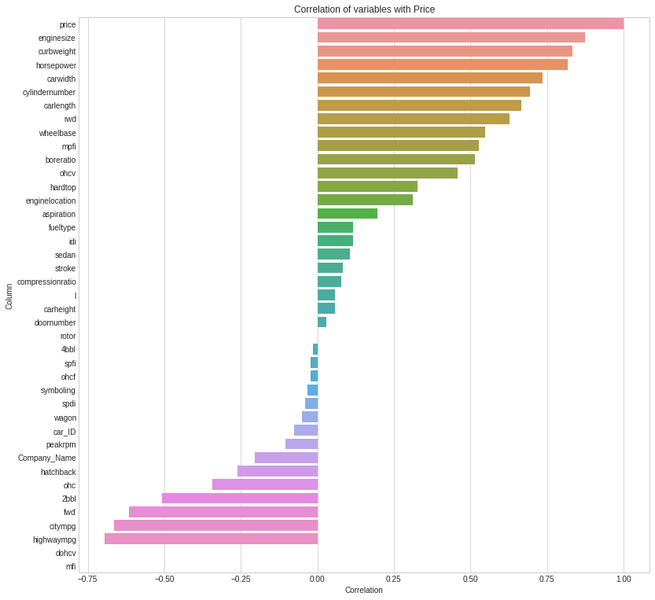

```python
plt.style.use('seaborn-whitegrid')
plt.figure(figsize = (13, 13))
sns.barplot('Correlation', 'Column', data=corr_df)
plt.title('Correlation of variables with Price')
plt.show()
```

From the above plot, we can see that there are a number of variables which are highly correlated with the Price of the car.

To get the overall plot, we can make a heatmap.

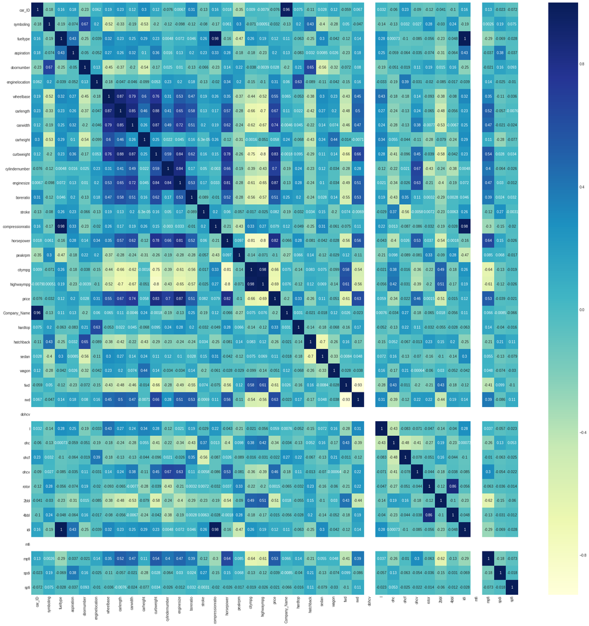

```python
plt.figure(figsize = (30,30))
sns.heatmap(df_train.corr(), annot = True, cmap="YlGnBu")
```

## Traning the model:

#### Instantiating the X(independent) and y(dependent) variables:

In the cars dataset, we have some variables such as **car_ID** and **Model_Name** that are not useful in our analysis since **car_ID** acts like an index and **Model_Name** is not to be used. Therefore these variables can be dropped.

```python
df_train.pop('car_ID')
df_train.pop('Model_Name')
```

```
22       challenger se
136              99gle
148                 dl
81                  g4
101               dayz
149                 dl
98             clipper
9       5000s (diesel)
6                100ls
115                504
89               versa
95                juke
194          145e (sw)
134               99le
133               99le
```

[output cut: 47 more lines]

```python
# Instantiating the variables:
y_train = df_train.pop('price')
X_train = df_train
```

### Building the model:

```python
import statsmodels.api as sm
```

Following a **bottom-up approach**, let us build the first model using all the variables available.

```python
# Adding a constant to the indpendent variables so that the regression line does not pass through the origin
X_train_model = sm.add_constant(X_train)

# Fitting the model:
lr = sm.OLS(y_train, X_train_model).fit()

# Summary of the model:
lr.summary()
```

OLS Regression Results

| Dep. Variable: | price | R-squared: | 0.930 |
| --- | --- | --- | --- |
| Model: | OLS | Adj. R-squared: | 0.907 |
| Method: | Least Squares | F-statistic: | 39.41 |
| Date: | Sun, 14 Jul 2019 | Prob (F-statistic): | 1.01e-46 |
| Time: | 07:09:18 | Log-Likelihood: | 223.40 |
| No. Observations: | 143 | AIC: | -372.8 |
| Df Residuals: | 106 | BIC: | -263.2 |
| Df Model: | 36 |  |  |
| Covariance Type: | nonrobust |  |  |

|  | coef | std err | t | P>\|t\| | [0.025 | 0.975] |
| --- | --- | --- | --- | --- | --- | --- |
| const | -0.2694 | 0.116 | -2.332 | 0.022 | -0.499 | -0.040 |
| symboling | 0.0093 | 0.007 | 1.277 | 0.204 | -0.005 | 0.024 |
| fueltype | 0.1738 | 0.094 | 1.858 | 0.066 | -0.012 | 0.359 |
| aspiration | 0.0321 | 0.031 | 1.030 | 0.306 | -0.030 | 0.094 |
| doornumber | -0.0185 | 0.021 | -0.889 | 0.376 | -0.060 | 0.023 |
| enginelocation | 0.1292 | 0.088 | 1.465 | 0.146 | -0.046 | 0.304 |
| wheelbase | 0.0924 | 0.109 | 0.844 | 0.400 | -0.124 | 0.309 |
| carlength | -0.0332 | 0.105 | -0.317 | 0.752 | -0.241 | 0.175 |
| carwidth | 0.0914 | 0.079 | 1.163 | 0.247 | -0.064 | 0.247 |
| carheight | 0.0814 | 0.048 | 1.695 | 0.093 | -0.014 | 0.177 |
| curbweight | 0.2839 | 0.165 | 1.719 | 0.088 | -0.043 | 0.611 |
| cylindernumber | 0.0308 | 0.022 | 1.389 | 0.168 | -0.013 | 0.075 |
| enginesize | 0.7036 | 0.175 | 4.013 | 0.000 | 0.356 | 1.051 |
| boreratio | -0.0446 | 0.064 | -0.698 | 0.486 | -0.171 | 0.082 |
| stroke | -0.1784 | 0.056 | -3.213 | 0.002 | -0.288 | -0.068 |
| compressionratio | -0.3882 | 0.212 | -1.830 | 0.070 | -0.809 | 0.032 |
| horsepower | 0.1164 | 0.163 | 0.716 | 0.476 | -0.206 | 0.439 |
| peakrpm | 0.0721 | 0.039 | 1.839 | 0.069 | -0.006 | 0.150 |
| citympg | 0.0958 | 0.180 | 0.532 | 0.596 | -0.261 | 0.453 |
| highwaympg | 0.1495 | 0.185 | 0.807 | 0.422 | -0.218 | 0.517 |
| Company_Name | -0.0040 | 0.001 | -4.073 | 0.000 | -0.006 | -0.002 |
| hardtop | -0.0259 | 0.058 | -0.443 | 0.659 | -0.142 | 0.090 |
| hatchback | -0.0804 | 0.047 | -1.721 | 0.088 | -0.173 | 0.012 |
| sedan | -0.0900 | 0.051 | -1.760 | 0.081 | -0.191 | 0.011 |
| wagon | -0.1249 | 0.054 | -2.318 | 0.022 | -0.232 | -0.018 |
| fwd | 0.0201 | 0.035 | 0.573 | 0.568 | -0.049 | 0.089 |
| rwd | 0.0616 | 0.038 | 1.635 | 0.105 | -0.013 | 0.136 |
| dohcv | 2.047e-17 | 2.76e-17 | 0.741 | 0.460 | -3.43e-17 | 7.53e-17 |
| l | -0.0156 | 0.048 | -0.323 | 0.747 | -0.111 | 0.080 |
| ohc | 0.0794 | 0.035 | 2.286 | 0.024 | 0.011 | 0.148 |
| ohcf | 0.0875 | 0.054 | 1.633 | 0.105 | -0.019 | 0.194 |
| ohcv | -0.0826 | 0.041 | -2.009 | 0.047 | -0.164 | -0.001 |
| rotor | 0.3145 | 0.090 | 3.489 | 0.001 | 0.136 | 0.493 |
| 2bbl | 0.0156 | 0.028 | 0.562 | 0.576 | -0.040 | 0.071 |
| 4bbl | 0.0133 | 0.076 | 0.175 | 0.861 | -0.137 | 0.164 |
| idi | 0.1738 | 0.094 | 1.858 | 0.066 | -0.012 | 0.359 |
| mfi | 2.518e-17 | 2.25e-17 | 1.120 | 0.265 | -1.94e-17 | 6.98e-17 |
| mpfi | 0.0448 | 0.033 | 1.360 | 0.177 | -0.020 | 0.110 |
| spdi | -0.0233 | 0.045 | -0.519 | 0.605 | -0.112 | 0.066 |
| spfi | -0.0214 | 0.071 | -0.303 | 0.763 | -0.162 | 0.119 |

| Omnibus: | 37.308 | Durbin-Watson: | 2.107 |
| --- | --- | --- | --- |
| Prob(Omnibus): | 0.000 | Jarque-Bera (JB): | 102.353 |
| Skew: | 1.002 | Prob(JB): | 5.95e-23 |
| Kurtosis: | 6.628 | Cond. No. | 1.11e+16 |

Warnings:  
[1] Standard Errors assume that the covariance matrix of the errors is correctly specified.  
[2] The smallest eigenvalue is 3.07e-28. This might indicate that there are  
strong multicollinearity problems or that the design matrix is singular.

Although we get an R-squared value of 0.93 which is great, we also have a lot of variables that are insignificant since their p-value are very high.  
From the correlation plot we made earlier, we know that some variables such as enginesize, curbweight, horsepower, etc have a really high correlation (>0.75) and therefore by intuition these should be significant in the model.  
There seems to be a problem of multicollinearity, and therefore we must also find the Variance Inflation Factor (VIF) to account for it.

#### Calculating the Variance Inflation Factor (VIF):

```python
from statsmodels.stats.outliers_influence import variance_inflation_factor
```

```python
vif = pd.DataFrame()
vif['Features'] = X_train.columns
vif['VIF'] = [variance_inflation_factor(X_train.values, i) for i in range(X_train.shape[1])]
vif['VIF'] = round(vif['VIF'], 2)
vif = vif.sort_values('VIF', ascending = False)
vif
```

|  | Features | VIF |
| --- | --- | --- |
| 34 | idi | inf |
| 1 | fueltype | inf |
| 18 | highwaympg | 270.060000 |
| 9 | curbweight | 207.970000 |
| 17 | citympg | 203.810000 |
| 14 | compressionratio | 184.450000 |
| 6 | carlength | 120.680000 |
| 11 | enginesize | 101.300000 |
| 15 | horsepower | 100.530000 |
| 10 | cylindernumber | 99.230000 |
| 5 | wheelbase | 74.100000 |
| 7 | carwidth | 62.950000 |
| 12 | boreratio | 54.540000 |
| 22 | sedan | 50.300000 |
| 13 | stroke | 37.980000 |
| 0 | symboling | 33.150000 |
| 28 | ohc | 32.050000 |
| 21 | hatchback | 31.510000 |
| 24 | fwd | 28.170000 |
| 8 | carheight | 24.960000 |
| 25 | rwd | 19.530000 |
| 16 | peakrpm | 18.930000 |
| 36 | mpfi | 17.880000 |
| 23 | wagon | 13.360000 |
| 32 | 2bbl | 9.860000 |
| 19 | Company_Name | 9.540000 |
| 29 | ohcf | 8.590000 |
| 31 | rotor | 8.540000 |
| 3 | doornumber | 7.920000 |
| 27 | l | 6.440000 |
| 2 | aspiration | 6.390000 |
| 33 | 4bbl | 4.920000 |
| 20 | hardtop | 4.900000 |
| 30 | ohcv | 4.380000 |
| 4 | enginelocation | 4.220000 |
| 37 | spdi | 3.340000 |
| 38 | spfi | 1.440000 |
| 26 | dohcv | NaN |
| 35 | mfi | NaN |

We can see that the VIF tends to infinity for the variables **idi** and **fueltype**.  
This is because the R2 of the model built by using these variables alone would be 1 and therefore according to the formula for VIF which is 1/(1-R2), the VIF will tend to infinity.  
Below is the correlation between the two variables which is equal to 1 which means that there is a perfect collinearity between the two variables.

```python
cars['idi'].corr(cars['fueltype'])
```

```
1.0
```

Since these two variables have a same high p-value, let us try removing **idi** from the model to see if it makes any difference to the significance of **fueltype**

```python
X_train.pop('idi')
X_train_model = sm.add_constant(X_train)
lr = sm.OLS(y_train, X_train_model).fit()
lr.summary()
```

OLS Regression Results

| Dep. Variable: | price | R-squared: | 0.930 |
| --- | --- | --- | --- |
| Model: | OLS | Adj. R-squared: | 0.907 |
| Method: | Least Squares | F-statistic: | 39.41 |
| Date: | Sun, 14 Jul 2019 | Prob (F-statistic): | 1.01e-46 |
| Time: | 07:09:19 | Log-Likelihood: | 223.40 |
| No. Observations: | 143 | AIC: | -372.8 |
| Df Residuals: | 106 | BIC: | -263.2 |
| Df Model: | 36 |  |  |
| Covariance Type: | nonrobust |  |  |

|  | coef | std err | t | P>\|t\| | [0.025 | 0.975] |
| --- | --- | --- | --- | --- | --- | --- |
| const | -0.2694 | 0.116 | -2.332 | 0.022 | -0.499 | -0.040 |
| symboling | 0.0093 | 0.007 | 1.277 | 0.204 | -0.005 | 0.024 |
| fueltype | 0.3476 | 0.187 | 1.858 | 0.066 | -0.023 | 0.719 |
| aspiration | 0.0321 | 0.031 | 1.030 | 0.306 | -0.030 | 0.094 |
| doornumber | -0.0185 | 0.021 | -0.889 | 0.376 | -0.060 | 0.023 |
| enginelocation | 0.1292 | 0.088 | 1.465 | 0.146 | -0.046 | 0.304 |
| wheelbase | 0.0924 | 0.109 | 0.844 | 0.400 | -0.124 | 0.309 |
| carlength | -0.0332 | 0.105 | -0.317 | 0.752 | -0.241 | 0.175 |
| carwidth | 0.0914 | 0.079 | 1.163 | 0.247 | -0.064 | 0.247 |
| carheight | 0.0814 | 0.048 | 1.695 | 0.093 | -0.014 | 0.177 |
| curbweight | 0.2839 | 0.165 | 1.719 | 0.088 | -0.043 | 0.611 |
| cylindernumber | 0.0308 | 0.022 | 1.389 | 0.168 | -0.013 | 0.075 |
| enginesize | 0.7036 | 0.175 | 4.013 | 0.000 | 0.356 | 1.051 |
| boreratio | -0.0446 | 0.064 | -0.698 | 0.486 | -0.171 | 0.082 |
| stroke | -0.1784 | 0.056 | -3.213 | 0.002 | -0.288 | -0.068 |
| compressionratio | -0.3882 | 0.212 | -1.830 | 0.070 | -0.809 | 0.032 |
| horsepower | 0.1164 | 0.163 | 0.716 | 0.476 | -0.206 | 0.439 |
| peakrpm | 0.0721 | 0.039 | 1.839 | 0.069 | -0.006 | 0.150 |
| citympg | 0.0958 | 0.180 | 0.532 | 0.596 | -0.261 | 0.453 |
| highwaympg | 0.1495 | 0.185 | 0.807 | 0.422 | -0.218 | 0.517 |
| Company_Name | -0.0040 | 0.001 | -4.073 | 0.000 | -0.006 | -0.002 |
| hardtop | -0.0259 | 0.058 | -0.443 | 0.659 | -0.142 | 0.090 |
| hatchback | -0.0804 | 0.047 | -1.721 | 0.088 | -0.173 | 0.012 |
| sedan | -0.0900 | 0.051 | -1.760 | 0.081 | -0.191 | 0.011 |
| wagon | -0.1249 | 0.054 | -2.318 | 0.022 | -0.232 | -0.018 |
| fwd | 0.0201 | 0.035 | 0.573 | 0.568 | -0.049 | 0.089 |
| rwd | 0.0616 | 0.038 | 1.635 | 0.105 | -0.013 | 0.136 |
| dohcv | 3.993e-17 | 1.82e-16 | 0.219 | 0.827 | -3.21e-16 | 4.01e-16 |
| l | -0.0156 | 0.048 | -0.323 | 0.747 | -0.111 | 0.080 |
| ohc | 0.0794 | 0.035 | 2.286 | 0.024 | 0.011 | 0.148 |
| ohcf | 0.0875 | 0.054 | 1.633 | 0.105 | -0.019 | 0.194 |
| ohcv | -0.0826 | 0.041 | -2.009 | 0.047 | -0.164 | -0.001 |
| rotor | 0.3145 | 0.090 | 3.489 | 0.001 | 0.136 | 0.493 |
| 2bbl | 0.0156 | 0.028 | 0.562 | 0.576 | -0.040 | 0.071 |
| 4bbl | 0.0133 | 0.076 | 0.175 | 0.861 | -0.137 | 0.164 |
| mfi | -7.406e-17 | 6.12e-17 | -1.211 | 0.229 | -1.95e-16 | 4.72e-17 |
| mpfi | 0.0448 | 0.033 | 1.360 | 0.177 | -0.020 | 0.110 |
| spdi | -0.0233 | 0.045 | -0.519 | 0.605 | -0.112 | 0.066 |
| spfi | -0.0214 | 0.071 | -0.303 | 0.763 | -0.162 | 0.119 |

| Omnibus: | 37.308 | Durbin-Watson: | 2.107 |
| --- | --- | --- | --- |
| Prob(Omnibus): | 0.000 | Jarque-Bera (JB): | 102.353 |
| Skew: | 1.002 | Prob(JB): | 5.95e-23 |
| Kurtosis: | 6.628 | Cond. No. | 1.11e+16 |

Warnings:  
[1] Standard Errors assume that the covariance matrix of the errors is correctly specified.  
[2] The smallest eigenvalue is 3.07e-28. This might indicate that there are  
strong multicollinearity problems or that the design matrix is singular.

```python
vif = pd.DataFrame()
vif['Features'] = X_train.columns
vif['VIF'] = [variance_inflation_factor(X_train.values, i) for i in range(X_train.shape[1])]
vif['VIF'] = round(vif['VIF'], 2)
vif = vif.sort_values('VIF', ascending = False)
vif
```

|  | Features | VIF |
| --- | --- | --- |
| 18 | highwaympg | 270.06 |
| 9 | curbweight | 207.97 |
| 17 | citympg | 203.81 |
| 14 | compressionratio | 184.45 |
| 1 | fueltype | 139.61 |
| 6 | carlength | 120.68 |
| 11 | enginesize | 101.30 |
| 15 | horsepower | 100.53 |
| 10 | cylindernumber | 99.23 |
| 5 | wheelbase | 74.10 |
| 7 | carwidth | 62.95 |
| 12 | boreratio | 54.54 |
| 22 | sedan | 50.30 |
| 13 | stroke | 37.98 |
| 0 | symboling | 33.15 |
| 28 | ohc | 32.05 |
| 21 | hatchback | 31.51 |
| 24 | fwd | 28.17 |
| 8 | carheight | 24.96 |
| 25 | rwd | 19.53 |
| 16 | peakrpm | 18.93 |
| 35 | mpfi | 17.88 |
| 23 | wagon | 13.36 |
| 32 | 2bbl | 9.86 |
| 19 | Company_Name | 9.54 |
| 29 | ohcf | 8.59 |
| 31 | rotor | 8.54 |
| 3 | doornumber | 7.92 |
| 27 | l | 6.44 |
| 2 | aspiration | 6.39 |
| 33 | 4bbl | 4.92 |
| 20 | hardtop | 4.90 |
| 30 | ohcv | 4.38 |
| 4 | enginelocation | 4.22 |
| 36 | spdi | 3.34 |
| 37 | spfi | 1.44 |
| 26 | dohcv | NaN |
| 34 | mfi | NaN |

The R2 and the adjusted R2 remain the same which was to be expected, however the VIF of **fueltype** has reduced from Inf to around 140. The p-value however still remains the same as before.  
Another peculiar thing that we see is the prescence of **NaN** values in the VIF table that we made. This happens because the variables have no variance whatsoever, as in, these variables have the same value in all the rows thus making it useless for the model.  
It can be see below that the variables **dohcv** abd **mfi** have the same value throughout.

```python
print(df_train['dohcv'].value_counts())
print('\n')
print(df_train['mfi'].value_counts())
```

```
0    143
Name: dohcv, dtype: int64


0    143
Name: mfi, dtype: int64
```

Let us remove these variables one by one to see the difference in the model.  
Removing **dohcv**

```python
X_train.pop('dohcv')
X_train_model = sm.add_constant(X_train)
lr = sm.OLS(y_train, X_train_model).fit()
lr.summary()
```

OLS Regression Results

| Dep. Variable: | price | R-squared: | 0.930 |
| --- | --- | --- | --- |
| Model: | OLS | Adj. R-squared: | 0.907 |
| Method: | Least Squares | F-statistic: | 39.41 |
| Date: | Sun, 14 Jul 2019 | Prob (F-statistic): | 1.01e-46 |
| Time: | 07:09:19 | Log-Likelihood: | 223.40 |
| No. Observations: | 143 | AIC: | -372.8 |
| Df Residuals: | 106 | BIC: | -263.2 |
| Df Model: | 36 |  |  |
| Covariance Type: | nonrobust |  |  |

|  | coef | std err | t | P>\|t\| | [0.025 | 0.975] |
| --- | --- | --- | --- | --- | --- | --- |
| const | -0.2694 | 0.116 | -2.332 | 0.022 | -0.499 | -0.040 |
| symboling | 0.0093 | 0.007 | 1.277 | 0.204 | -0.005 | 0.024 |
| fueltype | 0.3476 | 0.187 | 1.858 | 0.066 | -0.023 | 0.719 |
| aspiration | 0.0321 | 0.031 | 1.030 | 0.306 | -0.030 | 0.094 |
| doornumber | -0.0185 | 0.021 | -0.889 | 0.376 | -0.060 | 0.023 |
| enginelocation | 0.1292 | 0.088 | 1.465 | 0.146 | -0.046 | 0.304 |
| wheelbase | 0.0924 | 0.109 | 0.844 | 0.400 | -0.124 | 0.309 |
| carlength | -0.0332 | 0.105 | -0.317 | 0.752 | -0.241 | 0.175 |
| carwidth | 0.0914 | 0.079 | 1.163 | 0.247 | -0.064 | 0.247 |
| carheight | 0.0814 | 0.048 | 1.695 | 0.093 | -0.014 | 0.177 |
| curbweight | 0.2839 | 0.165 | 1.719 | 0.088 | -0.043 | 0.611 |
| cylindernumber | 0.0308 | 0.022 | 1.389 | 0.168 | -0.013 | 0.075 |
| enginesize | 0.7036 | 0.175 | 4.013 | 0.000 | 0.356 | 1.051 |
| boreratio | -0.0446 | 0.064 | -0.698 | 0.486 | -0.171 | 0.082 |
| stroke | -0.1784 | 0.056 | -3.213 | 0.002 | -0.288 | -0.068 |
| compressionratio | -0.3882 | 0.212 | -1.830 | 0.070 | -0.809 | 0.032 |
| horsepower | 0.1164 | 0.163 | 0.716 | 0.476 | -0.206 | 0.439 |
| peakrpm | 0.0721 | 0.039 | 1.839 | 0.069 | -0.006 | 0.150 |
| citympg | 0.0958 | 0.180 | 0.532 | 0.596 | -0.261 | 0.453 |
| highwaympg | 0.1495 | 0.185 | 0.807 | 0.422 | -0.218 | 0.517 |
| Company_Name | -0.0040 | 0.001 | -4.073 | 0.000 | -0.006 | -0.002 |
| hardtop | -0.0259 | 0.058 | -0.443 | 0.659 | -0.142 | 0.090 |
| hatchback | -0.0804 | 0.047 | -1.721 | 0.088 | -0.173 | 0.012 |
| sedan | -0.0900 | 0.051 | -1.760 | 0.081 | -0.191 | 0.011 |
| wagon | -0.1249 | 0.054 | -2.318 | 0.022 | -0.232 | -0.018 |
| fwd | 0.0201 | 0.035 | 0.573 | 0.568 | -0.049 | 0.089 |
| rwd | 0.0616 | 0.038 | 1.635 | 0.105 | -0.013 | 0.136 |
| l | -0.0156 | 0.048 | -0.323 | 0.747 | -0.111 | 0.080 |
| ohc | 0.0794 | 0.035 | 2.286 | 0.024 | 0.011 | 0.148 |
| ohcf | 0.0875 | 0.054 | 1.633 | 0.105 | -0.019 | 0.194 |
| ohcv | -0.0826 | 0.041 | -2.009 | 0.047 | -0.164 | -0.001 |
| rotor | 0.3145 | 0.090 | 3.489 | 0.001 | 0.136 | 0.493 |
| 2bbl | 0.0156 | 0.028 | 0.562 | 0.576 | -0.040 | 0.071 |
| 4bbl | 0.0133 | 0.076 | 0.175 | 0.861 | -0.137 | 0.164 |
| mfi | -1.997e-15 | 1.34e-15 | -1.487 | 0.140 | -4.66e-15 | 6.66e-16 |
| mpfi | 0.0448 | 0.033 | 1.360 | 0.177 | -0.020 | 0.110 |
| spdi | -0.0233 | 0.045 | -0.519 | 0.605 | -0.112 | 0.066 |
| spfi | -0.0214 | 0.071 | -0.303 | 0.763 | -0.162 | 0.119 |

| Omnibus: | 37.308 | Durbin-Watson: | 2.107 |
| --- | --- | --- | --- |
| Prob(Omnibus): | 0.000 | Jarque-Bera (JB): | 102.353 |
| Skew: | 1.002 | Prob(JB): | 5.95e-23 |
| Kurtosis: | 6.628 | Cond. No. | 1.11e+16 |

Warnings:  
[1] Standard Errors assume that the covariance matrix of the errors is correctly specified.  
[2] The smallest eigenvalue is 3.07e-28. This might indicate that there are  
strong multicollinearity problems or that the design matrix is singular.

Removing **mfi**

```python
X_train.pop('mfi')
X_train_model = sm.add_constant(X_train)
lr = sm.OLS(y_train, X_train_model).fit()
lr.summary()
```

OLS Regression Results

| Dep. Variable: | price | R-squared: | 0.930 |
| --- | --- | --- | --- |
| Model: | OLS | Adj. R-squared: | 0.907 |
| Method: | Least Squares | F-statistic: | 39.41 |
| Date: | Sun, 14 Jul 2019 | Prob (F-statistic): | 1.01e-46 |
| Time: | 07:09:19 | Log-Likelihood: | 223.40 |
| No. Observations: | 143 | AIC: | -372.8 |
| Df Residuals: | 106 | BIC: | -263.2 |
| Df Model: | 36 |  |  |
| Covariance Type: | nonrobust |  |  |

|  | coef | std err | t | P>\|t\| | [0.025 | 0.975] |
| --- | --- | --- | --- | --- | --- | --- |
| const | -0.2694 | 0.116 | -2.332 | 0.022 | -0.499 | -0.040 |
| symboling | 0.0093 | 0.007 | 1.277 | 0.204 | -0.005 | 0.024 |
| fueltype | 0.3476 | 0.187 | 1.858 | 0.066 | -0.023 | 0.719 |
| aspiration | 0.0321 | 0.031 | 1.030 | 0.306 | -0.030 | 0.094 |
| doornumber | -0.0185 | 0.021 | -0.889 | 0.376 | -0.060 | 0.023 |
| enginelocation | 0.1292 | 0.088 | 1.465 | 0.146 | -0.046 | 0.304 |
| wheelbase | 0.0924 | 0.109 | 0.844 | 0.400 | -0.124 | 0.309 |
| carlength | -0.0332 | 0.105 | -0.317 | 0.752 | -0.241 | 0.175 |
| carwidth | 0.0914 | 0.079 | 1.163 | 0.247 | -0.064 | 0.247 |
| carheight | 0.0814 | 0.048 | 1.695 | 0.093 | -0.014 | 0.177 |
| curbweight | 0.2839 | 0.165 | 1.719 | 0.088 | -0.043 | 0.611 |
| cylindernumber | 0.0308 | 0.022 | 1.389 | 0.168 | -0.013 | 0.075 |
| enginesize | 0.7036 | 0.175 | 4.013 | 0.000 | 0.356 | 1.051 |
| boreratio | -0.0446 | 0.064 | -0.698 | 0.486 | -0.171 | 0.082 |
| stroke | -0.1784 | 0.056 | -3.213 | 0.002 | -0.288 | -0.068 |
| compressionratio | -0.3882 | 0.212 | -1.830 | 0.070 | -0.809 | 0.032 |
| horsepower | 0.1164 | 0.163 | 0.716 | 0.476 | -0.206 | 0.439 |
| peakrpm | 0.0721 | 0.039 | 1.839 | 0.069 | -0.006 | 0.150 |
| citympg | 0.0958 | 0.180 | 0.532 | 0.596 | -0.261 | 0.453 |
| highwaympg | 0.1495 | 0.185 | 0.807 | 0.422 | -0.218 | 0.517 |
| Company_Name | -0.0040 | 0.001 | -4.073 | 0.000 | -0.006 | -0.002 |
| hardtop | -0.0259 | 0.058 | -0.443 | 0.659 | -0.142 | 0.090 |
| hatchback | -0.0804 | 0.047 | -1.721 | 0.088 | -0.173 | 0.012 |
| sedan | -0.0900 | 0.051 | -1.760 | 0.081 | -0.191 | 0.011 |
| wagon | -0.1249 | 0.054 | -2.318 | 0.022 | -0.232 | -0.018 |
| fwd | 0.0201 | 0.035 | 0.573 | 0.568 | -0.049 | 0.089 |
| rwd | 0.0616 | 0.038 | 1.635 | 0.105 | -0.013 | 0.136 |
| l | -0.0156 | 0.048 | -0.323 | 0.747 | -0.111 | 0.080 |
| ohc | 0.0794 | 0.035 | 2.286 | 0.024 | 0.011 | 0.148 |
| ohcf | 0.0875 | 0.054 | 1.633 | 0.105 | -0.019 | 0.194 |
| ohcv | -0.0826 | 0.041 | -2.009 | 0.047 | -0.164 | -0.001 |
| rotor | 0.3145 | 0.090 | 3.489 | 0.001 | 0.136 | 0.493 |
| 2bbl | 0.0156 | 0.028 | 0.562 | 0.576 | -0.040 | 0.071 |
| 4bbl | 0.0133 | 0.076 | 0.175 | 0.861 | -0.137 | 0.164 |
| mpfi | 0.0448 | 0.033 | 1.360 | 0.177 | -0.020 | 0.110 |
| spdi | -0.0233 | 0.045 | -0.519 | 0.605 | -0.112 | 0.066 |
| spfi | -0.0214 | 0.071 | -0.303 | 0.763 | -0.162 | 0.119 |

| Omnibus: | 37.308 | Durbin-Watson: | 2.107 |
| --- | --- | --- | --- |
| Prob(Omnibus): | 0.000 | Jarque-Bera (JB): | 102.353 |
| Skew: | 1.002 | Prob(JB): | 5.95e-23 |
| Kurtosis: | 6.628 | Cond. No. | 984. |

Warnings:  
[1] Standard Errors assume that the covariance matrix of the errors is correctly specified.

```python
vif = pd.DataFrame()
vif['Features'] = X_train.columns
vif['VIF'] = [variance_inflation_factor(X_train.values, i) for i in range(X_train.shape[1])]
vif['VIF'] = round(vif['VIF'], 2)
vif = vif.sort_values('VIF', ascending = False)
vif
```

|  | Features | VIF |
| --- | --- | --- |
| 18 | highwaympg | 270.06 |
| 9 | curbweight | 207.97 |
| 17 | citympg | 203.81 |
| 14 | compressionratio | 184.45 |
| 1 | fueltype | 139.61 |
| 6 | carlength | 120.68 |
| 11 | enginesize | 101.30 |
| 15 | horsepower | 100.53 |
| 10 | cylindernumber | 99.23 |
| 5 | wheelbase | 74.10 |
| 7 | carwidth | 62.95 |
| 12 | boreratio | 54.54 |
| 22 | sedan | 50.30 |
| 13 | stroke | 37.98 |
| 0 | symboling | 33.15 |
| 27 | ohc | 32.05 |
| 21 | hatchback | 31.51 |
| 24 | fwd | 28.17 |
| 8 | carheight | 24.96 |
| 25 | rwd | 19.53 |
| 16 | peakrpm | 18.93 |
| 33 | mpfi | 17.88 |
| 23 | wagon | 13.36 |
| 31 | 2bbl | 9.86 |
| 19 | Company_Name | 9.54 |
| 28 | ohcf | 8.59 |
| 30 | rotor | 8.54 |
| 3 | doornumber | 7.92 |
| 26 | l | 6.44 |
| 2 | aspiration | 6.39 |
| 32 | 4bbl | 4.92 |
| 20 | hardtop | 4.90 |
| 29 | ohcv | 4.38 |
| 4 | enginelocation | 4.22 |
| 34 | spdi | 3.34 |
| 35 | spfi | 1.44 |

Now that we have valid values in the VIF table, let us begin training the model, i.e selecting the variables that are significant.

#### The steps that have been followed to train the model are as follows:

- The variables having a **high VIF and a high p-value** have been removed first (one variable at a time).
- After the above step is done, the variables having a **high p-value and a low VIF** are removed (also one variable at a time).
- After the above two steps are done, the variables with **low p-value and a high VIF** are removed.

After the completion of the above mentioned steps, we are left only with those variables which are highly significant (i.e low p-value and low VIF (<5)) and also the problem of multicollinearity, if any, would not be present anymore.

#### Let us continue with the bottom-up approach and cherry pick all the variables with high VIF and high p-values.

```python
# highwaympg can be removed:
X_train.pop('highwaympg')
X_train_model = sm.add_constant(X_train)
lr = sm.OLS(y_train, X_train_model).fit()
lr.summary()
```

OLS Regression Results

| Dep. Variable: | price | R-squared: | 0.930 |
| --- | --- | --- | --- |
| Model: | OLS | Adj. R-squared: | 0.907 |
| Method: | Least Squares | F-statistic: | 40.65 |
| Date: | Sun, 14 Jul 2019 | Prob (F-statistic): | 2.15e-47 |
| Time: | 07:09:19 | Log-Likelihood: | 222.96 |
| No. Observations: | 143 | AIC: | -373.9 |
| Df Residuals: | 107 | BIC: | -267.3 |
| Df Model: | 35 |  |  |
| Covariance Type: | nonrobust |  |  |

|  | coef | std err | t | P>\|t\| | [0.025 | 0.975] |
| --- | --- | --- | --- | --- | --- | --- |
| const | -0.2595 | 0.115 | -2.263 | 0.026 | -0.487 | -0.032 |
| symboling | 0.0105 | 0.007 | 1.475 | 0.143 | -0.004 | 0.025 |
| fueltype | 0.3657 | 0.185 | 1.971 | 0.051 | -0.002 | 0.733 |
| aspiration | 0.0236 | 0.029 | 0.805 | 0.422 | -0.035 | 0.082 |
| doornumber | -0.0195 | 0.021 | -0.940 | 0.350 | -0.061 | 0.022 |
| enginelocation | 0.1339 | 0.088 | 1.524 | 0.130 | -0.040 | 0.308 |
| wheelbase | 0.0857 | 0.109 | 0.787 | 0.433 | -0.130 | 0.302 |
| carlength | -0.0343 | 0.105 | -0.328 | 0.744 | -0.242 | 0.173 |
| carwidth | 0.0934 | 0.078 | 1.190 | 0.237 | -0.062 | 0.249 |
| carheight | 0.0799 | 0.048 | 1.668 | 0.098 | -0.015 | 0.175 |
| curbweight | 0.2748 | 0.164 | 1.671 | 0.098 | -0.051 | 0.601 |
| cylindernumber | 0.0287 | 0.022 | 1.309 | 0.193 | -0.015 | 0.072 |
| enginesize | 0.6785 | 0.172 | 3.939 | 0.000 | 0.337 | 1.020 |
| boreratio | -0.0443 | 0.064 | -0.695 | 0.488 | -0.171 | 0.082 |
| stroke | -0.1782 | 0.055 | -3.215 | 0.002 | -0.288 | -0.068 |
| compressionratio | -0.4011 | 0.211 | -1.899 | 0.060 | -0.820 | 0.018 |
| horsepower | 0.1507 | 0.157 | 0.962 | 0.338 | -0.160 | 0.461 |
| peakrpm | 0.0681 | 0.039 | 1.753 | 0.082 | -0.009 | 0.145 |
| citympg | 0.2255 | 0.081 | 2.779 | 0.006 | 0.065 | 0.386 |
| Company_Name | -0.0040 | 0.001 | -4.086 | 0.000 | -0.006 | -0.002 |
| hardtop | -0.0236 | 0.058 | -0.404 | 0.687 | -0.139 | 0.092 |
| hatchback | -0.0765 | 0.046 | -1.648 | 0.102 | -0.168 | 0.015 |
| sedan | -0.0852 | 0.051 | -1.681 | 0.096 | -0.186 | 0.015 |
| wagon | -0.1218 | 0.054 | -2.271 | 0.025 | -0.228 | -0.015 |
| fwd | 0.0251 | 0.034 | 0.731 | 0.466 | -0.043 | 0.093 |
| rwd | 0.0656 | 0.037 | 1.758 | 0.082 | -0.008 | 0.140 |
| l | -0.0118 | 0.048 | -0.247 | 0.805 | -0.107 | 0.083 |
| ohc | 0.0829 | 0.034 | 2.409 | 0.018 | 0.015 | 0.151 |
| ohcf | 0.0858 | 0.053 | 1.605 | 0.111 | -0.020 | 0.192 |
| ohcv | -0.0819 | 0.041 | -1.995 | 0.049 | -0.163 | -0.000 |
| rotor | 0.3043 | 0.089 | 3.415 | 0.001 | 0.128 | 0.481 |
| 2bbl | 0.0192 | 0.027 | 0.699 | 0.486 | -0.035 | 0.074 |
| 4bbl | 0.0153 | 0.076 | 0.202 | 0.840 | -0.135 | 0.165 |
| mpfi | 0.0463 | 0.033 | 1.412 | 0.161 | -0.019 | 0.111 |
| spdi | -0.0241 | 0.045 | -0.538 | 0.592 | -0.113 | 0.065 |
| spfi | -0.0237 | 0.070 | -0.336 | 0.738 | -0.163 | 0.116 |

| Omnibus: | 37.437 | Durbin-Watson: | 2.081 |
| --- | --- | --- | --- |
| Prob(Omnibus): | 0.000 | Jarque-Bera (JB): | 103.344 |
| Skew: | 1.003 | Prob(JB): | 3.62e-23 |
| Kurtosis: | 6.650 | Cond. No. | 938. |

Warnings:  
[1] Standard Errors assume that the covariance matrix of the errors is correctly specified.

```python
vif = pd.DataFrame()
vif['Features'] = X_train.columns
vif['VIF'] = [variance_inflation_factor(X_train.values, i) for i in range(X_train.shape[1])]
vif['VIF'] = round(vif['VIF'], 2)
vif = vif.sort_values('VIF', ascending = False)
vif
```

|  | Features | VIF |
| --- | --- | --- |
| 9 | curbweight | 207.64 |
| 14 | compressionratio | 183.64 |
| 1 | fueltype | 137.94 |
| 6 | carlength | 120.68 |
| 10 | cylindernumber | 98.65 |
| 11 | enginesize | 97.06 |
| 15 | horsepower | 93.83 |
| 5 | wheelbase | 73.53 |
| 7 | carwidth | 62.93 |
| 12 | boreratio | 54.46 |
| 21 | sedan | 49.56 |
| 13 | stroke | 37.91 |
| 26 | ohc | 31.16 |
| 0 | symboling | 31.11 |
| 20 | hatchback | 31.05 |
| 17 | citympg | 29.53 |
| 23 | fwd | 26.85 |
| 8 | carheight | 24.96 |
| 24 | rwd | 18.97 |
| 16 | peakrpm | 18.74 |
| 32 | mpfi | 17.73 |
| 22 | wagon | 13.28 |
| 18 | Company_Name | 9.54 |
| 30 | 2bbl | 9.48 |
| 27 | ohcf | 8.59 |
| 29 | rotor | 8.43 |
| 3 | doornumber | 7.88 |
| 25 | l | 6.35 |
| 2 | aspiration | 5.69 |
| 31 | 4bbl | 4.91 |
| 19 | hardtop | 4.89 |
| 28 | ohcv | 4.37 |
| 4 | enginelocation | 4.21 |
| 33 | spdi | 3.34 |
| 34 | spfi | 1.44 |

The R2 values have remained the same which tell us that this variable didn't contribute much to the model.  
However, it can be seen that there has been a drastic change in the p-value for **citympg** i.e it has reduced to a great extent. The same can be said about its VIF, however that is still considerably large.  
Removing **curbweight**:

```python
X_train.pop('curbweight')
X_train_model = sm.add_constant(X_train)
lr = sm.OLS(y_train, X_train_model).fit()
lr.summary()
```

OLS Regression Results

| Dep. Variable: | price | R-squared: | 0.928 |
| --- | --- | --- | --- |
| Model: | OLS | Adj. R-squared: | 0.906 |
| Method: | Least Squares | F-statistic: | 41.09 |
| Date: | Sun, 14 Jul 2019 | Prob (F-statistic): | 1.27e-47 |
| Time: | 07:09:20 | Log-Likelihood: | 221.12 |
| No. Observations: | 143 | AIC: | -372.2 |
| Df Residuals: | 108 | BIC: | -268.5 |
| Df Model: | 34 |  |  |
| Covariance Type: | nonrobust |  |  |

|  | coef | std err | t | P>\|t\| | [0.025 | 0.975] |
| --- | --- | --- | --- | --- | --- | --- |
| const | -0.2049 | 0.111 | -1.849 | 0.067 | -0.425 | 0.015 |
| symboling | 0.0104 | 0.007 | 1.446 | 0.151 | -0.004 | 0.025 |
| fueltype | 0.4025 | 0.186 | 2.168 | 0.032 | 0.034 | 0.771 |
| aspiration | 0.0261 | 0.030 | 0.884 | 0.378 | -0.032 | 0.085 |
| doornumber | -0.0252 | 0.021 | -1.222 | 0.224 | -0.066 | 0.016 |
| enginelocation | 0.1056 | 0.087 | 1.215 | 0.227 | -0.067 | 0.278 |
| wheelbase | 0.1074 | 0.109 | 0.985 | 0.327 | -0.109 | 0.323 |
| carlength | 0.0362 | 0.097 | 0.374 | 0.709 | -0.155 | 0.228 |
| carwidth | 0.1151 | 0.078 | 1.476 | 0.143 | -0.039 | 0.270 |
| carheight | 0.0815 | 0.048 | 1.688 | 0.094 | -0.014 | 0.177 |
| cylindernumber | 0.0333 | 0.022 | 1.515 | 0.133 | -0.010 | 0.077 |
| enginesize | 0.7658 | 0.165 | 4.628 | 0.000 | 0.438 | 1.094 |
| boreratio | -0.0443 | 0.064 | -0.690 | 0.492 | -0.172 | 0.083 |
| stroke | -0.1693 | 0.056 | -3.044 | 0.003 | -0.280 | -0.059 |
| compressionratio | -0.4187 | 0.213 | -1.968 | 0.052 | -0.840 | 0.003 |
| horsepower | 0.2197 | 0.152 | 1.443 | 0.152 | -0.082 | 0.522 |
| peakrpm | 0.0724 | 0.039 | 1.854 | 0.066 | -0.005 | 0.150 |
| citympg | 0.1861 | 0.078 | 2.377 | 0.019 | 0.031 | 0.341 |
| Company_Name | -0.0037 | 0.001 | -3.799 | 0.000 | -0.006 | -0.002 |
| hardtop | -0.0601 | 0.054 | -1.102 | 0.273 | -0.168 | 0.048 |
| hatchback | -0.1041 | 0.044 | -2.381 | 0.019 | -0.191 | -0.017 |
| sedan | -0.1194 | 0.047 | -2.552 | 0.012 | -0.212 | -0.027 |
| wagon | -0.1461 | 0.052 | -2.807 | 0.006 | -0.249 | -0.043 |
| fwd | 0.0100 | 0.033 | 0.300 | 0.765 | -0.056 | 0.076 |
| rwd | 0.0600 | 0.037 | 1.602 | 0.112 | -0.014 | 0.134 |
| l | 0.0122 | 0.046 | 0.265 | 0.791 | -0.079 | 0.103 |
| ohc | 0.0853 | 0.035 | 2.461 | 0.015 | 0.017 | 0.154 |
| ohcf | 0.0884 | 0.054 | 1.641 | 0.104 | -0.018 | 0.195 |
| ohcv | -0.0809 | 0.041 | -1.956 | 0.053 | -0.163 | 0.001 |
| rotor | 0.3158 | 0.090 | 3.526 | 0.001 | 0.138 | 0.493 |
| 2bbl | 0.0157 | 0.028 | 0.568 | 0.571 | -0.039 | 0.070 |
| 4bbl | 0.0131 | 0.076 | 0.171 | 0.864 | -0.138 | 0.164 |
| mpfi | 0.0413 | 0.033 | 1.254 | 0.212 | -0.024 | 0.107 |
| spdi | -0.0264 | 0.045 | -0.585 | 0.560 | -0.116 | 0.063 |
| spfi | 0.0062 | 0.069 | 0.091 | 0.928 | -0.130 | 0.143 |

| Omnibus: | 35.365 | Durbin-Watson: | 2.128 |
| --- | --- | --- | --- |
| Prob(Omnibus): | 0.000 | Jarque-Bera (JB): | 91.749 |
| Skew: | 0.968 | Prob(JB): | 1.19e-20 |
| Kurtosis: | 6.413 | Cond. No. | 931. |

Warnings:  
[1] Standard Errors assume that the covariance matrix of the errors is correctly specified.

```python
vif = pd.DataFrame()
vif['Features'] = X_train.columns
vif['VIF'] = [variance_inflation_factor(X_train.values, i) for i in range(X_train.shape[1])]
vif['VIF'] = round(vif['VIF'], 2)
vif = vif.sort_values('VIF', ascending = False)
vif
```

|  | Features | VIF |
| --- | --- | --- |
| 13 | compressionratio | 183.51 |
| 1 | fueltype | 136.65 |
| 6 | carlength | 95.01 |
| 9 | cylindernumber | 91.14 |
| 10 | enginesize | 90.73 |
| 14 | horsepower | 87.10 |
| 5 | wheelbase | 72.95 |
| 7 | carwidth | 61.75 |
| 11 | boreratio | 54.07 |
| 20 | sedan | 41.53 |
| 12 | stroke | 36.29 |
| 0 | symboling | 30.85 |
| 25 | ohc | 30.46 |
| 16 | citympg | 28.70 |
| 19 | hatchback | 27.64 |
| 22 | fwd | 25.81 |
| 8 | carheight | 24.72 |
| 23 | rwd | 18.97 |
| 15 | peakrpm | 18.26 |
| 31 | mpfi | 17.73 |
| 21 | wagon | 12.30 |
| 29 | 2bbl | 9.48 |
| 17 | Company_Name | 9.25 |
| 26 | ohcf | 8.40 |
| 28 | rotor | 8.18 |
| 3 | doornumber | 7.57 |
| 2 | aspiration | 5.66 |
| 24 | l | 5.42 |
| 30 | 4bbl | 4.91 |
| 27 | ohcv | 4.37 |
| 18 | hardtop | 4.21 |
| 4 | enginelocation | 3.89 |
| 32 | spdi | 3.33 |
| 33 | spfi | 1.33 |

A slight decrease in the R2 values can be seen.  
To be noted that **compressionratio** and **fueltype** have high VIF's but small p-values, hence we will not remove them now.  
Let us proceed with removing the next variable which has high values for both p-value and VIF which is **carlength**.

```python
X_train.pop('carlength')
X_train_model = sm.add_constant(X_train)
lr = sm.OLS(y_train, X_train_model).fit()
lr.summary()
```

OLS Regression Results

| Dep. Variable: | price | R-squared: | 0.928 |
| --- | --- | --- | --- |
| Model: | OLS | Adj. R-squared: | 0.906 |
| Method: | Least Squares | F-statistic: | 42.66 |
| Date: | Sun, 14 Jul 2019 | Prob (F-statistic): | 2.07e-48 |
| Time: | 07:09:20 | Log-Likelihood: | 221.03 |
| No. Observations: | 143 | AIC: | -374.1 |
| Df Residuals: | 109 | BIC: | -273.3 |
| Df Model: | 33 |  |  |
| Covariance Type: | nonrobust |  |  |

|  | coef | std err | t | P>\|t\| | [0.025 | 0.975] |
| --- | --- | --- | --- | --- | --- | --- |
| const | -0.1936 | 0.106 | -1.823 | 0.071 | -0.404 | 0.017 |
| symboling | 0.0106 | 0.007 | 1.478 | 0.142 | -0.004 | 0.025 |
| fueltype | 0.4038 | 0.185 | 2.184 | 0.031 | 0.037 | 0.770 |
| aspiration | 0.0245 | 0.029 | 0.842 | 0.401 | -0.033 | 0.082 |
| doornumber | -0.0252 | 0.021 | -1.227 | 0.222 | -0.066 | 0.015 |
| enginelocation | 0.1054 | 0.087 | 1.218 | 0.226 | -0.066 | 0.277 |
| wheelbase | 0.1219 | 0.101 | 1.201 | 0.232 | -0.079 | 0.323 |
| carwidth | 0.1247 | 0.073 | 1.699 | 0.092 | -0.021 | 0.270 |
| carheight | 0.0833 | 0.048 | 1.739 | 0.085 | -0.012 | 0.178 |
| cylindernumber | 0.0323 | 0.022 | 1.486 | 0.140 | -0.011 | 0.075 |
| enginesize | 0.7674 | 0.165 | 4.657 | 0.000 | 0.441 | 1.094 |
| boreratio | -0.0438 | 0.064 | -0.684 | 0.495 | -0.171 | 0.083 |
| stroke | -0.1719 | 0.055 | -3.125 | 0.002 | -0.281 | -0.063 |
| compressionratio | -0.4156 | 0.212 | -1.963 | 0.052 | -0.835 | 0.004 |
| horsepower | 0.2272 | 0.150 | 1.511 | 0.134 | -0.071 | 0.525 |
| peakrpm | 0.0712 | 0.039 | 1.836 | 0.069 | -0.006 | 0.148 |
| citympg | 0.1744 | 0.072 | 2.439 | 0.016 | 0.033 | 0.316 |
| Company_Name | -0.0036 | 0.001 | -3.805 | 0.000 | -0.005 | -0.002 |
| hardtop | -0.0605 | 0.054 | -1.114 | 0.268 | -0.168 | 0.047 |
| hatchback | -0.1051 | 0.043 | -2.418 | 0.017 | -0.191 | -0.019 |
| sedan | -0.1184 | 0.047 | -2.546 | 0.012 | -0.211 | -0.026 |
| wagon | -0.1447 | 0.052 | -2.798 | 0.006 | -0.247 | -0.042 |
| fwd | 0.0110 | 0.033 | 0.332 | 0.740 | -0.055 | 0.077 |
| rwd | 0.0600 | 0.037 | 1.608 | 0.111 | -0.014 | 0.134 |
| l | 0.0100 | 0.045 | 0.220 | 0.827 | -0.080 | 0.100 |
| ohc | 0.0837 | 0.034 | 2.443 | 0.016 | 0.016 | 0.152 |
| ohcf | 0.0843 | 0.053 | 1.605 | 0.111 | -0.020 | 0.188 |
| ohcv | -0.0835 | 0.041 | -2.055 | 0.042 | -0.164 | -0.003 |
| rotor | 0.3094 | 0.088 | 3.533 | 0.001 | 0.136 | 0.483 |
| 2bbl | 0.0169 | 0.027 | 0.618 | 0.538 | -0.037 | 0.071 |
| 4bbl | 0.0154 | 0.076 | 0.204 | 0.839 | -0.135 | 0.166 |
| mpfi | 0.0421 | 0.033 | 1.286 | 0.201 | -0.023 | 0.107 |
| spdi | -0.0256 | 0.045 | -0.570 | 0.570 | -0.115 | 0.064 |
| spfi | 0.0096 | 0.068 | 0.142 | 0.888 | -0.125 | 0.144 |

| Omnibus: | 36.936 | Durbin-Watson: | 2.134 |
| --- | --- | --- | --- |
| Prob(Omnibus): | 0.000 | Jarque-Bera (JB): | 100.016 |
| Skew: | 0.997 | Prob(JB): | 1.91e-22 |
| Kurtosis: | 6.580 | Cond. No. | 931. |

Warnings:  
[1] Standard Errors assume that the covariance matrix of the errors is correctly specified.

```python
vif = pd.DataFrame()
vif['Features'] = X_train.columns
vif['VIF'] = [variance_inflation_factor(X_train.values, i) for i in range(X_train.shape[1])]
vif['VIF'] = round(vif['VIF'], 2)
vif = vif.sort_values('VIF', ascending = False)
vif
```

|  | Features | VIF |
| --- | --- | --- |
| 12 | compressionratio | 182.82 |
| 1 | fueltype | 136.65 |
| 8 | cylindernumber | 91.14 |
| 9 | enginesize | 90.70 |
| 13 | horsepower | 85.04 |
| 5 | wheelbase | 64.25 |
| 6 | carwidth | 55.51 |
| 10 | boreratio | 53.39 |
| 19 | sedan | 41.47 |
| 11 | stroke | 36.27 |
| 24 | ohc | 30.43 |
| 0 | symboling | 29.95 |
| 18 | hatchback | 27.56 |
| 15 | citympg | 25.91 |
| 21 | fwd | 25.19 |
| 7 | carheight | 23.90 |
| 22 | rwd | 18.83 |
| 14 | peakrpm | 18.26 |
| 30 | mpfi | 17.34 |
| 20 | wagon | 12.25 |
| 28 | 2bbl | 9.03 |
| 16 | Company_Name | 9.01 |
| 25 | ohcf | 8.29 |
| 27 | rotor | 8.07 |
| 3 | doornumber | 7.56 |
| 2 | aspiration | 5.56 |
| 23 | l | 5.41 |
| 29 | 4bbl | 4.85 |
| 26 | ohcv | 4.26 |
| 17 | hardtop | 4.21 |
| 4 | enginelocation | 3.85 |
| 31 | spdi | 3.29 |
| 32 | spfi | 1.30 |

Removing **cylindernumber** since it has a high VIF and p-value

```python
X_train.pop('cylindernumber')
X_train_model = sm.add_constant(X_train)
lr = sm.OLS(y_train, X_train_model).fit()
lr.summary()
```

OLS Regression Results

| Dep. Variable: | price | R-squared: | 0.927 |
| --- | --- | --- | --- |
| Model: | OLS | Adj. R-squared: | 0.905 |
| Method: | Least Squares | F-statistic: | 43.45 |
| Date: | Sun, 14 Jul 2019 | Prob (F-statistic): | 9.04e-49 |
| Time: | 07:09:20 | Log-Likelihood: | 219.59 |
| No. Observations: | 143 | AIC: | -373.2 |
| Df Residuals: | 110 | BIC: | -275.4 |
| Df Model: | 32 |  |  |
| Covariance Type: | nonrobust |  |  |

|  | coef | std err | t | P>\|t\| | [0.025 | 0.975] |
| --- | --- | --- | --- | --- | --- | --- |
| const | -0.1216 | 0.095 | -1.280 | 0.203 | -0.310 | 0.067 |
| symboling | 0.0095 | 0.007 | 1.334 | 0.185 | -0.005 | 0.024 |
| fueltype | 0.3787 | 0.185 | 2.045 | 0.043 | 0.012 | 0.746 |
| aspiration | 0.0231 | 0.029 | 0.792 | 0.430 | -0.035 | 0.081 |
| doornumber | -0.0211 | 0.020 | -1.030 | 0.305 | -0.062 | 0.019 |
| enginelocation | 0.1286 | 0.086 | 1.502 | 0.136 | -0.041 | 0.298 |
| wheelbase | 0.1174 | 0.102 | 1.151 | 0.252 | -0.085 | 0.320 |
| carwidth | 0.1390 | 0.073 | 1.900 | 0.060 | -0.006 | 0.284 |
| carheight | 0.0839 | 0.048 | 1.743 | 0.084 | -0.011 | 0.179 |
| enginesize | 0.8778 | 0.148 | 5.934 | 0.000 | 0.585 | 1.171 |
| boreratio | -0.1044 | 0.050 | -2.106 | 0.037 | -0.203 | -0.006 |
| stroke | -0.1668 | 0.055 | -3.022 | 0.003 | -0.276 | -0.057 |
| compressionratio | -0.3810 | 0.212 | -1.801 | 0.074 | -0.800 | 0.038 |
| horsepower | 0.2411 | 0.151 | 1.598 | 0.113 | -0.058 | 0.540 |
| peakrpm | 0.0668 | 0.039 | 1.719 | 0.088 | -0.010 | 0.144 |
| citympg | 0.1616 | 0.071 | 2.264 | 0.026 | 0.020 | 0.303 |
| Company_Name | -0.0038 | 0.001 | -4.043 | 0.000 | -0.006 | -0.002 |
| hardtop | -0.0570 | 0.055 | -1.045 | 0.298 | -0.165 | 0.051 |
| hatchback | -0.0973 | 0.043 | -2.243 | 0.027 | -0.183 | -0.011 |
| sedan | -0.1057 | 0.046 | -2.299 | 0.023 | -0.197 | -0.015 |
| wagon | -0.1325 | 0.051 | -2.582 | 0.011 | -0.234 | -0.031 |
| fwd | 0.0059 | 0.033 | 0.179 | 0.858 | -0.060 | 0.072 |
| rwd | 0.0621 | 0.038 | 1.656 | 0.101 | -0.012 | 0.136 |
| l | -0.0064 | 0.044 | -0.144 | 0.886 | -0.094 | 0.082 |
| ohc | 0.0756 | 0.034 | 2.224 | 0.028 | 0.008 | 0.143 |
| ohcf | 0.0935 | 0.052 | 1.783 | 0.077 | -0.010 | 0.197 |
| ohcv | -0.0689 | 0.040 | -1.738 | 0.085 | -0.147 | 0.010 |
| rotor | 0.2406 | 0.075 | 3.219 | 0.002 | 0.092 | 0.389 |
| 2bbl | 0.0216 | 0.027 | 0.790 | 0.431 | -0.033 | 0.076 |
| 4bbl | 0.0258 | 0.076 | 0.341 | 0.734 | -0.125 | 0.176 |
| mpfi | 0.0458 | 0.033 | 1.395 | 0.166 | -0.019 | 0.111 |
| spdi | -0.0275 | 0.045 | -0.608 | 0.545 | -0.117 | 0.062 |
| spfi | 0.0081 | 0.068 | 0.118 | 0.906 | -0.127 | 0.143 |

| Omnibus: | 40.079 | Durbin-Watson: | 2.131 |
| --- | --- | --- | --- |
| Prob(Omnibus): | 0.000 | Jarque-Bera (JB): | 127.700 |
| Skew: | 1.020 | Prob(JB): | 1.86e-28 |
| Kurtosis: | 7.156 | Cond. No. | 919. |

Warnings:  
[1] Standard Errors assume that the covariance matrix of the errors is correctly specified.

```python
vif = pd.DataFrame()
vif['Features'] = X_train.columns
vif['VIF'] = [variance_inflation_factor(X_train.values, i) for i in range(X_train.shape[1])]
vif['VIF'] = round(vif['VIF'], 2)
vif = vif.sort_values('VIF', ascending = False)
vif
```

|  | Features | VIF |
| --- | --- | --- |
| 11 | compressionratio | 177.55 |
| 1 | fueltype | 134.21 |
| 12 | horsepower | 83.84 |
| 8 | enginesize | 73.79 |
| 5 | wheelbase | 64.19 |
| 6 | carwidth | 54.24 |
| 18 | sedan | 40.07 |
| 9 | boreratio | 34.99 |
| 10 | stroke | 33.67 |
| 23 | ohc | 30.43 |
| 0 | symboling | 29.72 |
| 17 | hatchback | 26.92 |
| 14 | citympg | 25.59 |
| 20 | fwd | 25.18 |
| 7 | carheight | 23.18 |
| 13 | peakrpm | 18.16 |
| 21 | rwd | 18.01 |
| 29 | mpfi | 16.25 |
| 19 | wagon | 11.91 |
| 15 | Company_Name | 8.75 |
| 27 | 2bbl | 8.07 |
| 3 | doornumber | 7.51 |
| 24 | ohcf | 7.36 |
| 26 | rotor | 6.31 |
| 2 | aspiration | 5.56 |
| 22 | l | 5.32 |
| 28 | 4bbl | 4.70 |
| 16 | hardtop | 4.21 |
| 25 | ohcv | 3.95 |
| 4 | enginelocation | 3.84 |
| 30 | spdi | 3.26 |
| 31 | spfi | 1.29 |

There is a very slight decrease in the R2 for the model.  
To be noted that thep p-value of **compressionratio** has increased and therefore we can now remove it.

```python
X_train.pop('compressionratio')
X_train_model = sm.add_constant(X_train)
lr = sm.OLS(y_train, X_train_model).fit()
lr.summary()
```

OLS Regression Results

| Dep. Variable: | price | R-squared: | 0.925 |
| --- | --- | --- | --- |
| Model: | OLS | Adj. R-squared: | 0.903 |
| Method: | Least Squares | F-statistic: | 43.86 |
| Date: | Sun, 14 Jul 2019 | Prob (F-statistic): | 6.45e-49 |
| Time: | 07:09:20 | Log-Likelihood: | 217.51 |
| No. Observations: | 143 | AIC: | -371.0 |
| Df Residuals: | 111 | BIC: | -276.2 |
| Df Model: | 31 |  |  |
| Covariance Type: | nonrobust |  |  |

|  | coef | std err | t | P>\|t\| | [0.025 | 0.975] |
| --- | --- | --- | --- | --- | --- | --- |
| const | -0.1485 | 0.095 | -1.567 | 0.120 | -0.336 | 0.039 |
| symboling | 0.0085 | 0.007 | 1.185 | 0.239 | -0.006 | 0.023 |
| fueltype | 0.0535 | 0.041 | 1.293 | 0.199 | -0.028 | 0.135 |
| aspiration | 0.0429 | 0.027 | 1.570 | 0.119 | -0.011 | 0.097 |
| doornumber | -0.0211 | 0.021 | -1.022 | 0.309 | -0.062 | 0.020 |
| enginelocation | 0.1343 | 0.086 | 1.554 | 0.123 | -0.037 | 0.306 |
| wheelbase | 0.1182 | 0.103 | 1.148 | 0.254 | -0.086 | 0.322 |
| carwidth | 0.1370 | 0.074 | 1.855 | 0.066 | -0.009 | 0.283 |
| carheight | 0.0938 | 0.048 | 1.942 | 0.055 | -0.002 | 0.190 |
| enginesize | 0.8695 | 0.149 | 5.822 | 0.000 | 0.574 | 1.165 |
| boreratio | -0.0927 | 0.050 | -1.869 | 0.064 | -0.191 | 0.006 |
| stroke | -0.1379 | 0.053 | -2.585 | 0.011 | -0.244 | -0.032 |
| horsepower | 0.2057 | 0.151 | 1.361 | 0.176 | -0.094 | 0.505 |
| peakrpm | 0.0559 | 0.039 | 1.442 | 0.152 | -0.021 | 0.133 |
| citympg | 0.1233 | 0.069 | 1.792 | 0.076 | -0.013 | 0.260 |
| Company_Name | -0.0043 | 0.001 | -4.767 | 0.000 | -0.006 | -0.003 |
| hardtop | -0.0597 | 0.055 | -1.084 | 0.281 | -0.169 | 0.049 |
| hatchback | -0.0974 | 0.044 | -2.223 | 0.028 | -0.184 | -0.011 |
| sedan | -0.1092 | 0.046 | -2.352 | 0.020 | -0.201 | -0.017 |
| wagon | -0.1365 | 0.052 | -2.635 | 0.010 | -0.239 | -0.034 |
| fwd | -0.0042 | 0.033 | -0.128 | 0.898 | -0.070 | 0.061 |
| rwd | 0.0527 | 0.038 | 1.405 | 0.163 | -0.022 | 0.127 |
| l | 0.0041 | 0.044 | 0.091 | 0.927 | -0.084 | 0.092 |
| ohc | 0.0762 | 0.034 | 2.218 | 0.029 | 0.008 | 0.144 |
| ohcf | 0.0983 | 0.053 | 1.858 | 0.066 | -0.007 | 0.203 |
| ohcv | -0.0650 | 0.040 | -1.625 | 0.107 | -0.144 | 0.014 |
| rotor | 0.2317 | 0.075 | 3.077 | 0.003 | 0.082 | 0.381 |
| 2bbl | 0.0249 | 0.027 | 0.904 | 0.368 | -0.030 | 0.079 |
| 4bbl | 0.0262 | 0.077 | 0.342 | 0.733 | -0.126 | 0.178 |
| mpfi | 0.0511 | 0.033 | 1.546 | 0.125 | -0.014 | 0.117 |
| spdi | -0.0006 | 0.043 | -0.014 | 0.989 | -0.086 | 0.085 |
| spfi | 0.0005 | 0.069 | 0.007 | 0.994 | -0.136 | 0.137 |

| Omnibus: | 46.130 | Durbin-Watson: | 2.106 |
| --- | --- | --- | --- |
| Prob(Omnibus): | 0.000 | Jarque-Bera (JB): | 201.983 |
| Skew: | 1.064 | Prob(JB): | 1.38e-44 |
| Kurtosis: | 8.420 | Cond. No. | 674. |

Warnings:  
[1] Standard Errors assume that the covariance matrix of the errors is correctly specified.

```python
vif = pd.DataFrame()
vif['Features'] = X_train.columns
vif['VIF'] = [variance_inflation_factor(X_train.values, i) for i in range(X_train.shape[1])]
vif['VIF'] = round(vif['VIF'], 2)
vif = vif.sort_values('VIF', ascending = False)
vif
```

|  | Features | VIF |
| --- | --- | --- |
| 11 | horsepower | 81.82 |
| 8 | enginesize | 73.66 |
| 5 | wheelbase | 64.19 |
| 6 | carwidth | 54.20 |
| 17 | sedan | 39.97 |
| 9 | boreratio | 34.42 |
| 10 | stroke | 31.57 |
| 22 | ohc | 30.38 |
| 0 | symboling | 29.07 |
| 16 | hatchback | 26.91 |
| 19 | fwd | 23.98 |
| 7 | carheight | 23.09 |
| 13 | citympg | 21.09 |
| 12 | peakrpm | 17.30 |
| 20 | rwd | 17.19 |
| 28 | mpfi | 16.24 |
| 18 | wagon | 11.88 |
| 26 | 2bbl | 8.07 |
| 14 | Company_Name | 8.00 |
| 3 | doornumber | 7.51 |
| 23 | ohcf | 7.35 |
| 1 | fueltype | 6.45 |
| 25 | rotor | 6.27 |
| 21 | l | 5.27 |
| 2 | aspiration | 4.78 |
| 27 | 4bbl | 4.69 |
| 15 | hardtop | 4.20 |
| 24 | ohcv | 3.94 |
| 4 | enginelocation | 3.82 |
| 29 | spdi | 2.96 |
| 30 | spfi | 1.28 |

It can be seen that the VIF of **fueltype** has reduced considerably, however its p-value has increased.  
Removing the next variable **horsepower** since it has high values for both VIF and p-value.

```python
X_train.pop('horsepower')
X_train_model = sm.add_constant(X_train)
lr = sm.OLS(y_train, X_train_model).fit()
lr.summary()
```

OLS Regression Results

| Dep. Variable: | price | R-squared: | 0.923 |
| --- | --- | --- | --- |
| Model: | OLS | Adj. R-squared: | 0.903 |
| Method: | Least Squares | F-statistic: | 44.92 |
| Date: | Sun, 14 Jul 2019 | Prob (F-statistic): | 2.34e-49 |
| Time: | 07:09:21 | Log-Likelihood: | 216.33 |
| No. Observations: | 143 | AIC: | -370.7 |
| Df Residuals: | 112 | BIC: | -278.8 |
| Df Model: | 30 |  |  |
| Covariance Type: | nonrobust |  |  |

|  | coef | std err | t | P>\|t\| | [0.025 | 0.975] |
| --- | --- | --- | --- | --- | --- | --- |
| const | -0.1275 | 0.094 | -1.359 | 0.177 | -0.313 | 0.058 |
| symboling | 0.0056 | 0.007 | 0.815 | 0.417 | -0.008 | 0.019 |
| fueltype | 0.0432 | 0.041 | 1.058 | 0.292 | -0.038 | 0.124 |
| aspiration | 0.0680 | 0.020 | 3.354 | 0.001 | 0.028 | 0.108 |
| doornumber | -0.0187 | 0.021 | -0.905 | 0.367 | -0.060 | 0.022 |
| enginelocation | 0.1805 | 0.080 | 2.263 | 0.026 | 0.022 | 0.339 |
| wheelbase | 0.0693 | 0.097 | 0.715 | 0.476 | -0.123 | 0.261 |
| carwidth | 0.1532 | 0.073 | 2.092 | 0.039 | 0.008 | 0.298 |
| carheight | 0.0946 | 0.048 | 1.950 | 0.054 | -0.002 | 0.191 |
| enginesize | 1.0103 | 0.108 | 9.342 | 0.000 | 0.796 | 1.225 |
| boreratio | -0.0889 | 0.050 | -1.787 | 0.077 | -0.187 | 0.010 |
| stroke | -0.1495 | 0.053 | -2.828 | 0.006 | -0.254 | -0.045 |
| peakrpm | 0.0746 | 0.036 | 2.051 | 0.043 | 0.003 | 0.147 |
| citympg | 0.0943 | 0.066 | 1.436 | 0.154 | -0.036 | 0.224 |
| Company_Name | -0.0042 | 0.001 | -4.634 | 0.000 | -0.006 | -0.002 |
| hardtop | -0.0462 | 0.054 | -0.849 | 0.397 | -0.154 | 0.062 |
| hatchback | -0.0755 | 0.041 | -1.845 | 0.068 | -0.156 | 0.006 |
| sedan | -0.0870 | 0.044 | -1.994 | 0.049 | -0.173 | -0.001 |
| wagon | -0.1140 | 0.049 | -2.313 | 0.023 | -0.212 | -0.016 |
| fwd | -0.0047 | 0.033 | -0.142 | 0.887 | -0.070 | 0.061 |
| rwd | 0.0575 | 0.037 | 1.534 | 0.128 | -0.017 | 0.132 |
| l | -0.0154 | 0.042 | -0.364 | 0.717 | -0.099 | 0.068 |
| ohc | 0.0597 | 0.032 | 1.850 | 0.067 | -0.004 | 0.124 |
| ohcf | 0.0764 | 0.051 | 1.511 | 0.134 | -0.024 | 0.177 |
| ohcv | -0.0728 | 0.040 | -1.834 | 0.069 | -0.152 | 0.006 |
| rotor | 0.2485 | 0.075 | 3.332 | 0.001 | 0.101 | 0.396 |
| 2bbl | 0.0262 | 0.028 | 0.950 | 0.344 | -0.028 | 0.081 |
| 4bbl | 0.0152 | 0.076 | 0.199 | 0.843 | -0.136 | 0.167 |
| mpfi | 0.0666 | 0.031 | 2.141 | 0.034 | 0.005 | 0.128 |
| spdi | 0.0095 | 0.043 | 0.223 | 0.824 | -0.075 | 0.094 |
| spfi | 0.0005 | 0.069 | 0.008 | 0.994 | -0.136 | 0.137 |

| Omnibus: | 55.593 | Durbin-Watson: | 2.082 |
| --- | --- | --- | --- |
| Prob(Omnibus): | 0.000 | Jarque-Bera (JB): | 292.664 |
| Skew: | 1.256 | Prob(JB): | 2.81e-64 |
| Kurtosis: | 9.542 | Cond. No. | 473. |

Warnings:  
[1] Standard Errors assume that the covariance matrix of the errors is correctly specified.

```python
vif = pd.DataFrame()
vif['Features'] = X_train.columns
vif['VIF'] = [variance_inflation_factor(X_train.values, i) for i in range(X_train.shape[1])]
vif['VIF'] = round(vif['VIF'], 2)
vif = vif.sort_values('VIF', ascending = False)
vif
```

|  | Features | VIF |
| --- | --- | --- |
| 5 | wheelbase | 56.10 |
| 6 | carwidth | 52.52 |
| 8 | enginesize | 36.02 |
| 16 | sedan | 34.66 |
| 9 | boreratio | 34.30 |
| 10 | stroke | 31.23 |
| 21 | ohc | 27.22 |
| 0 | symboling | 27.15 |
| 18 | fwd | 23.94 |
| 7 | carheight | 22.97 |
| 15 | hatchback | 22.78 |
| 12 | citympg | 19.58 |
| 19 | rwd | 16.67 |
| 11 | peakrpm | 13.94 |
| 27 | mpfi | 13.07 |
| 17 | wagon | 10.55 |
| 25 | 2bbl | 7.95 |
| 13 | Company_Name | 7.92 |
| 3 | doornumber | 7.47 |
| 22 | ohcf | 6.85 |
| 1 | fueltype | 6.29 |
| 24 | rotor | 6.07 |
| 20 | l | 4.80 |
| 26 | 4bbl | 4.67 |
| 14 | hardtop | 4.07 |
| 23 | ohcv | 3.88 |
| 4 | enginelocation | 3.30 |
| 28 | spdi | 2.83 |
| 2 | aspiration | 2.58 |
| 29 | spfi | 1.28 |

The adjusted R2 has remained the same.  
Let us remove the next variable **wheelbase**.

```python
X_train.pop('wheelbase')
X_train_model = sm.add_constant(X_train)
lr = sm.OLS(y_train, X_train_model).fit()
lr.summary()
```

OLS Regression Results

| Dep. Variable: | price | R-squared: | 0.923 |
| --- | --- | --- | --- |
| Model: | OLS | Adj. R-squared: | 0.903 |
| Method: | Least Squares | F-statistic: | 46.65 |
| Date: | Sun, 14 Jul 2019 | Prob (F-statistic): | 4.35e-50 |
| Time: | 07:09:21 | Log-Likelihood: | 216.00 |
| No. Observations: | 143 | AIC: | -372.0 |
| Df Residuals: | 113 | BIC: | -283.1 |
| Df Model: | 29 |  |  |
| Covariance Type: | nonrobust |  |  |

|  | coef | std err | t | P>\|t\| | [0.025 | 0.975] |
| --- | --- | --- | --- | --- | --- | --- |
| const | -0.1322 | 0.093 | -1.416 | 0.160 | -0.317 | 0.053 |
| symboling | 0.0040 | 0.006 | 0.612 | 0.542 | -0.009 | 0.017 |
| fueltype | 0.0476 | 0.040 | 1.183 | 0.239 | -0.032 | 0.127 |
| aspiration | 0.0670 | 0.020 | 3.319 | 0.001 | 0.027 | 0.107 |
| doornumber | -0.0203 | 0.020 | -0.992 | 0.323 | -0.061 | 0.020 |
| enginelocation | 0.1595 | 0.074 | 2.156 | 0.033 | 0.013 | 0.306 |
| carwidth | 0.1801 | 0.063 | 2.875 | 0.005 | 0.056 | 0.304 |
| carheight | 0.1119 | 0.042 | 2.671 | 0.009 | 0.029 | 0.195 |
| enginesize | 1.0331 | 0.103 | 10.020 | 0.000 | 0.829 | 1.237 |
| boreratio | -0.0924 | 0.049 | -1.871 | 0.064 | -0.190 | 0.005 |
| stroke | -0.1492 | 0.053 | -2.829 | 0.006 | -0.254 | -0.045 |
| peakrpm | 0.0742 | 0.036 | 2.044 | 0.043 | 0.002 | 0.146 |
| citympg | 0.0896 | 0.065 | 1.373 | 0.172 | -0.040 | 0.219 |
| Company_Name | -0.0043 | 0.001 | -4.744 | 0.000 | -0.006 | -0.002 |
| hardtop | -0.0361 | 0.052 | -0.688 | 0.493 | -0.140 | 0.068 |
| hatchback | -0.0674 | 0.039 | -1.718 | 0.088 | -0.145 | 0.010 |
| sedan | -0.0798 | 0.042 | -1.884 | 0.062 | -0.164 | 0.004 |
| wagon | -0.1065 | 0.048 | -2.216 | 0.029 | -0.202 | -0.011 |
| fwd | -0.0011 | 0.033 | -0.034 | 0.973 | -0.066 | 0.064 |
| rwd | 0.0641 | 0.036 | 1.766 | 0.080 | -0.008 | 0.136 |
| l | -0.0097 | 0.041 | -0.234 | 0.815 | -0.092 | 0.072 |
| ohc | 0.0588 | 0.032 | 1.827 | 0.070 | -0.005 | 0.123 |
| ohcf | 0.0765 | 0.050 | 1.515 | 0.132 | -0.024 | 0.177 |
| ohcv | -0.0835 | 0.037 | -2.274 | 0.025 | -0.156 | -0.011 |
| rotor | 0.2508 | 0.074 | 3.373 | 0.001 | 0.104 | 0.398 |
| 2bbl | 0.0293 | 0.027 | 1.078 | 0.283 | -0.025 | 0.083 |
| 4bbl | 0.0199 | 0.076 | 0.261 | 0.794 | -0.131 | 0.171 |
| mpfi | 0.0703 | 0.031 | 2.295 | 0.024 | 0.010 | 0.131 |
| spdi | 0.0138 | 0.042 | 0.328 | 0.743 | -0.070 | 0.097 |
| spfi | 0.0032 | 0.069 | 0.047 | 0.963 | -0.133 | 0.140 |

| Omnibus: | 49.251 | Durbin-Watson: | 2.073 |
| --- | --- | --- | --- |
| Prob(Omnibus): | 0.000 | Jarque-Bera (JB): | 239.426 |
| Skew: | 1.110 | Prob(JB): | 1.02e-52 |
| Kurtosis: | 8.938 | Cond. No. | 449. |

Warnings:  
[1] Standard Errors assume that the covariance matrix of the errors is correctly specified.

```python
vif = pd.DataFrame()
vif['Features'] = X_train.columns
vif['VIF'] = [variance_inflation_factor(X_train.values, i) for i in range(X_train.shape[1])]
vif['VIF'] = round(vif['VIF'], 2)
vif = vif.sort_values('VIF', ascending = False)
vif
```

|  | Features | VIF |
| --- | --- | --- |
| 5 | carwidth | 38.81 |
| 8 | boreratio | 33.96 |
| 7 | enginesize | 33.04 |
| 15 | sedan | 32.91 |
| 9 | stroke | 31.21 |
| 20 | ohc | 27.12 |
| 17 | fwd | 23.49 |
| 0 | symboling | 23.07 |
| 14 | hatchback | 21.14 |
| 11 | citympg | 19.08 |
| 6 | carheight | 17.05 |
| 18 | rwd | 15.74 |
| 10 | peakrpm | 13.90 |
| 26 | mpfi | 12.77 |
| 16 | wagon | 10.11 |
| 12 | Company_Name | 7.84 |
| 24 | 2bbl | 7.79 |
| 3 | doornumber | 7.39 |
| 21 | ohcf | 6.85 |
| 1 | fueltype | 6.16 |
| 23 | rotor | 6.06 |
| 19 | l | 4.65 |
| 25 | 4bbl | 4.64 |
| 13 | hardtop | 3.79 |
| 22 | ohcv | 3.30 |
| 4 | enginelocation | 2.87 |
| 27 | spdi | 2.78 |
| 2 | aspiration | 2.56 |
| 28 | spfi | 1.28 |

There has been no change in the R2 values.  
**boreratio** can be removed next since it has high values for VIF and p-value.

```python
X_train.pop('boreratio')
X_train_model = sm.add_constant(X_train)
lr = sm.OLS(y_train, X_train_model).fit()
lr.summary()
```

OLS Regression Results

| Dep. Variable: | price | R-squared: | 0.921 |
| --- | --- | --- | --- |
| Model: | OLS | Adj. R-squared: | 0.901 |
| Method: | Least Squares | F-statistic: | 47.16 |
| Date: | Sun, 14 Jul 2019 | Prob (F-statistic): | 3.39e-50 |
| Time: | 07:09:21 | Log-Likelihood: | 213.82 |
| No. Observations: | 143 | AIC: | -369.6 |
| Df Residuals: | 114 | BIC: | -283.7 |
| Df Model: | 28 |  |  |
| Covariance Type: | nonrobust |  |  |

|  | coef | std err | t | P>\|t\| | [0.025 | 0.975] |
| --- | --- | --- | --- | --- | --- | --- |
| const | -0.1359 | 0.094 | -1.439 | 0.153 | -0.323 | 0.051 |
| symboling | 0.0033 | 0.007 | 0.502 | 0.616 | -0.010 | 0.016 |
| fueltype | 0.0443 | 0.041 | 1.091 | 0.278 | -0.036 | 0.125 |
| aspiration | 0.0648 | 0.020 | 3.179 | 0.002 | 0.024 | 0.105 |
| doornumber | -0.0156 | 0.021 | -0.759 | 0.449 | -0.056 | 0.025 |
| enginelocation | 0.1951 | 0.072 | 2.700 | 0.008 | 0.052 | 0.338 |
| carwidth | 0.1834 | 0.063 | 2.897 | 0.005 | 0.058 | 0.309 |
| carheight | 0.1016 | 0.042 | 2.421 | 0.017 | 0.018 | 0.185 |
| enginesize | 0.9688 | 0.098 | 9.859 | 0.000 | 0.774 | 1.163 |
| stroke | -0.1675 | 0.052 | -3.196 | 0.002 | -0.271 | -0.064 |
| peakrpm | 0.0704 | 0.037 | 1.921 | 0.057 | -0.002 | 0.143 |
| citympg | 0.1044 | 0.065 | 1.595 | 0.113 | -0.025 | 0.234 |
| Company_Name | -0.0046 | 0.001 | -5.215 | 0.000 | -0.006 | -0.003 |
| hardtop | -0.0250 | 0.053 | -0.475 | 0.636 | -0.129 | 0.079 |
| hatchback | -0.0534 | 0.039 | -1.372 | 0.173 | -0.130 | 0.024 |
| sedan | -0.0624 | 0.042 | -1.494 | 0.138 | -0.145 | 0.020 |
| wagon | -0.0887 | 0.048 | -1.863 | 0.065 | -0.183 | 0.006 |
| fwd | -0.0086 | 0.033 | -0.261 | 0.794 | -0.074 | 0.056 |
| rwd | 0.0460 | 0.035 | 1.300 | 0.196 | -0.024 | 0.116 |
| l | -0.0281 | 0.041 | -0.691 | 0.491 | -0.109 | 0.052 |
| ohc | 0.0467 | 0.032 | 1.465 | 0.146 | -0.016 | 0.110 |
| ohcf | 0.0302 | 0.044 | 0.680 | 0.498 | -0.058 | 0.118 |
| ohcv | -0.0731 | 0.037 | -1.993 | 0.049 | -0.146 | -0.000 |
| rotor | 0.2360 | 0.075 | 3.158 | 0.002 | 0.088 | 0.384 |
| 2bbl | 0.0208 | 0.027 | 0.766 | 0.445 | -0.033 | 0.074 |
| 4bbl | 0.0083 | 0.077 | 0.109 | 0.914 | -0.143 | 0.160 |
| mpfi | 0.0615 | 0.031 | 2.012 | 0.047 | 0.001 | 0.122 |
| spdi | 0.0070 | 0.042 | 0.165 | 0.869 | -0.077 | 0.091 |
| spfi | -0.0109 | 0.069 | -0.158 | 0.875 | -0.148 | 0.126 |

| Omnibus: | 47.344 | Durbin-Watson: | 2.141 |
| --- | --- | --- | --- |
| Prob(Omnibus): | 0.000 | Jarque-Bera (JB): | 227.653 |
| Skew: | 1.061 | Prob(JB): | 3.68e-50 |
| Kurtosis: | 8.806 | Cond. No. | 425. |

Warnings:  
[1] Standard Errors assume that the covariance matrix of the errors is correctly specified.

```python
vif = pd.DataFrame()
vif['Features'] = X_train.columns
vif['VIF'] = [variance_inflation_factor(X_train.values, i) for i in range(X_train.shape[1])]
vif['VIF'] = round(vif['VIF'], 2)
vif = vif.sort_values('VIF', ascending = False)
vif
```

|  | Features | VIF |
| --- | --- | --- |
| 5 | carwidth | 38.78 |
| 14 | sedan | 31.34 |
| 8 | stroke | 29.84 |
| 7 | enginesize | 29.01 |
| 19 | ohc | 25.87 |
| 16 | fwd | 23.08 |
| 0 | symboling | 22.96 |
| 13 | hatchback | 20.37 |
| 10 | citympg | 18.76 |
| 6 | carheight | 16.68 |
| 17 | rwd | 14.30 |
| 9 | peakrpm | 13.83 |
| 25 | mpfi | 12.35 |
| 15 | wagon | 9.72 |
| 23 | 2bbl | 7.48 |
| 11 | Company_Name | 7.47 |
| 3 | doornumber | 7.27 |
| 1 | fueltype | 6.14 |
| 22 | rotor | 5.99 |
| 20 | ohcf | 4.74 |
| 24 | 4bbl | 4.61 |
| 18 | l | 4.37 |
| 12 | hardtop | 3.75 |
| 21 | ohcv | 3.23 |
| 26 | spdi | 2.76 |
| 4 | enginelocation | 2.66 |
| 2 | aspiration | 2.55 |
| 27 | spfi | 1.26 |

There has been a slight decrease in R2 and the adjusted R2.  
Removing **sedan**.

```python
X_train.pop('sedan')
X_train_model = sm.add_constant(X_train)
lr = sm.OLS(y_train, X_train_model).fit()
lr.summary()
```

OLS Regression Results

| Dep. Variable: | price | R-squared: | 0.919 |
| --- | --- | --- | --- |
| Model: | OLS | Adj. R-squared: | 0.900 |
| Method: | Least Squares | F-statistic: | 48.31 |
| Date: | Sun, 14 Jul 2019 | Prob (F-statistic): | 1.42e-50 |
| Time: | 07:09:21 | Log-Likelihood: | 212.44 |
| No. Observations: | 143 | AIC: | -368.9 |
| Df Residuals: | 115 | BIC: | -285.9 |
| Df Model: | 27 |  |  |
| Covariance Type: | nonrobust |  |  |

|  | coef | std err | t | P>\|t\| | [0.025 | 0.975] |
| --- | --- | --- | --- | --- | --- | --- |
| const | -0.1503 | 0.094 | -1.591 | 0.114 | -0.337 | 0.037 |
| symboling | 0.0051 | 0.006 | 0.781 | 0.437 | -0.008 | 0.018 |
| fueltype | 0.0344 | 0.040 | 0.854 | 0.395 | -0.045 | 0.114 |
| aspiration | 0.0636 | 0.020 | 3.107 | 0.002 | 0.023 | 0.104 |
| doornumber | -0.0094 | 0.020 | -0.466 | 0.642 | -0.050 | 0.031 |
| enginelocation | 0.2097 | 0.072 | 2.913 | 0.004 | 0.067 | 0.352 |
| carwidth | 0.1928 | 0.063 | 3.046 | 0.003 | 0.067 | 0.318 |
| carheight | 0.0877 | 0.041 | 2.130 | 0.035 | 0.006 | 0.169 |
| enginesize | 0.9355 | 0.096 | 9.722 | 0.000 | 0.745 | 1.126 |
| stroke | -0.1776 | 0.052 | -3.399 | 0.001 | -0.281 | -0.074 |
| peakrpm | 0.0514 | 0.035 | 1.487 | 0.140 | -0.017 | 0.120 |
| citympg | 0.0960 | 0.066 | 1.465 | 0.146 | -0.034 | 0.226 |
| Company_Name | -0.0048 | 0.001 | -5.356 | 0.000 | -0.007 | -0.003 |
| hardtop | 0.0266 | 0.040 | 0.667 | 0.506 | -0.052 | 0.106 |
| hatchback | -0.0022 | 0.019 | -0.120 | 0.905 | -0.039 | 0.035 |
| wagon | -0.0241 | 0.020 | -1.200 | 0.233 | -0.064 | 0.016 |
| fwd | -0.0093 | 0.033 | -0.283 | 0.778 | -0.075 | 0.056 |
| rwd | 0.0485 | 0.035 | 1.366 | 0.175 | -0.022 | 0.119 |
| l | -0.0467 | 0.039 | -1.199 | 0.233 | -0.124 | 0.030 |
| ohc | 0.0317 | 0.030 | 1.044 | 0.299 | -0.028 | 0.092 |
| ohcf | 0.0081 | 0.042 | 0.193 | 0.847 | -0.075 | 0.092 |
| ohcv | -0.0805 | 0.037 | -2.201 | 0.030 | -0.153 | -0.008 |
| rotor | 0.2135 | 0.074 | 2.901 | 0.004 | 0.068 | 0.359 |
| 2bbl | 0.0132 | 0.027 | 0.493 | 0.623 | -0.040 | 0.066 |
| 4bbl | 0.0007 | 0.077 | 0.009 | 0.992 | -0.152 | 0.153 |
| mpfi | 0.0550 | 0.030 | 1.807 | 0.073 | -0.005 | 0.115 |
| spdi | 0.0005 | 0.042 | 0.013 | 0.990 | -0.083 | 0.085 |
| spfi | -0.0249 | 0.069 | -0.362 | 0.718 | -0.161 | 0.111 |

| Omnibus: | 46.233 | Durbin-Watson: | 2.122 |
| --- | --- | --- | --- |
| Prob(Omnibus): | 0.000 | Jarque-Bera (JB): | 212.260 |
| Skew: | 1.048 | Prob(JB): | 8.10e-47 |
| Kurtosis: | 8.588 | Cond. No. | 412. |

Warnings:  
[1] Standard Errors assume that the covariance matrix of the errors is correctly specified.

```python
vif = pd.DataFrame()
vif['Features'] = X_train.columns
vif['VIF'] = [variance_inflation_factor(X_train.values, i) for i in range(X_train.shape[1])]
vif['VIF'] = round(vif['VIF'], 2)
vif = vif.sort_values('VIF', ascending = False)
vif
```

|  | Features | VIF |
| --- | --- | --- |
| 5 | carwidth | 38.45 |
| 8 | stroke | 28.81 |
| 7 | enginesize | 26.98 |
| 15 | fwd | 23.03 |
| 18 | ohc | 22.56 |
| 0 | symboling | 22.42 |
| 10 | citympg | 18.25 |
| 6 | carheight | 15.38 |
| 16 | rwd | 14.30 |
| 24 | mpfi | 11.77 |
| 9 | peakrpm | 11.20 |
| 11 | Company_Name | 7.41 |
| 3 | doornumber | 6.95 |
| 22 | 2bbl | 6.95 |
| 1 | fueltype | 5.94 |
| 21 | rotor | 5.72 |
| 13 | hatchback | 4.63 |
| 23 | 4bbl | 4.57 |
| 17 | l | 3.91 |
| 19 | ohcf | 3.77 |
| 20 | ohcv | 3.16 |
| 25 | spdi | 2.71 |
| 4 | enginelocation | 2.59 |
| 2 | aspiration | 2.54 |
| 12 | hardtop | 2.10 |
| 14 | wagon | 1.73 |
| 26 | spfi | 1.23 |

The next variable that satisfies our criteria for high VIF and high p-value is **fwd**.

```python
X_train.pop('fwd')
X_train_model = sm.add_constant(X_train)
lr = sm.OLS(y_train, X_train_model).fit()
lr.summary()
```

OLS Regression Results

| Dep. Variable: | price | R-squared: | 0.919 |
| --- | --- | --- | --- |
| Model: | OLS | Adj. R-squared: | 0.901 |
| Method: | Least Squares | F-statistic: | 50.56 |
| Date: | Sun, 14 Jul 2019 | Prob (F-statistic): | 2.06e-51 |
| Time: | 07:09:22 | Log-Likelihood: | 212.39 |
| No. Observations: | 143 | AIC: | -370.8 |
| Df Residuals: | 116 | BIC: | -290.8 |
| Df Model: | 26 |  |  |
| Covariance Type: | nonrobust |  |  |

|  | coef | std err | t | P>\|t\| | [0.025 | 0.975] |
| --- | --- | --- | --- | --- | --- | --- |
| const | -0.1579 | 0.090 | -1.752 | 0.082 | -0.336 | 0.021 |
| symboling | 0.0051 | 0.006 | 0.785 | 0.434 | -0.008 | 0.018 |
| fueltype | 0.0349 | 0.040 | 0.870 | 0.386 | -0.045 | 0.114 |
| aspiration | 0.0647 | 0.020 | 3.228 | 0.002 | 0.025 | 0.104 |
| doornumber | -0.0094 | 0.020 | -0.466 | 0.642 | -0.049 | 0.031 |
| enginelocation | 0.2066 | 0.071 | 2.916 | 0.004 | 0.066 | 0.347 |
| carwidth | 0.1910 | 0.063 | 3.045 | 0.003 | 0.067 | 0.315 |
| carheight | 0.0878 | 0.041 | 2.141 | 0.034 | 0.007 | 0.169 |
| enginesize | 0.9361 | 0.096 | 9.769 | 0.000 | 0.746 | 1.126 |
| stroke | -0.1774 | 0.052 | -3.410 | 0.001 | -0.280 | -0.074 |
| peakrpm | 0.0510 | 0.034 | 1.484 | 0.141 | -0.017 | 0.119 |
| citympg | 0.0930 | 0.064 | 1.444 | 0.151 | -0.035 | 0.220 |
| Company_Name | -0.0048 | 0.001 | -5.503 | 0.000 | -0.007 | -0.003 |
| hardtop | 0.0269 | 0.040 | 0.676 | 0.500 | -0.052 | 0.106 |
| hatchback | -0.0020 | 0.019 | -0.106 | 0.916 | -0.039 | 0.035 |
| wagon | -0.0237 | 0.020 | -1.188 | 0.237 | -0.063 | 0.016 |
| rwd | 0.0570 | 0.019 | 3.029 | 0.003 | 0.020 | 0.094 |
| l | -0.0462 | 0.039 | -1.194 | 0.235 | -0.123 | 0.030 |
| ohc | 0.0324 | 0.030 | 1.073 | 0.286 | -0.027 | 0.092 |
| ohcf | 0.0113 | 0.041 | 0.279 | 0.781 | -0.069 | 0.092 |
| ohcv | -0.0807 | 0.036 | -2.218 | 0.028 | -0.153 | -0.009 |
| rotor | 0.2135 | 0.073 | 2.913 | 0.004 | 0.068 | 0.359 |
| 2bbl | 0.0133 | 0.027 | 0.500 | 0.618 | -0.039 | 0.066 |
| 4bbl | 0.0014 | 0.077 | 0.018 | 0.986 | -0.150 | 0.153 |
| mpfi | 0.0555 | 0.030 | 1.835 | 0.069 | -0.004 | 0.115 |
| spdi | -0.0008 | 0.042 | -0.020 | 0.984 | -0.084 | 0.082 |
| spfi | -0.0248 | 0.069 | -0.362 | 0.718 | -0.161 | 0.111 |

| Omnibus: | 45.663 | Durbin-Watson: | 2.122 |
| --- | --- | --- | --- |
| Prob(Omnibus): | 0.000 | Jarque-Bera (JB): | 206.815 |
| Skew: | 1.037 | Prob(JB): | 1.23e-45 |
| Kurtosis: | 8.514 | Cond. No. | 406. |

Warnings:  
[1] Standard Errors assume that the covariance matrix of the errors is correctly specified.

```python
vif = pd.DataFrame()
vif['Features'] = X_train.columns
vif['VIF'] = [variance_inflation_factor(X_train.values, i) for i in range(X_train.shape[1])]
vif['VIF'] = round(vif['VIF'], 2)
vif = vif.sort_values('VIF', ascending = False)
vif
```

|  | Features | VIF |
| --- | --- | --- |
| 5 | carwidth | 37.82 |
| 8 | stroke | 28.34 |
| 7 | enginesize | 26.84 |
| 17 | ohc | 22.55 |
| 0 | symboling | 22.08 |
| 10 | citympg | 15.40 |
| 6 | carheight | 15.17 |
| 23 | mpfi | 11.67 |
| 9 | peakrpm | 10.68 |
| 11 | Company_Name | 7.19 |
| 3 | doornumber | 6.94 |
| 21 | 2bbl | 6.80 |
| 1 | fueltype | 5.94 |
| 20 | rotor | 5.71 |
| 13 | hatchback | 4.63 |
| 22 | 4bbl | 4.57 |
| 15 | rwd | 4.29 |
| 16 | l | 3.90 |
| 18 | ohcf | 3.71 |
| 19 | ohcv | 3.14 |
| 24 | spdi | 2.60 |
| 4 | enginelocation | 2.57 |
| 2 | aspiration | 2.48 |
| 12 | hardtop | 2.09 |
| 14 | wagon | 1.72 |
| 25 | spfi | 1.23 |

Removing **ohc**

```python
X_train.pop('ohc')
X_train_model = sm.add_constant(X_train)
lr = sm.OLS(y_train, X_train_model).fit()
lr.summary()
```

OLS Regression Results

| Dep. Variable: | price | R-squared: | 0.918 |
| --- | --- | --- | --- |
| Model: | OLS | Adj. R-squared: | 0.901 |
| Method: | Least Squares | F-statistic: | 52.47 |
| Date: | Sun, 14 Jul 2019 | Prob (F-statistic): | 4.91e-52 |
| Time: | 07:09:22 | Log-Likelihood: | 211.68 |
| No. Observations: | 143 | AIC: | -371.4 |
| Df Residuals: | 117 | BIC: | -294.3 |
| Df Model: | 25 |  |  |
| Covariance Type: | nonrobust |  |  |

|  | coef | std err | t | P>\|t\| | [0.025 | 0.975] |
| --- | --- | --- | --- | --- | --- | --- |
| const | -0.1269 | 0.085 | -1.486 | 0.140 | -0.296 | 0.042 |
| symboling | 0.0036 | 0.006 | 0.571 | 0.569 | -0.009 | 0.016 |
| fueltype | 0.0341 | 0.040 | 0.850 | 0.397 | -0.045 | 0.114 |
| aspiration | 0.0635 | 0.020 | 3.172 | 0.002 | 0.024 | 0.103 |
| doornumber | -0.0072 | 0.020 | -0.357 | 0.722 | -0.047 | 0.033 |
| enginelocation | 0.2188 | 0.070 | 3.127 | 0.002 | 0.080 | 0.357 |
| carwidth | 0.2062 | 0.061 | 3.371 | 0.001 | 0.085 | 0.327 |
| carheight | 0.0932 | 0.041 | 2.289 | 0.024 | 0.013 | 0.174 |
| enginesize | 0.9054 | 0.092 | 9.893 | 0.000 | 0.724 | 1.087 |
| stroke | -0.1735 | 0.052 | -3.341 | 0.001 | -0.276 | -0.071 |
| peakrpm | 0.0499 | 0.034 | 1.450 | 0.150 | -0.018 | 0.118 |
| citympg | 0.0959 | 0.064 | 1.490 | 0.139 | -0.032 | 0.223 |
| Company_Name | -0.0048 | 0.001 | -5.523 | 0.000 | -0.007 | -0.003 |
| hardtop | 0.0303 | 0.040 | 0.763 | 0.447 | -0.048 | 0.109 |
| hatchback | -0.0031 | 0.019 | -0.167 | 0.868 | -0.040 | 0.034 |
| wagon | -0.0251 | 0.020 | -1.257 | 0.211 | -0.065 | 0.014 |
| rwd | 0.0557 | 0.019 | 2.966 | 0.004 | 0.019 | 0.093 |
| l | -0.0775 | 0.025 | -3.046 | 0.003 | -0.128 | -0.027 |
| ohcf | -0.0186 | 0.029 | -0.634 | 0.527 | -0.077 | 0.040 |
| ohcv | -0.1001 | 0.032 | -3.164 | 0.002 | -0.163 | -0.037 |
| rotor | 0.1864 | 0.069 | 2.707 | 0.008 | 0.050 | 0.323 |
| 2bbl | 0.0140 | 0.027 | 0.525 | 0.600 | -0.039 | 0.067 |
| 4bbl | -0.0016 | 0.077 | -0.020 | 0.984 | -0.153 | 0.150 |
| mpfi | 0.0538 | 0.030 | 1.780 | 0.078 | -0.006 | 0.114 |
| spdi | 0.0055 | 0.042 | 0.133 | 0.894 | -0.077 | 0.088 |
| spfi | -0.0196 | 0.068 | -0.286 | 0.775 | -0.155 | 0.116 |

| Omnibus: | 49.098 | Durbin-Watson: | 2.109 |
| --- | --- | --- | --- |
| Prob(Omnibus): | 0.000 | Jarque-Bera (JB): | 245.106 |
| Skew: | 1.095 | Prob(JB): | 5.97e-54 |
| Kurtosis: | 9.028 | Cond. No. | 383. |

Warnings:  
[1] Standard Errors assume that the covariance matrix of the errors is correctly specified.

```python
vif = pd.DataFrame()
vif['Features'] = X_train.columns
vif['VIF'] = [variance_inflation_factor(X_train.values, i) for i in range(X_train.shape[1])]
vif['VIF'] = round(vif['VIF'], 2)
vif = vif.sort_values('VIF', ascending = False)
vif
```

|  | Features | VIF |
| --- | --- | --- |
| 5 | carwidth | 34.94 |
| 8 | stroke | 26.64 |
| 7 | enginesize | 25.52 |
| 0 | symboling | 21.89 |
| 6 | carheight | 13.86 |
| 10 | citympg | 13.78 |
| 22 | mpfi | 11.49 |
| 9 | peakrpm | 10.36 |
| 11 | Company_Name | 7.19 |
| 3 | doornumber | 6.90 |
| 20 | 2bbl | 6.44 |
| 1 | fueltype | 5.94 |
| 19 | rotor | 5.11 |
| 13 | hatchback | 4.63 |
| 21 | 4bbl | 4.56 |
| 15 | rwd | 4.27 |
| 4 | enginelocation | 2.54 |
| 2 | aspiration | 2.48 |
| 18 | ohcv | 2.43 |
| 23 | spdi | 2.42 |
| 17 | ohcf | 2.15 |
| 12 | hardtop | 2.09 |
| 16 | l | 1.74 |
| 14 | wagon | 1.71 |
| 24 | spfi | 1.21 |

Removing **symboling**

```python
X_train.pop('symboling')
X_train_model = sm.add_constant(X_train)
lr = sm.OLS(y_train, X_train_model).fit()
lr.summary()
```

OLS Regression Results

| Dep. Variable: | price | R-squared: | 0.918 |
| --- | --- | --- | --- |
| Model: | OLS | Adj. R-squared: | 0.901 |
| Method: | Least Squares | F-statistic: | 54.96 |
| Date: | Sun, 14 Jul 2019 | Prob (F-statistic): | 7.67e-53 |
| Time: | 07:09:22 | Log-Likelihood: | 211.48 |
| No. Observations: | 143 | AIC: | -373.0 |
| Df Residuals: | 118 | BIC: | -298.9 |
| Df Model: | 24 |  |  |
| Covariance Type: | nonrobust |  |  |

|  | coef | std err | t | P>\|t\| | [0.025 | 0.975] |
| --- | --- | --- | --- | --- | --- | --- |
| const | -0.1087 | 0.079 | -1.375 | 0.172 | -0.265 | 0.048 |
| fueltype | 0.0384 | 0.039 | 0.977 | 0.331 | -0.039 | 0.116 |
| aspiration | 0.0623 | 0.020 | 3.138 | 0.002 | 0.023 | 0.102 |
| doornumber | -0.0017 | 0.018 | -0.098 | 0.922 | -0.037 | 0.033 |
| enginelocation | 0.2227 | 0.069 | 3.207 | 0.002 | 0.085 | 0.360 |
| carwidth | 0.2054 | 0.061 | 3.368 | 0.001 | 0.085 | 0.326 |
| carheight | 0.0872 | 0.039 | 2.223 | 0.028 | 0.010 | 0.165 |
| enginesize | 0.9016 | 0.091 | 9.906 | 0.000 | 0.721 | 1.082 |
| stroke | -0.1758 | 0.052 | -3.406 | 0.001 | -0.278 | -0.074 |
| peakrpm | 0.0507 | 0.034 | 1.478 | 0.142 | -0.017 | 0.119 |
| citympg | 0.0896 | 0.063 | 1.418 | 0.159 | -0.036 | 0.215 |
| Company_Name | -0.0048 | 0.001 | -5.515 | 0.000 | -0.007 | -0.003 |
| hardtop | 0.0316 | 0.039 | 0.802 | 0.424 | -0.046 | 0.110 |
| hatchback | -0.0039 | 0.018 | -0.210 | 0.834 | -0.040 | 0.033 |
| wagon | -0.0254 | 0.020 | -1.280 | 0.203 | -0.065 | 0.014 |
| rwd | 0.0526 | 0.018 | 2.935 | 0.004 | 0.017 | 0.088 |
| l | -0.0752 | 0.025 | -3.001 | 0.003 | -0.125 | -0.026 |
| ohcf | -0.0201 | 0.029 | -0.687 | 0.493 | -0.078 | 0.038 |
| ohcv | -0.0999 | 0.032 | -3.167 | 0.002 | -0.162 | -0.037 |
| rotor | 0.1888 | 0.069 | 2.754 | 0.007 | 0.053 | 0.324 |
| 2bbl | 0.0148 | 0.027 | 0.558 | 0.578 | -0.038 | 0.067 |
| 4bbl | 0.0002 | 0.076 | 0.003 | 0.998 | -0.151 | 0.151 |
| mpfi | 0.0556 | 0.030 | 1.854 | 0.066 | -0.004 | 0.115 |
| spdi | 0.0080 | 0.041 | 0.193 | 0.847 | -0.074 | 0.090 |
| spfi | -0.0158 | 0.068 | -0.232 | 0.817 | -0.150 | 0.119 |

| Omnibus: | 46.242 | Durbin-Watson: | 2.101 |
| --- | --- | --- | --- |
| Prob(Omnibus): | 0.000 | Jarque-Bera (JB): | 218.412 |
| Skew: | 1.037 | Prob(JB): | 3.74e-48 |
| Kurtosis: | 8.688 | Cond. No. | 367. |

Warnings:  
[1] Standard Errors assume that the covariance matrix of the errors is correctly specified.

```python
vif = pd.DataFrame()
vif['Features'] = X_train.columns
vif['VIF'] = [variance_inflation_factor(X_train.values, i) for i in range(X_train.shape[1])]
vif['VIF'] = round(vif['VIF'], 2)
vif = vif.sort_values('VIF', ascending = False)
vif
```

|  | Features | VIF |
| --- | --- | --- |
| 4 | carwidth | 34.84 |
| 7 | stroke | 26.22 |
| 6 | enginesize | 25.51 |
| 5 | carheight | 13.73 |
| 9 | citympg | 13.60 |
| 21 | mpfi | 10.00 |
| 8 | peakrpm | 9.30 |
| 10 | Company_Name | 7.15 |
| 19 | 2bbl | 5.73 |
| 0 | fueltype | 5.51 |
| 2 | doornumber | 5.31 |
| 18 | rotor | 5.09 |
| 12 | hatchback | 4.62 |
| 20 | 4bbl | 4.49 |
| 14 | rwd | 4.14 |
| 3 | enginelocation | 2.54 |
| 1 | aspiration | 2.46 |
| 17 | ohcv | 2.43 |
| 22 | spdi | 2.23 |
| 16 | ohcf | 2.13 |
| 11 | hardtop | 2.09 |
| 13 | wagon | 1.71 |
| 15 | l | 1.70 |
| 23 | spfi | 1.16 |

Removing **citympg**

```python
X_train.pop('citympg')
X_train_model = sm.add_constant(X_train)
lr = sm.OLS(y_train, X_train_model).fit()
lr.summary()
```

OLS Regression Results

| Dep. Variable: | price | R-squared: | 0.916 |
| --- | --- | --- | --- |
| Model: | OLS | Adj. R-squared: | 0.900 |
| Method: | Least Squares | F-statistic: | 56.78 |
| Date: | Sun, 14 Jul 2019 | Prob (F-statistic): | 2.68e-53 |
| Time: | 07:09:22 | Log-Likelihood: | 210.27 |
| No. Observations: | 143 | AIC: | -372.5 |
| Df Residuals: | 119 | BIC: | -301.4 |
| Df Model: | 23 |  |  |
| Covariance Type: | nonrobust |  |  |

|  | coef | std err | t | P>\|t\| | [0.025 | 0.975] |
| --- | --- | --- | --- | --- | --- | --- |
| const | -0.0345 | 0.059 | -0.580 | 0.563 | -0.152 | 0.083 |
| fueltype | 0.0465 | 0.039 | 1.189 | 0.237 | -0.031 | 0.124 |
| aspiration | 0.0554 | 0.019 | 2.866 | 0.005 | 0.017 | 0.094 |
| doornumber | 0.0003 | 0.018 | 0.015 | 0.988 | -0.035 | 0.035 |
| enginelocation | 0.2211 | 0.070 | 3.171 | 0.002 | 0.083 | 0.359 |
| carwidth | 0.1847 | 0.059 | 3.106 | 0.002 | 0.067 | 0.302 |
| carheight | 0.0750 | 0.038 | 1.952 | 0.053 | -0.001 | 0.151 |
| enginesize | 0.8656 | 0.088 | 9.862 | 0.000 | 0.692 | 1.039 |
| stroke | -0.1786 | 0.052 | -3.448 | 0.001 | -0.281 | -0.076 |
| peakrpm | 0.0406 | 0.034 | 1.205 | 0.230 | -0.026 | 0.107 |
| Company_Name | -0.0046 | 0.001 | -5.338 | 0.000 | -0.006 | -0.003 |
| hardtop | 0.0351 | 0.040 | 0.888 | 0.376 | -0.043 | 0.113 |
| hatchback | -0.0059 | 0.018 | -0.319 | 0.750 | -0.042 | 0.031 |
| wagon | -0.0273 | 0.020 | -1.370 | 0.173 | -0.067 | 0.012 |
| rwd | 0.0460 | 0.017 | 2.646 | 0.009 | 0.012 | 0.080 |
| l | -0.0706 | 0.025 | -2.830 | 0.005 | -0.120 | -0.021 |
| ohcf | -0.0274 | 0.029 | -0.951 | 0.343 | -0.085 | 0.030 |
| ohcv | -0.0976 | 0.032 | -3.085 | 0.003 | -0.160 | -0.035 |
| rotor | 0.1688 | 0.067 | 2.506 | 0.014 | 0.035 | 0.302 |
| 2bbl | 0.0066 | 0.026 | 0.255 | 0.799 | -0.045 | 0.058 |
| 4bbl | -0.0152 | 0.076 | -0.201 | 0.841 | -0.165 | 0.135 |
| mpfi | 0.0390 | 0.028 | 1.406 | 0.162 | -0.016 | 0.094 |
| spdi | -0.0120 | 0.039 | -0.309 | 0.758 | -0.089 | 0.065 |
| spfi | -0.0311 | 0.067 | -0.461 | 0.645 | -0.164 | 0.102 |

| Omnibus: | 48.077 | Durbin-Watson: | 2.094 |
| --- | --- | --- | --- |
| Prob(Omnibus): | 0.000 | Jarque-Bera (JB): | 227.161 |
| Skew: | 1.088 | Prob(JB): | 4.71e-50 |
| Kurtosis: | 8.778 | Cond. No. | 334. |

Warnings:  
[1] Standard Errors assume that the covariance matrix of the errors is correctly specified.

```python
vif = pd.DataFrame()
vif['Features'] = X_train.columns
vif['VIF'] = [variance_inflation_factor(X_train.values, i) for i in range(X_train.shape[1])]
vif['VIF'] = round(vif['VIF'], 2)
vif = vif.sort_values('VIF', ascending = False)
vif
```

|  | Features | VIF |
| --- | --- | --- |
| 4 | carwidth | 34.10 |
| 6 | enginesize | 24.69 |
| 7 | stroke | 21.17 |
| 5 | carheight | 13.62 |
| 20 | mpfi | 10.00 |
| 8 | peakrpm | 8.26 |
| 9 | Company_Name | 6.67 |
| 18 | 2bbl | 5.15 |
| 2 | doornumber | 5.07 |
| 17 | rotor | 4.81 |
| 11 | hatchback | 4.62 |
| 0 | fueltype | 4.50 |
| 19 | 4bbl | 4.49 |
| 13 | rwd | 4.10 |
| 3 | enginelocation | 2.47 |
| 16 | ohcv | 2.42 |
| 1 | aspiration | 2.22 |
| 21 | spdi | 2.22 |
| 10 | hardtop | 2.09 |
| 15 | ohcf | 2.03 |
| 12 | wagon | 1.70 |
| 14 | l | 1.66 |
| 22 | spfi | 1.16 |

Removing **mpfi**

```python
X_train.pop('mpfi')
X_train_model = sm.add_constant(X_train)
lr = sm.OLS(y_train, X_train_model).fit()
lr.summary()
```

OLS Regression Results

| Dep. Variable: | price | R-squared: | 0.915 |
| --- | --- | --- | --- |
| Model: | OLS | Adj. R-squared: | 0.900 |
| Method: | Least Squares | F-statistic: | 58.79 |
| Date: | Sun, 14 Jul 2019 | Prob (F-statistic): | 9.03e-54 |
| Time: | 07:09:22 | Log-Likelihood: | 209.09 |
| No. Observations: | 143 | AIC: | -372.2 |
| Df Residuals: | 120 | BIC: | -304.0 |
| Df Model: | 22 |  |  |
| Covariance Type: | nonrobust |  |  |

|  | coef | std err | t | P>\|t\| | [0.025 | 0.975] |
| --- | --- | --- | --- | --- | --- | --- |
| const | 0.0047 | 0.053 | 0.089 | 0.929 | -0.100 | 0.109 |
| fueltype | 0.0049 | 0.026 | 0.190 | 0.850 | -0.046 | 0.056 |
| aspiration | 0.0577 | 0.019 | 2.987 | 0.003 | 0.019 | 0.096 |
| doornumber | 0.0027 | 0.018 | 0.152 | 0.880 | -0.032 | 0.038 |
| enginelocation | 0.2388 | 0.069 | 3.468 | 0.001 | 0.102 | 0.375 |
| carwidth | 0.2074 | 0.057 | 3.609 | 0.000 | 0.094 | 0.321 |
| carheight | 0.0708 | 0.038 | 1.840 | 0.068 | -0.005 | 0.147 |
| enginesize | 0.8611 | 0.088 | 9.777 | 0.000 | 0.687 | 1.035 |
| stroke | -0.1946 | 0.051 | -3.835 | 0.000 | -0.295 | -0.094 |
| peakrpm | 0.0263 | 0.032 | 0.817 | 0.415 | -0.037 | 0.090 |
| Company_Name | -0.0044 | 0.001 | -5.139 | 0.000 | -0.006 | -0.003 |
| hardtop | 0.0313 | 0.040 | 0.791 | 0.430 | -0.047 | 0.110 |
| hatchback | -0.0118 | 0.018 | -0.652 | 0.516 | -0.047 | 0.024 |
| wagon | -0.0286 | 0.020 | -1.431 | 0.155 | -0.068 | 0.011 |
| rwd | 0.0470 | 0.017 | 2.695 | 0.008 | 0.012 | 0.082 |
| l | -0.0722 | 0.025 | -2.886 | 0.005 | -0.122 | -0.023 |
| ohcf | -0.0350 | 0.028 | -1.231 | 0.221 | -0.091 | 0.021 |
| ohcv | -0.0970 | 0.032 | -3.054 | 0.003 | -0.160 | -0.034 |
| rotor | 0.1821 | 0.067 | 2.719 | 0.008 | 0.049 | 0.315 |
| 2bbl | -0.0232 | 0.015 | -1.531 | 0.129 | -0.053 | 0.007 |
| 4bbl | -0.0544 | 0.071 | -0.769 | 0.444 | -0.194 | 0.086 |
| spdi | -0.0414 | 0.033 | -1.258 | 0.211 | -0.107 | 0.024 |
| spfi | -0.0617 | 0.064 | -0.963 | 0.337 | -0.188 | 0.065 |

| Omnibus: | 50.136 | Durbin-Watson: | 2.074 |
| --- | --- | --- | --- |
| Prob(Omnibus): | 0.000 | Jarque-Bera (JB): | 247.323 |
| Skew: | 1.129 | Prob(JB): | 1.97e-54 |
| Kurtosis: | 9.034 | Cond. No. | 326. |

Warnings:  
[1] Standard Errors assume that the covariance matrix of the errors is correctly specified.

```python
vif = pd.DataFrame()
vif['Features'] = X_train.columns
vif['VIF'] = [variance_inflation_factor(X_train.values, i) for i in range(X_train.shape[1])]
vif['VIF'] = round(vif['VIF'], 2)
vif = vif.sort_values('VIF', ascending = False)
vif
```

|  | Features | VIF |
| --- | --- | --- |
| 4 | carwidth | 30.20 |
| 6 | enginesize | 24.69 |
| 7 | stroke | 20.95 |
| 5 | carheight | 13.42 |
| 8 | peakrpm | 8.26 |
| 9 | Company_Name | 5.83 |
| 2 | doornumber | 4.79 |
| 17 | rotor | 4.77 |
| 11 | hatchback | 4.42 |
| 13 | rwd | 4.03 |
| 19 | 4bbl | 4.01 |
| 3 | enginelocation | 2.45 |
| 16 | ohcv | 2.41 |
| 0 | fueltype | 2.36 |
| 1 | aspiration | 2.22 |
| 18 | 2bbl | 2.19 |
| 10 | hardtop | 2.06 |
| 15 | ohcf | 2.02 |
| 20 | spdi | 1.73 |
| 12 | wagon | 1.68 |
| 14 | l | 1.66 |
| 21 | spfi | 1.09 |

Removing **carheight**

```python
X_train.pop('carheight')
X_train_model = sm.add_constant(X_train)
lr = sm.OLS(y_train, X_train_model).fit()
lr.summary()
```

OLS Regression Results

| Dep. Variable: | price | R-squared: | 0.913 |
| --- | --- | --- | --- |
| Model: | OLS | Adj. R-squared: | 0.898 |
| Method: | Least Squares | F-statistic: | 60.24 |
| Date: | Sun, 14 Jul 2019 | Prob (F-statistic): | 5.94e-54 |
| Time: | 07:09:23 | Log-Likelihood: | 207.10 |
| No. Observations: | 143 | AIC: | -370.2 |
| Df Residuals: | 121 | BIC: | -305.0 |
| Df Model: | 21 |  |  |
| Covariance Type: | nonrobust |  |  |

|  | coef | std err | t | P>\|t\| | [0.025 | 0.975] |
| --- | --- | --- | --- | --- | --- | --- |
| const | 0.0424 | 0.049 | 0.864 | 0.389 | -0.055 | 0.140 |
| fueltype | 0.0058 | 0.026 | 0.223 | 0.824 | -0.045 | 0.057 |
| aspiration | 0.0587 | 0.020 | 3.008 | 0.003 | 0.020 | 0.097 |
| doornumber | -0.0025 | 0.018 | -0.141 | 0.888 | -0.037 | 0.032 |
| enginelocation | 0.2414 | 0.070 | 3.471 | 0.001 | 0.104 | 0.379 |
| carwidth | 0.2211 | 0.058 | 3.843 | 0.000 | 0.107 | 0.335 |
| enginesize | 0.8581 | 0.089 | 9.651 | 0.000 | 0.682 | 1.034 |
| stroke | -0.1985 | 0.051 | -3.876 | 0.000 | -0.300 | -0.097 |
| peakrpm | 0.0183 | 0.032 | 0.568 | 0.571 | -0.046 | 0.082 |
| Company_Name | -0.0041 | 0.001 | -4.865 | 0.000 | -0.006 | -0.002 |
| hardtop | 0.0351 | 0.040 | 0.880 | 0.381 | -0.044 | 0.114 |
| hatchback | -0.0145 | 0.018 | -0.800 | 0.426 | -0.050 | 0.021 |
| wagon | -0.0142 | 0.019 | -0.765 | 0.446 | -0.051 | 0.023 |
| rwd | 0.0422 | 0.017 | 2.423 | 0.017 | 0.008 | 0.077 |
| l | -0.0638 | 0.025 | -2.569 | 0.011 | -0.113 | -0.015 |
| ohcf | -0.0458 | 0.028 | -1.629 | 0.106 | -0.102 | 0.010 |
| ohcv | -0.1048 | 0.032 | -3.296 | 0.001 | -0.168 | -0.042 |
| rotor | 0.1691 | 0.067 | 2.515 | 0.013 | 0.036 | 0.302 |
| 2bbl | -0.0263 | 0.015 | -1.729 | 0.086 | -0.056 | 0.004 |
| 4bbl | -0.0545 | 0.071 | -0.763 | 0.447 | -0.196 | 0.087 |
| spdi | -0.0582 | 0.032 | -1.821 | 0.071 | -0.121 | 0.005 |
| spfi | -0.0666 | 0.065 | -1.032 | 0.304 | -0.194 | 0.061 |

| Omnibus: | 49.677 | Durbin-Watson: | 2.049 |
| --- | --- | --- | --- |
| Prob(Omnibus): | 0.000 | Jarque-Bera (JB): | 275.503 |
| Skew: | 1.070 | Prob(JB): | 1.50e-60 |
| Kurtosis: | 9.455 | Cond. No. | 326. |

Warnings:  
[1] Standard Errors assume that the covariance matrix of the errors is correctly specified.

```python
vif = pd.DataFrame()
vif['Features'] = X_train.columns
vif['VIF'] = [variance_inflation_factor(X_train.values, i) for i in range(X_train.shape[1])]
vif['VIF'] = round(vif['VIF'], 2)
vif = vif.sort_values('VIF', ascending = False)
vif
```

|  | Features | VIF |
| --- | --- | --- |
| 4 | carwidth | 28.48 |
| 5 | enginesize | 24.69 |
| 6 | stroke | 19.52 |
| 7 | peakrpm | 8.11 |
| 8 | Company_Name | 5.14 |
| 2 | doornumber | 4.78 |
| 16 | rotor | 4.67 |
| 10 | hatchback | 4.38 |
| 18 | 4bbl | 4.01 |
| 12 | rwd | 4.00 |
| 3 | enginelocation | 2.44 |
| 15 | ohcv | 2.38 |
| 0 | fueltype | 2.34 |
| 1 | aspiration | 2.22 |
| 17 | 2bbl | 2.16 |
| 9 | hardtop | 2.06 |
| 14 | ohcf | 2.02 |
| 19 | spdi | 1.60 |
| 13 | l | 1.58 |
| 11 | wagon | 1.44 |
| 20 | spfi | 1.09 |

Removing **peakrpm**

```python
X_train.pop('peakrpm')
X_train_model = sm.add_constant(X_train)
lr = sm.OLS(y_train, X_train_model).fit()
lr.summary()
```

OLS Regression Results

| Dep. Variable: | price | R-squared: | 0.912 |
| --- | --- | --- | --- |
| Model: | OLS | Adj. R-squared: | 0.898 |
| Method: | Least Squares | F-statistic: | 63.59 |
| Date: | Sun, 14 Jul 2019 | Prob (F-statistic): | 8.59e-55 |
| Time: | 07:09:23 | Log-Likelihood: | 206.91 |
| No. Observations: | 143 | AIC: | -371.8 |
| Df Residuals: | 122 | BIC: | -309.6 |
| Df Model: | 20 |  |  |
| Covariance Type: | nonrobust |  |  |

|  | coef | std err | t | P>\|t\| | [0.025 | 0.975] |
| --- | --- | --- | --- | --- | --- | --- |
| const | 0.0592 | 0.039 | 1.515 | 0.132 | -0.018 | 0.137 |
| fueltype | -0.0017 | 0.022 | -0.076 | 0.940 | -0.046 | 0.042 |
| aspiration | 0.0598 | 0.019 | 3.089 | 0.002 | 0.021 | 0.098 |
| doornumber | -0.0016 | 0.017 | -0.093 | 0.926 | -0.036 | 0.033 |
| enginelocation | 0.2571 | 0.064 | 4.045 | 0.000 | 0.131 | 0.383 |
| carwidth | 0.2244 | 0.057 | 3.932 | 0.000 | 0.111 | 0.337 |
| enginesize | 0.8417 | 0.084 | 10.036 | 0.000 | 0.676 | 1.008 |
| stroke | -0.2003 | 0.051 | -3.930 | 0.000 | -0.301 | -0.099 |
| Company_Name | -0.0043 | 0.001 | -5.314 | 0.000 | -0.006 | -0.003 |
| hardtop | 0.0338 | 0.040 | 0.850 | 0.397 | -0.045 | 0.112 |
| hatchback | -0.0160 | 0.018 | -0.893 | 0.373 | -0.051 | 0.019 |
| wagon | -0.0138 | 0.018 | -0.749 | 0.455 | -0.050 | 0.023 |
| rwd | 0.0413 | 0.017 | 2.390 | 0.018 | 0.007 | 0.076 |
| l | -0.0663 | 0.024 | -2.718 | 0.008 | -0.115 | -0.018 |
| ohcf | -0.0495 | 0.027 | -1.813 | 0.072 | -0.104 | 0.005 |
| ohcv | -0.1029 | 0.032 | -3.264 | 0.001 | -0.165 | -0.040 |
| rotor | 0.1744 | 0.066 | 2.627 | 0.010 | 0.043 | 0.306 |
| 2bbl | -0.0290 | 0.014 | -2.020 | 0.046 | -0.057 | -0.001 |
| 4bbl | -0.0551 | 0.071 | -0.774 | 0.441 | -0.196 | 0.086 |
| spdi | -0.0582 | 0.032 | -1.825 | 0.070 | -0.121 | 0.005 |
| spfi | -0.0691 | 0.064 | -1.076 | 0.284 | -0.196 | 0.058 |

| Omnibus: | 52.043 | Durbin-Watson: | 2.038 |
| --- | --- | --- | --- |
| Prob(Omnibus): | 0.000 | Jarque-Bera (JB): | 298.591 |
| Skew: | 1.122 | Prob(JB): | 1.45e-65 |
| Kurtosis: | 9.714 | Cond. No. | 315. |

Warnings:  
[1] Standard Errors assume that the covariance matrix of the errors is correctly specified.

```python
vif = pd.DataFrame()
vif['Features'] = X_train.columns
vif['VIF'] = [variance_inflation_factor(X_train.values, i) for i in range(X_train.shape[1])]
vif['VIF'] = round(vif['VIF'], 2)
vif = vif.sort_values('VIF', ascending = False)
vif
```

|  | Features | VIF |
| --- | --- | --- |
| 4 | carwidth | 24.69 |
| 5 | enginesize | 21.15 |
| 6 | stroke | 14.22 |
| 7 | Company_Name | 5.13 |
| 15 | rotor | 4.64 |
| 2 | doornumber | 4.27 |
| 9 | hatchback | 4.16 |
| 17 | 4bbl | 4.01 |
| 11 | rwd | 4.00 |
| 14 | ohcv | 2.33 |
| 1 | aspiration | 2.22 |
| 16 | 2bbl | 2.16 |
| 3 | enginelocation | 2.12 |
| 8 | hardtop | 2.01 |
| 13 | ohcf | 2.01 |
| 0 | fueltype | 1.80 |
| 18 | spdi | 1.60 |
| 12 | l | 1.56 |
| 10 | wagon | 1.43 |
| 19 | spfi | 1.09 |

From the above model summary and the VIF table, we can see that there are no more variables which have a high VIF as well as a high p-value. Therefore let us move on to the next step.

### Removing variables with a high p-value and a low VIF:

The highest value is that of **fueltype**. Let us start by removing it.

```python
X_train.pop('fueltype')
X_train_model = sm.add_constant(X_train)
lr = sm.OLS(y_train, X_train_model).fit()
lr.summary()
```

OLS Regression Results

| Dep. Variable: | price | R-squared: | 0.912 |
| --- | --- | --- | --- |
| Model: | OLS | Adj. R-squared: | 0.899 |
| Method: | Least Squares | F-statistic: | 67.48 |
| Date: | Sun, 14 Jul 2019 | Prob (F-statistic): | 1.03e-55 |
| Time: | 07:09:23 | Log-Likelihood: | 206.91 |
| No. Observations: | 143 | AIC: | -373.8 |
| Df Residuals: | 123 | BIC: | -314.6 |
| Df Model: | 19 |  |  |
| Covariance Type: | nonrobust |  |  |

|  | coef | std err | t | P>\|t\| | [0.025 | 0.975] |
| --- | --- | --- | --- | --- | --- | --- |
| const | 0.0596 | 0.039 | 1.543 | 0.125 | -0.017 | 0.136 |
| aspiration | 0.0592 | 0.018 | 3.329 | 0.001 | 0.024 | 0.094 |
| doornumber | -0.0017 | 0.017 | -0.095 | 0.924 | -0.036 | 0.033 |
| enginelocation | 0.2571 | 0.063 | 4.060 | 0.000 | 0.132 | 0.382 |
| carwidth | 0.2242 | 0.057 | 3.947 | 0.000 | 0.112 | 0.337 |
| enginesize | 0.8420 | 0.083 | 10.093 | 0.000 | 0.677 | 1.007 |
| stroke | -0.2012 | 0.049 | -4.077 | 0.000 | -0.299 | -0.103 |
| Company_Name | -0.0043 | 0.001 | -5.368 | 0.000 | -0.006 | -0.003 |
| hardtop | 0.0340 | 0.039 | 0.860 | 0.391 | -0.044 | 0.112 |
| hatchback | -0.0157 | 0.017 | -0.900 | 0.370 | -0.050 | 0.019 |
| wagon | -0.0136 | 0.018 | -0.749 | 0.455 | -0.050 | 0.022 |
| rwd | 0.0414 | 0.017 | 2.402 | 0.018 | 0.007 | 0.075 |
| l | -0.0666 | 0.024 | -2.777 | 0.006 | -0.114 | -0.019 |
| ohcf | -0.0497 | 0.027 | -1.832 | 0.069 | -0.103 | 0.004 |
| ohcv | -0.1029 | 0.031 | -3.276 | 0.001 | -0.165 | -0.041 |
| rotor | 0.1744 | 0.066 | 2.637 | 0.009 | 0.043 | 0.305 |
| 2bbl | -0.0290 | 0.014 | -2.027 | 0.045 | -0.057 | -0.001 |
| 4bbl | -0.0551 | 0.071 | -0.777 | 0.439 | -0.196 | 0.085 |
| spdi | -0.0575 | 0.031 | -1.880 | 0.062 | -0.118 | 0.003 |
| spfi | -0.0692 | 0.064 | -1.082 | 0.281 | -0.196 | 0.057 |

| Omnibus: | 52.089 | Durbin-Watson: | 2.038 |
| --- | --- | --- | --- |
| Prob(Omnibus): | 0.000 | Jarque-Bera (JB): | 299.809 |
| Skew: | 1.122 | Prob(JB): | 7.89e-66 |
| Kurtosis: | 9.729 | Cond. No. | 314. |

Warnings:  
[1] Standard Errors assume that the covariance matrix of the errors is correctly specified.

```python
vif = pd.DataFrame()
vif['Features'] = X_train.columns
vif['VIF'] = [variance_inflation_factor(X_train.values, i) for i in range(X_train.shape[1])]
vif['VIF'] = round(vif['VIF'], 2)
vif = vif.sort_values('VIF', ascending = False)
vif
```

|  | Features | VIF |
| --- | --- | --- |
| 3 | carwidth | 24.68 |
| 4 | enginesize | 21.14 |
| 5 | stroke | 13.57 |
| 6 | Company_Name | 5.12 |
| 14 | rotor | 4.64 |
| 1 | doornumber | 4.27 |
| 8 | hatchback | 4.01 |
| 16 | 4bbl | 4.01 |
| 10 | rwd | 3.99 |
| 13 | ohcv | 2.33 |
| 15 | 2bbl | 2.13 |
| 2 | enginelocation | 2.12 |
| 12 | ohcf | 2.01 |
| 7 | hardtop | 2.00 |
| 0 | aspiration | 1.84 |
| 11 | l | 1.52 |
| 17 | spdi | 1.49 |
| 9 | wagon | 1.38 |
| 18 | spfi | 1.08 |

The adjusted R2 has increased slightly.  
Removing **doornumber**

```python
X_train.pop('doornumber')
X_train_model = sm.add_constant(X_train)
lr = sm.OLS(y_train, X_train_model).fit()
lr.summary()
```

OLS Regression Results

| Dep. Variable: | price | R-squared: | 0.912 |
| --- | --- | --- | --- |
| Model: | OLS | Adj. R-squared: | 0.900 |
| Method: | Least Squares | F-statistic: | 71.80 |
| Date: | Sun, 14 Jul 2019 | Prob (F-statistic): | 1.20e-56 |
| Time: | 07:09:23 | Log-Likelihood: | 206.91 |
| No. Observations: | 143 | AIC: | -375.8 |
| Df Residuals: | 124 | BIC: | -319.5 |
| Df Model: | 18 |  |  |
| Covariance Type: | nonrobust |  |  |

|  | coef | std err | t | P>\|t\| | [0.025 | 0.975] |
| --- | --- | --- | --- | --- | --- | --- |
| const | 0.0581 | 0.035 | 1.654 | 0.101 | -0.011 | 0.128 |
| aspiration | 0.0592 | 0.018 | 3.341 | 0.001 | 0.024 | 0.094 |
| enginelocation | 0.2575 | 0.063 | 4.097 | 0.000 | 0.133 | 0.382 |
| carwidth | 0.2256 | 0.055 | 4.115 | 0.000 | 0.117 | 0.334 |
| enginesize | 0.8409 | 0.082 | 10.226 | 0.000 | 0.678 | 1.004 |
| stroke | -0.2002 | 0.048 | -4.170 | 0.000 | -0.295 | -0.105 |
| Company_Name | -0.0043 | 0.001 | -5.561 | 0.000 | -0.006 | -0.003 |
| hardtop | 0.0327 | 0.037 | 0.882 | 0.380 | -0.041 | 0.106 |
| hatchback | -0.0169 | 0.013 | -1.339 | 0.183 | -0.042 | 0.008 |
| wagon | -0.0134 | 0.018 | -0.746 | 0.457 | -0.049 | 0.022 |
| rwd | 0.0411 | 0.017 | 2.424 | 0.017 | 0.008 | 0.075 |
| l | -0.0664 | 0.024 | -2.794 | 0.006 | -0.113 | -0.019 |
| ohcf | -0.0495 | 0.027 | -1.837 | 0.069 | -0.103 | 0.004 |
| ohcv | -0.1028 | 0.031 | -3.288 | 0.001 | -0.165 | -0.041 |
| rotor | 0.1743 | 0.066 | 2.647 | 0.009 | 0.044 | 0.305 |
| 2bbl | -0.0288 | 0.014 | -2.041 | 0.043 | -0.057 | -0.001 |
| 4bbl | -0.0552 | 0.071 | -0.780 | 0.437 | -0.195 | 0.085 |
| spdi | -0.0577 | 0.030 | -1.897 | 0.060 | -0.118 | 0.003 |
| spfi | -0.0690 | 0.064 | -1.084 | 0.280 | -0.195 | 0.057 |

| Omnibus: | 51.494 | Durbin-Watson: | 2.035 |
| --- | --- | --- | --- |
| Prob(Omnibus): | 0.000 | Jarque-Bera (JB): | 293.527 |
| Skew: | 1.110 | Prob(JB): | 1.83e-64 |
| Kurtosis: | 9.659 | Cond. No. | 309. |

Warnings:  
[1] Standard Errors assume that the covariance matrix of the errors is correctly specified.

```python
vif = pd.DataFrame()
vif['Features'] = X_train.columns
vif['VIF'] = [variance_inflation_factor(X_train.values, i) for i in range(X_train.shape[1])]
vif['VIF'] = round(vif['VIF'], 2)
vif = vif.sort_values('VIF', ascending = False)
vif
```

|  | Features | VIF |
| --- | --- | --- |
| 2 | carwidth | 24.52 |
| 3 | enginesize | 21.04 |
| 4 | stroke | 13.26 |
| 5 | Company_Name | 5.02 |
| 13 | rotor | 4.64 |
| 15 | 4bbl | 4.01 |
| 9 | rwd | 3.78 |
| 12 | ohcv | 2.33 |
| 14 | 2bbl | 2.12 |
| 1 | enginelocation | 2.11 |
| 7 | hatchback | 2.09 |
| 11 | ohcf | 1.98 |
| 0 | aspiration | 1.84 |
| 6 | hardtop | 1.84 |
| 10 | l | 1.51 |
| 16 | spdi | 1.49 |
| 8 | wagon | 1.37 |
| 17 | spfi | 1.08 |

The Adjusted R2 has increased slightly.  
Removing **wagon** since it has the next highest p-value.

```python
X_train.pop('wagon')
X_train_model = sm.add_constant(X_train)
lr = sm.OLS(y_train, X_train_model).fit()
lr.summary()
```

OLS Regression Results

| Dep. Variable: | price | R-squared: | 0.912 |
| --- | --- | --- | --- |
| Model: | OLS | Adj. R-squared: | 0.900 |
| Method: | Least Squares | F-statistic: | 76.26 |
| Date: | Sun, 14 Jul 2019 | Prob (F-statistic): | 1.78e-57 |
| Time: | 07:09:24 | Log-Likelihood: | 206.59 |
| No. Observations: | 143 | AIC: | -377.2 |
| Df Residuals: | 125 | BIC: | -323.8 |
| Df Model: | 17 |  |  |
| Covariance Type: | nonrobust |  |  |

|  | coef | std err | t | P>\|t\| | [0.025 | 0.975] |
| --- | --- | --- | --- | --- | --- | --- |
| const | 0.0561 | 0.035 | 1.605 | 0.111 | -0.013 | 0.125 |
| aspiration | 0.0591 | 0.018 | 3.344 | 0.001 | 0.024 | 0.094 |
| enginelocation | 0.2590 | 0.063 | 4.130 | 0.000 | 0.135 | 0.383 |
| carwidth | 0.2212 | 0.054 | 4.065 | 0.000 | 0.114 | 0.329 |
| enginesize | 0.8464 | 0.082 | 10.352 | 0.000 | 0.685 | 1.008 |
| stroke | -0.1981 | 0.048 | -4.141 | 0.000 | -0.293 | -0.103 |
| Company_Name | -0.0043 | 0.001 | -5.618 | 0.000 | -0.006 | -0.003 |
| hardtop | 0.0343 | 0.037 | 0.927 | 0.356 | -0.039 | 0.108 |
| hatchback | -0.0144 | 0.012 | -1.186 | 0.238 | -0.038 | 0.010 |
| rwd | 0.0417 | 0.017 | 2.469 | 0.015 | 0.008 | 0.075 |
| l | -0.0686 | 0.024 | -2.913 | 0.004 | -0.115 | -0.022 |
| ohcf | -0.0525 | 0.027 | -1.973 | 0.051 | -0.105 | 0.000 |
| ohcv | -0.1049 | 0.031 | -3.378 | 0.001 | -0.166 | -0.043 |
| rotor | 0.1740 | 0.066 | 2.646 | 0.009 | 0.044 | 0.304 |
| 2bbl | -0.0292 | 0.014 | -2.076 | 0.040 | -0.057 | -0.001 |
| 4bbl | -0.0549 | 0.071 | -0.779 | 0.437 | -0.195 | 0.085 |
| spdi | -0.0585 | 0.030 | -1.927 | 0.056 | -0.119 | 0.002 |
| spfi | -0.0705 | 0.064 | -1.109 | 0.270 | -0.196 | 0.055 |

| Omnibus: | 51.759 | Durbin-Watson: | 2.030 |
| --- | --- | --- | --- |
| Prob(Omnibus): | 0.000 | Jarque-Bera (JB): | 286.953 |
| Skew: | 1.128 | Prob(JB): | 4.89e-63 |
| Kurtosis: | 9.563 | Cond. No. | 308. |

Warnings:  
[1] Standard Errors assume that the covariance matrix of the errors is correctly specified.

```python
vif = pd.DataFrame()
vif['Features'] = X_train.columns
vif['VIF'] = [variance_inflation_factor(X_train.values, i) for i in range(X_train.shape[1])]
vif['VIF'] = round(vif['VIF'], 2)
vif = vif.sort_values('VIF', ascending = False)
vif
```

|  | Features | VIF |
| --- | --- | --- |
| 2 | carwidth | 23.98 |
| 3 | enginesize | 20.82 |
| 4 | stroke | 13.26 |
| 5 | Company_Name | 4.99 |
| 12 | rotor | 4.64 |
| 14 | 4bbl | 4.01 |
| 8 | rwd | 3.77 |
| 11 | ohcv | 2.31 |
| 1 | enginelocation | 2.11 |
| 13 | 2bbl | 2.11 |
| 7 | hatchback | 1.96 |
| 10 | ohcf | 1.91 |
| 0 | aspiration | 1.84 |
| 6 | hardtop | 1.83 |
| 9 | l | 1.49 |
| 15 | spdi | 1.48 |
| 16 | spfi | 1.08 |

The R2 values have remained unchanged.  
Removing **4bbl**

```python
X_train.pop('4bbl')
X_train_model = sm.add_constant(X_train)
lr = sm.OLS(y_train, X_train_model).fit()
lr.summary()
```

OLS Regression Results

| Dep. Variable: | price | R-squared: | 0.912 |
| --- | --- | --- | --- |
| Model: | OLS | Adj. R-squared: | 0.900 |
| Method: | Least Squares | F-statistic: | 81.24 |
| Date: | Sun, 14 Jul 2019 | Prob (F-statistic): | 2.62e-58 |
| Time: | 07:09:24 | Log-Likelihood: | 206.24 |
| No. Observations: | 143 | AIC: | -378.5 |
| Df Residuals: | 126 | BIC: | -328.1 |
| Df Model: | 16 |  |  |
| Covariance Type: | nonrobust |  |  |

|  | coef | std err | t | P>\|t\| | [0.025 | 0.975] |
| --- | --- | --- | --- | --- | --- | --- |
| const | 0.0563 | 0.035 | 1.613 | 0.109 | -0.013 | 0.125 |
| aspiration | 0.0593 | 0.018 | 3.356 | 0.001 | 0.024 | 0.094 |
| enginelocation | 0.2586 | 0.063 | 4.131 | 0.000 | 0.135 | 0.383 |
| carwidth | 0.2200 | 0.054 | 4.051 | 0.000 | 0.113 | 0.327 |
| enginesize | 0.8491 | 0.082 | 10.412 | 0.000 | 0.688 | 1.011 |
| stroke | -0.1985 | 0.048 | -4.156 | 0.000 | -0.293 | -0.104 |
| Company_Name | -0.0043 | 0.001 | -5.621 | 0.000 | -0.006 | -0.003 |
| hardtop | 0.0342 | 0.037 | 0.924 | 0.357 | -0.039 | 0.107 |
| hatchback | -0.0144 | 0.012 | -1.186 | 0.238 | -0.038 | 0.010 |
| rwd | 0.0414 | 0.017 | 2.456 | 0.015 | 0.008 | 0.075 |
| l | -0.0683 | 0.023 | -2.908 | 0.004 | -0.115 | -0.022 |
| ohcf | -0.0527 | 0.027 | -1.983 | 0.050 | -0.105 | -0.000 |
| ohcv | -0.1056 | 0.031 | -3.406 | 0.001 | -0.167 | -0.044 |
| rotor | 0.1335 | 0.040 | 3.322 | 0.001 | 0.054 | 0.213 |
| 2bbl | -0.0292 | 0.014 | -2.081 | 0.039 | -0.057 | -0.001 |
| spdi | -0.0587 | 0.030 | -1.937 | 0.055 | -0.119 | 0.001 |
| spfi | -0.0703 | 0.063 | -1.108 | 0.270 | -0.196 | 0.055 |

| Omnibus: | 50.857 | Durbin-Watson: | 2.032 |
| --- | --- | --- | --- |
| Prob(Omnibus): | 0.000 | Jarque-Bera (JB): | 276.886 |
| Skew: | 1.110 | Prob(JB): | 7.50e-61 |
| Kurtosis: | 9.445 | Cond. No. | 304. |

Warnings:  
[1] Standard Errors assume that the covariance matrix of the errors is correctly specified.

```python
vif = pd.DataFrame()
vif['Features'] = X_train.columns
vif['VIF'] = [variance_inflation_factor(X_train.values, i) for i in range(X_train.shape[1])]
vif['VIF'] = round(vif['VIF'], 2)
vif = vif.sort_values('VIF', ascending = False)
vif
```

|  | Features | VIF |
| --- | --- | --- |
| 2 | carwidth | 23.97 |
| 3 | enginesize | 20.78 |
| 4 | stroke | 13.26 |
| 5 | Company_Name | 4.99 |
| 8 | rwd | 3.77 |
| 11 | ohcv | 2.31 |
| 1 | enginelocation | 2.11 |
| 13 | 2bbl | 2.11 |
| 7 | hatchback | 1.96 |
| 10 | ohcf | 1.91 |
| 0 | aspiration | 1.83 |
| 6 | hardtop | 1.83 |
| 12 | rotor | 1.73 |
| 9 | l | 1.49 |
| 14 | spdi | 1.48 |
| 15 | spfi | 1.08 |

Removing **hardtop**

```python
X_train.pop('hardtop')
X_train_model = sm.add_constant(X_train)
lr = sm.OLS(y_train, X_train_model).fit()
lr.summary()
```

OLS Regression Results

| Dep. Variable: | price | R-squared: | 0.911 |
| --- | --- | --- | --- |
| Model: | OLS | Adj. R-squared: | 0.901 |
| Method: | Least Squares | F-statistic: | 86.70 |
| Date: | Sun, 14 Jul 2019 | Prob (F-statistic): | 4.20e-59 |
| Time: | 07:09:24 | Log-Likelihood: | 205.76 |
| No. Observations: | 143 | AIC: | -379.5 |
| Df Residuals: | 127 | BIC: | -332.1 |
| Df Model: | 15 |  |  |
| Covariance Type: | nonrobust |  |  |

|  | coef | std err | t | P>\|t\| | [0.025 | 0.975] |
| --- | --- | --- | --- | --- | --- | --- |
| const | 0.0544 | 0.035 | 1.564 | 0.120 | -0.014 | 0.123 |
| aspiration | 0.0584 | 0.018 | 3.315 | 0.001 | 0.024 | 0.093 |
| enginelocation | 0.2899 | 0.053 | 5.508 | 0.000 | 0.186 | 0.394 |
| carwidth | 0.2173 | 0.054 | 4.009 | 0.000 | 0.110 | 0.325 |
| enginesize | 0.8574 | 0.081 | 10.584 | 0.000 | 0.697 | 1.018 |
| stroke | -0.1962 | 0.048 | -4.116 | 0.000 | -0.290 | -0.102 |
| Company_Name | -0.0042 | 0.001 | -5.579 | 0.000 | -0.006 | -0.003 |
| hatchback | -0.0154 | 0.012 | -1.274 | 0.205 | -0.039 | 0.009 |
| rwd | 0.0417 | 0.017 | 2.474 | 0.015 | 0.008 | 0.075 |
| l | -0.0686 | 0.023 | -2.920 | 0.004 | -0.115 | -0.022 |
| ohcf | -0.0530 | 0.027 | -1.996 | 0.048 | -0.106 | -0.000 |
| ohcv | -0.1046 | 0.031 | -3.379 | 0.001 | -0.166 | -0.043 |
| rotor | 0.1351 | 0.040 | 3.370 | 0.001 | 0.056 | 0.215 |
| 2bbl | -0.0283 | 0.014 | -2.021 | 0.045 | -0.056 | -0.001 |
| spdi | -0.0586 | 0.030 | -1.937 | 0.055 | -0.119 | 0.001 |
| spfi | -0.0700 | 0.063 | -1.104 | 0.272 | -0.195 | 0.055 |

| Omnibus: | 50.171 | Durbin-Watson: | 2.030 |
| --- | --- | --- | --- |
| Prob(Omnibus): | 0.000 | Jarque-Bera (JB): | 259.892 |
| Skew: | 1.111 | Prob(JB): | 3.68e-57 |
| Kurtosis: | 9.220 | Cond. No. | 304. |

Warnings:  
[1] Standard Errors assume that the covariance matrix of the errors is correctly specified.

```python
vif = pd.DataFrame()
vif['Features'] = X_train.columns
vif['VIF'] = [variance_inflation_factor(X_train.values, i) for i in range(X_train.shape[1])]
vif['VIF'] = round(vif['VIF'], 2)
vif = vif.sort_values('VIF', ascending = False)
vif
```

|  | Features | VIF |
| --- | --- | --- |
| 2 | carwidth | 23.80 |
| 3 | enginesize | 20.47 |
| 4 | stroke | 13.26 |
| 5 | Company_Name | 4.98 |
| 7 | rwd | 3.77 |
| 10 | ohcv | 2.30 |
| 12 | 2bbl | 2.11 |
| 6 | hatchback | 1.94 |
| 9 | ohcf | 1.91 |
| 0 | aspiration | 1.83 |
| 11 | rotor | 1.72 |
| 1 | enginelocation | 1.49 |
| 8 | l | 1.49 |
| 13 | spdi | 1.48 |
| 14 | spfi | 1.08 |

The adjusted R2 has increased slightly.  
Removing **spfi**

```python
X_train.pop('spfi')
X_train_model = sm.add_constant(X_train)
lr = sm.OLS(y_train, X_train_model).fit()
lr.summary()
```

OLS Regression Results

| Dep. Variable: | price | R-squared: | 0.910 |
| --- | --- | --- | --- |
| Model: | OLS | Adj. R-squared: | 0.900 |
| Method: | Least Squares | F-statistic: | 92.65 |
| Date: | Sun, 14 Jul 2019 | Prob (F-statistic): | 7.79e-60 |
| Time: | 07:09:24 | Log-Likelihood: | 205.07 |
| No. Observations: | 143 | AIC: | -380.1 |
| Df Residuals: | 128 | BIC: | -335.7 |
| Df Model: | 14 |  |  |
| Covariance Type: | nonrobust |  |  |

|  | coef | std err | t | P>\|t\| | [0.025 | 0.975] |
| --- | --- | --- | --- | --- | --- | --- |
| const | 0.0535 | 0.035 | 1.536 | 0.127 | -0.015 | 0.122 |
| aspiration | 0.0598 | 0.018 | 3.395 | 0.001 | 0.025 | 0.095 |
| enginelocation | 0.2919 | 0.053 | 5.544 | 0.000 | 0.188 | 0.396 |
| carwidth | 0.2168 | 0.054 | 3.998 | 0.000 | 0.110 | 0.324 |
| enginesize | 0.8645 | 0.081 | 10.695 | 0.000 | 0.705 | 1.024 |
| stroke | -0.1979 | 0.048 | -4.151 | 0.000 | -0.292 | -0.104 |
| Company_Name | -0.0042 | 0.001 | -5.500 | 0.000 | -0.006 | -0.003 |
| hatchback | -0.0174 | 0.012 | -1.460 | 0.147 | -0.041 | 0.006 |
| rwd | 0.0383 | 0.017 | 2.308 | 0.023 | 0.005 | 0.071 |
| l | -0.0667 | 0.023 | -2.847 | 0.005 | -0.113 | -0.020 |
| ohcf | -0.0546 | 0.027 | -2.056 | 0.042 | -0.107 | -0.002 |
| ohcv | -0.1043 | 0.031 | -3.365 | 0.001 | -0.166 | -0.043 |
| rotor | 0.1416 | 0.040 | 3.567 | 0.001 | 0.063 | 0.220 |
| 2bbl | -0.0271 | 0.014 | -1.938 | 0.055 | -0.055 | 0.001 |
| spdi | -0.0579 | 0.030 | -1.910 | 0.058 | -0.118 | 0.002 |

| Omnibus: | 50.240 | Durbin-Watson: | 2.019 |
| --- | --- | --- | --- |
| Prob(Omnibus): | 0.000 | Jarque-Bera (JB): | 258.559 |
| Skew: | 1.115 | Prob(JB): | 7.16e-57 |
| Kurtosis: | 9.198 | Cond. No. | 302. |

Warnings:  
[1] Standard Errors assume that the covariance matrix of the errors is correctly specified.

```python
vif = pd.DataFrame()
vif['Features'] = X_train.columns
vif['VIF'] = [variance_inflation_factor(X_train.values, i) for i in range(X_train.shape[1])]
vif['VIF'] = round(vif['VIF'], 2)
vif = vif.sort_values('VIF', ascending = False)
vif
```

|  | Features | VIF |
| --- | --- | --- |
| 2 | carwidth | 23.79 |
| 3 | enginesize | 20.33 |
| 4 | stroke | 13.18 |
| 5 | Company_Name | 4.95 |
| 7 | rwd | 3.63 |
| 10 | ohcv | 2.30 |
| 12 | 2bbl | 2.09 |
| 9 | ohcf | 1.90 |
| 6 | hatchback | 1.89 |
| 0 | aspiration | 1.82 |
| 11 | rotor | 1.69 |
| 1 | enginelocation | 1.49 |
| 8 | l | 1.48 |
| 13 | spdi | 1.48 |

The R2 values have almost remained the same.  
Removing **spdi**

```python
X_train.pop('spdi')
X_train_model = sm.add_constant(X_train)
lr = sm.OLS(y_train, X_train_model).fit()
lr.summary()
```

OLS Regression Results

| Dep. Variable: | price | R-squared: | 0.908 |
| --- | --- | --- | --- |
| Model: | OLS | Adj. R-squared: | 0.898 |
| Method: | Least Squares | F-statistic: | 97.49 |
| Date: | Sun, 14 Jul 2019 | Prob (F-statistic): | 4.59e-60 |
| Time: | 07:09:25 | Log-Likelihood: | 203.06 |
| No. Observations: | 143 | AIC: | -378.1 |
| Df Residuals: | 129 | BIC: | -336.6 |
| Df Model: | 13 |  |  |
| Covariance Type: | nonrobust |  |  |

|  | coef | std err | t | P>\|t\| | [0.025 | 0.975] |
| --- | --- | --- | --- | --- | --- | --- |
| const | 0.0533 | 0.035 | 1.516 | 0.132 | -0.016 | 0.123 |
| aspiration | 0.0473 | 0.017 | 2.865 | 0.005 | 0.015 | 0.080 |
| enginelocation | 0.2985 | 0.053 | 5.624 | 0.000 | 0.194 | 0.404 |
| carwidth | 0.2406 | 0.053 | 4.510 | 0.000 | 0.135 | 0.346 |
| enginesize | 0.8353 | 0.080 | 10.417 | 0.000 | 0.677 | 0.994 |
| stroke | -0.2095 | 0.048 | -4.386 | 0.000 | -0.304 | -0.115 |
| Company_Name | -0.0041 | 0.001 | -5.421 | 0.000 | -0.006 | -0.003 |
| hatchback | -0.0217 | 0.012 | -1.839 | 0.068 | -0.045 | 0.002 |
| rwd | 0.0430 | 0.017 | 2.594 | 0.011 | 0.010 | 0.076 |
| l | -0.0659 | 0.024 | -2.782 | 0.006 | -0.113 | -0.019 |
| ohcf | -0.0563 | 0.027 | -2.102 | 0.037 | -0.109 | -0.003 |
| ohcv | -0.0975 | 0.031 | -3.136 | 0.002 | -0.159 | -0.036 |
| rotor | 0.1381 | 0.040 | 3.447 | 0.001 | 0.059 | 0.217 |
| 2bbl | -0.0229 | 0.014 | -1.644 | 0.103 | -0.050 | 0.005 |

| Omnibus: | 50.951 | Durbin-Watson: | 2.050 |
| --- | --- | --- | --- |
| Prob(Omnibus): | 0.000 | Jarque-Bera (JB): | 253.252 |
| Skew: | 1.149 | Prob(JB): | 1.02e-55 |
| Kurtosis: | 9.101 | Cond. No. | 296. |

Warnings:  
[1] Standard Errors assume that the covariance matrix of the errors is correctly specified.

```python
vif = pd.DataFrame()
vif['Features'] = X_train.columns
vif['VIF'] = [variance_inflation_factor(X_train.values, i) for i in range(X_train.shape[1])]
vif['VIF'] = round(vif['VIF'], 2)
vif = vif.sort_values('VIF', ascending = False)
vif
```

|  | Features | VIF |
| --- | --- | --- |
| 2 | carwidth | 22.31 |
| 3 | enginesize | 19.58 |
| 4 | stroke | 12.69 |
| 5 | Company_Name | 4.94 |
| 7 | rwd | 3.54 |
| 10 | ohcv | 2.27 |
| 12 | 2bbl | 2.03 |
| 9 | ohcf | 1.89 |
| 6 | hatchback | 1.82 |
| 11 | rotor | 1.68 |
| 0 | aspiration | 1.56 |
| 1 | enginelocation | 1.49 |
| 8 | l | 1.48 |

The R2 has taken a slight dip.  
Removing **2bbl**

```python
X_train.pop('2bbl')
X_train_model = sm.add_constant(X_train)
lr = sm.OLS(y_train, X_train_model).fit()
lr.summary()
```

OLS Regression Results

| Dep. Variable: | price | R-squared: | 0.906 |
| --- | --- | --- | --- |
| Model: | OLS | Adj. R-squared: | 0.897 |
| Method: | Least Squares | F-statistic: | 104.0 |
| Date: | Sun, 14 Jul 2019 | Prob (F-statistic): | 1.66e-60 |
| Time: | 07:09:25 | Log-Likelihood: | 201.58 |
| No. Observations: | 143 | AIC: | -377.2 |
| Df Residuals: | 130 | BIC: | -338.6 |
| Df Model: | 12 |  |  |
| Covariance Type: | nonrobust |  |  |

|  | coef | std err | t | P>\|t\| | [0.025 | 0.975] |
| --- | --- | --- | --- | --- | --- | --- |
| const | 0.0293 | 0.032 | 0.909 | 0.365 | -0.034 | 0.093 |
| aspiration | 0.0520 | 0.016 | 3.176 | 0.002 | 0.020 | 0.084 |
| enginelocation | 0.3096 | 0.053 | 5.842 | 0.000 | 0.205 | 0.414 |
| carwidth | 0.2638 | 0.052 | 5.096 | 0.000 | 0.161 | 0.366 |
| enginesize | 0.8304 | 0.081 | 10.296 | 0.000 | 0.671 | 0.990 |
| stroke | -0.2013 | 0.048 | -4.210 | 0.000 | -0.296 | -0.107 |
| Company_Name | -0.0041 | 0.001 | -5.385 | 0.000 | -0.006 | -0.003 |
| hatchback | -0.0235 | 0.012 | -1.979 | 0.050 | -0.047 | -4.72e-06 |
| rwd | 0.0481 | 0.016 | 2.938 | 0.004 | 0.016 | 0.081 |
| l | -0.0686 | 0.024 | -2.884 | 0.005 | -0.116 | -0.022 |
| ohcf | -0.0586 | 0.027 | -2.176 | 0.031 | -0.112 | -0.005 |
| ohcv | -0.0958 | 0.031 | -3.061 | 0.003 | -0.158 | -0.034 |
| rotor | 0.1436 | 0.040 | 3.572 | 0.000 | 0.064 | 0.223 |

| Omnibus: | 49.007 | Durbin-Watson: | 2.084 |
| --- | --- | --- | --- |
| Prob(Omnibus): | 0.000 | Jarque-Bera (JB): | 237.681 |
| Skew: | 1.104 | Prob(JB): | 2.44e-52 |
| Kurtosis: | 8.917 | Cond. No. | 294. |

Warnings:  
[1] Standard Errors assume that the covariance matrix of the errors is correctly specified.

```python
vif = pd.DataFrame()
vif['Features'] = X_train.columns
vif['VIF'] = [variance_inflation_factor(X_train.values, i) for i in range(X_train.shape[1])]
vif['VIF'] = round(vif['VIF'], 2)
vif = vif.sort_values('VIF', ascending = False)
vif
```

|  | Features | VIF |
| --- | --- | --- |
| 2 | carwidth | 22.03 |
| 3 | enginesize | 19.55 |
| 4 | stroke | 11.21 |
| 5 | Company_Name | 4.85 |
| 7 | rwd | 3.51 |
| 10 | ohcv | 2.27 |
| 9 | ohcf | 1.76 |
| 6 | hatchback | 1.75 |
| 11 | rotor | 1.66 |
| 8 | l | 1.47 |
| 1 | enginelocation | 1.46 |
| 0 | aspiration | 1.41 |

It can be seen from the above summary and the VIF table that there are no more variables with a **high p-value and a low VIF**.  
Let us move on to the next step, i.e

### Removing variables with a high VIF and a low p-value:

It can be seen that the variable **carwidth** has the largest VIF and therefore let us start by removing it.

```python
X_train.pop('carwidth')
X_train_model = sm.add_constant(X_train)
lr = sm.OLS(y_train, X_train_model).fit()
lr.summary()
```

OLS Regression Results

| Dep. Variable: | price | R-squared: | 0.887 |
| --- | --- | --- | --- |
| Model: | OLS | Adj. R-squared: | 0.877 |
| Method: | Least Squares | F-statistic: | 93.33 |
| Date: | Sun, 14 Jul 2019 | Prob (F-statistic): | 2.09e-56 |
| Time: | 07:09:25 | Log-Likelihood: | 188.56 |
| No. Observations: | 143 | AIC: | -353.1 |
| Df Residuals: | 131 | BIC: | -317.6 |
| Df Model: | 11 |  |  |
| Covariance Type: | nonrobust |  |  |

|  | coef | std err | t | P>\|t\| | [0.025 | 0.975] |
| --- | --- | --- | --- | --- | --- | --- |
| const | 0.0866 | 0.033 | 2.630 | 0.010 | 0.021 | 0.152 |
| aspiration | 0.0733 | 0.017 | 4.240 | 0.000 | 0.039 | 0.107 |
| enginelocation | 0.2371 | 0.056 | 4.256 | 0.000 | 0.127 | 0.347 |
| enginesize | 1.0989 | 0.067 | 16.488 | 0.000 | 0.967 | 1.231 |
| stroke | -0.2099 | 0.052 | -4.025 | 0.000 | -0.313 | -0.107 |
| Company_Name | -0.0035 | 0.001 | -4.257 | 0.000 | -0.005 | -0.002 |
| hatchback | -0.0305 | 0.013 | -2.374 | 0.019 | -0.056 | -0.005 |
| rwd | 0.0389 | 0.018 | 2.188 | 0.030 | 0.004 | 0.074 |
| l | -0.0355 | 0.025 | -1.421 | 0.158 | -0.085 | 0.014 |
| ohcf | -0.0703 | 0.029 | -2.401 | 0.018 | -0.128 | -0.012 |
| ohcv | -0.1238 | 0.034 | -3.683 | 0.000 | -0.190 | -0.057 |
| rotor | 0.2108 | 0.041 | 5.086 | 0.000 | 0.129 | 0.293 |

| Omnibus: | 20.686 | Durbin-Watson: | 2.105 |
| --- | --- | --- | --- |
| Prob(Omnibus): | 0.000 | Jarque-Bera (JB): | 76.169 |
| Skew: | 0.359 | Prob(JB): | 2.88e-17 |
| Kurtosis: | 6.502 | Cond. No. | 220. |

Warnings:  
[1] Standard Errors assume that the covariance matrix of the errors is correctly specified.

```python
vif = pd.DataFrame()
vif['Features'] = X_train.columns
vif['VIF'] = [variance_inflation_factor(X_train.values, i) for i in range(X_train.shape[1])]
vif['VIF'] = round(vif['VIF'], 2)
vif = vif.sort_values('VIF', ascending = False)
vif
```

|  | Features | VIF |
| --- | --- | --- |
| 2 | enginesize | 11.56 |
| 3 | stroke | 9.40 |
| 4 | Company_Name | 4.42 |
| 6 | rwd | 3.50 |
| 9 | ohcv | 2.22 |
| 5 | hatchback | 1.75 |
| 8 | ohcf | 1.74 |
| 10 | rotor | 1.50 |
| 0 | aspiration | 1.38 |
| 1 | enginelocation | 1.33 |
| 7 | l | 1.33 |

The R2 values have taken a significant dip which was to be expected since the p-value of **carwidth** was 0.  
To be noted that the p-value for the variable **l** has increased and therefore let us remove it.

```python
X_train.pop('l')
X_train_model = sm.add_constant(X_train)
lr = sm.OLS(y_train, X_train_model).fit()
lr.summary()
```

OLS Regression Results

| Dep. Variable: | price | R-squared: | 0.885 |
| --- | --- | --- | --- |
| Model: | OLS | Adj. R-squared: | 0.876 |
| Method: | Least Squares | F-statistic: | 101.7 |
| Date: | Sun, 14 Jul 2019 | Prob (F-statistic): | 5.44e-57 |
| Time: | 07:09:25 | Log-Likelihood: | 187.46 |
| No. Observations: | 143 | AIC: | -352.9 |
| Df Residuals: | 132 | BIC: | -320.3 |
| Df Model: | 10 |  |  |
| Covariance Type: | nonrobust |  |  |

|  | coef | std err | t | P>\|t\| | [0.025 | 0.975] |
| --- | --- | --- | --- | --- | --- | --- |
| const | 0.0795 | 0.033 | 2.433 | 0.016 | 0.015 | 0.144 |
| aspiration | 0.0678 | 0.017 | 4.009 | 0.000 | 0.034 | 0.101 |
| enginelocation | 0.2398 | 0.056 | 4.290 | 0.000 | 0.129 | 0.350 |
| enginesize | 1.1137 | 0.066 | 16.854 | 0.000 | 0.983 | 1.244 |
| stroke | -0.2053 | 0.052 | -3.930 | 0.000 | -0.309 | -0.102 |
| Company_Name | -0.0035 | 0.001 | -4.163 | 0.000 | -0.005 | -0.002 |
| hatchback | -0.0283 | 0.013 | -2.212 | 0.029 | -0.054 | -0.003 |
| rwd | 0.0311 | 0.017 | 1.832 | 0.069 | -0.002 | 0.065 |
| ohcf | -0.0685 | 0.029 | -2.333 | 0.021 | -0.127 | -0.010 |
| ohcv | -0.1232 | 0.034 | -3.651 | 0.000 | -0.190 | -0.056 |
| rotor | 0.2195 | 0.041 | 5.336 | 0.000 | 0.138 | 0.301 |

| Omnibus: | 21.505 | Durbin-Watson: | 2.098 |
| --- | --- | --- | --- |
| Prob(Omnibus): | 0.000 | Jarque-Bera (JB): | 80.268 |
| Skew: | 0.384 | Prob(JB): | 3.72e-18 |
| Kurtosis: | 6.589 | Cond. No. | 219. |

Warnings:  
[1] Standard Errors assume that the covariance matrix of the errors is correctly specified.

```python
vif = pd.DataFrame()
vif['Features'] = X_train.columns
vif['VIF'] = [variance_inflation_factor(X_train.values, i) for i in range(X_train.shape[1])]
vif['VIF'] = round(vif['VIF'], 2)
vif = vif.sort_values('VIF', ascending = False)
vif
```

|  | Features | VIF |
| --- | --- | --- |
| 2 | enginesize | 11.30 |
| 3 | stroke | 9.29 |
| 4 | Company_Name | 4.42 |
| 6 | rwd | 3.09 |
| 8 | ohcv | 2.22 |
| 5 | hatchback | 1.74 |
| 7 | ohcf | 1.74 |
| 9 | rotor | 1.47 |
| 0 | aspiration | 1.33 |
| 1 | enginelocation | 1.32 |

It can be seen that the p-value of teh variable **rwd** has increased significantly.  
Let us try removing it.

```python
X_train.pop('rwd')
X_train_model = sm.add_constant(X_train)
lr = sm.OLS(y_train, X_train_model).fit()
lr.summary()
```

OLS Regression Results

| Dep. Variable: | price | R-squared: | 0.882 |
| --- | --- | --- | --- |
| Model: | OLS | Adj. R-squared: | 0.874 |
| Method: | Least Squares | F-statistic: | 110.6 |
| Date: | Sun, 14 Jul 2019 | Prob (F-statistic): | 2.60e-57 |
| Time: | 07:09:26 | Log-Likelihood: | 185.67 |
| No. Observations: | 143 | AIC: | -351.3 |
| Df Residuals: | 133 | BIC: | -321.7 |
| Df Model: | 9 |  |  |
| Covariance Type: | nonrobust |  |  |

|  | coef | std err | t | P>\|t\| | [0.025 | 0.975] |
| --- | --- | --- | --- | --- | --- | --- |
| const | 0.0925 | 0.032 | 2.876 | 0.005 | 0.029 | 0.156 |
| aspiration | 0.0746 | 0.017 | 4.483 | 0.000 | 0.042 | 0.108 |
| enginelocation | 0.2530 | 0.056 | 4.524 | 0.000 | 0.142 | 0.364 |
| enginesize | 1.1826 | 0.055 | 21.575 | 0.000 | 1.074 | 1.291 |
| stroke | -0.2388 | 0.049 | -4.835 | 0.000 | -0.336 | -0.141 |
| Company_Name | -0.0034 | 0.001 | -4.008 | 0.000 | -0.005 | -0.002 |
| hatchback | -0.0312 | 0.013 | -2.438 | 0.016 | -0.057 | -0.006 |
| ohcf | -0.0869 | 0.028 | -3.122 | 0.002 | -0.142 | -0.032 |
| ohcv | -0.1375 | 0.033 | -4.154 | 0.000 | -0.203 | -0.072 |
| rotor | 0.2552 | 0.037 | 6.980 | 0.000 | 0.183 | 0.327 |

| Omnibus: | 22.246 | Durbin-Watson: | 2.175 |
| --- | --- | --- | --- |
| Prob(Omnibus): | 0.000 | Jarque-Bera (JB): | 90.092 |
| Skew: | 0.370 | Prob(JB): | 2.73e-20 |
| Kurtosis: | 6.817 | Cond. No. | 184. |

Warnings:  
[1] Standard Errors assume that the covariance matrix of the errors is correctly specified.

```python
vif = pd.DataFrame()
vif['Features'] = X_train.columns
vif['VIF'] = [variance_inflation_factor(X_train.values, i) for i in range(X_train.shape[1])]
vif['VIF'] = round(vif['VIF'], 2)
vif = vif.sort_values('VIF', ascending = False)
vif
```

|  | Features | VIF |
| --- | --- | --- |
| 3 | stroke | 8.42 |
| 2 | enginesize | 7.34 |
| 4 | Company_Name | 4.28 |
| 7 | ohcv | 2.10 |
| 5 | hatchback | 1.73 |
| 6 | ohcf | 1.61 |
| 1 | enginelocation | 1.31 |
| 0 | aspiration | 1.29 |
| 8 | rotor | 1.13 |

From the above summary we can see that the p-values of all the variables is under 0.05 and therefore they all are significant.  
However, the VIF table tells us that there are still problems of multicollinearity since the VIF of **stroke** and **enginesize** is greater than 5.  
Let us start by removing **stroke** since it has a higher value.

```python
X_train.pop('stroke')
X_train_model = sm.add_constant(X_train)
lr = sm.OLS(y_train, X_train_model).fit()
lr.summary()
```

OLS Regression Results

| Dep. Variable: | price | R-squared: | 0.861 |
| --- | --- | --- | --- |
| Model: | OLS | Adj. R-squared: | 0.853 |
| Method: | Least Squares | F-statistic: | 104.2 |
| Date: | Sun, 14 Jul 2019 | Prob (F-statistic): | 1.08e-53 |
| Time: | 07:09:26 | Log-Likelihood: | 174.09 |
| No. Observations: | 143 | AIC: | -330.2 |
| Df Residuals: | 134 | BIC: | -303.5 |
| Df Model: | 8 |  |  |
| Covariance Type: | nonrobust |  |  |

|  | coef | std err | t | P>\|t\| | [0.025 | 0.975] |
| --- | --- | --- | --- | --- | --- | --- |
| const | -0.0339 | 0.020 | -1.674 | 0.096 | -0.074 | 0.006 |
| aspiration | 0.0584 | 0.018 | 3.318 | 0.001 | 0.024 | 0.093 |
| enginelocation | 0.2386 | 0.060 | 3.956 | 0.000 | 0.119 | 0.358 |
| enginesize | 1.1215 | 0.058 | 19.465 | 0.000 | 1.008 | 1.235 |
| Company_Name | -0.0030 | 0.001 | -3.385 | 0.001 | -0.005 | -0.001 |
| hatchback | -0.0350 | 0.014 | -2.532 | 0.012 | -0.062 | -0.008 |
| ohcf | -0.0152 | 0.025 | -0.596 | 0.552 | -0.065 | 0.035 |
| ohcv | -0.1047 | 0.035 | -2.990 | 0.003 | -0.174 | -0.035 |
| rotor | 0.2499 | 0.039 | 6.331 | 0.000 | 0.172 | 0.328 |

| Omnibus: | 18.185 | Durbin-Watson: | 2.198 |
| --- | --- | --- | --- |
| Prob(Omnibus): | 0.000 | Jarque-Bera (JB): | 34.148 |
| Skew: | 0.572 | Prob(JB): | 3.85e-08 |
| Kurtosis: | 5.103 | Cond. No. | 183. |

Warnings:  
[1] Standard Errors assume that the covariance matrix of the errors is correctly specified.

```python
vif = pd.DataFrame()
vif['Features'] = X_train.columns
vif['VIF'] = [variance_inflation_factor(X_train.values, i) for i in range(X_train.shape[1])]
vif['VIF'] = round(vif['VIF'], 2)
vif = vif.sort_values('VIF', ascending = False)
vif
```

|  | Features | VIF |
| --- | --- | --- |
| 2 | enginesize | 3.80 |
| 3 | Company_Name | 3.17 |
| 6 | ohcv | 1.81 |
| 4 | hatchback | 1.50 |
| 5 | ohcf | 1.42 |
| 1 | enginelocation | 1.30 |
| 0 | aspiration | 1.29 |
| 7 | rotor | 1.10 |

```python
X_train.pop('ohcf')
X_train_model = sm.add_constant(X_train)
lr = sm.OLS(y_train, X_train_model).fit()
lr.summary()
```

OLS Regression Results

| Dep. Variable: | price | R-squared: | 0.861 |
| --- | --- | --- | --- |
| Model: | OLS | Adj. R-squared: | 0.854 |
| Method: | Least Squares | F-statistic: | 119.6 |
| Date: | Sun, 14 Jul 2019 | Prob (F-statistic): | 1.13e-54 |
| Time: | 07:09:26 | Log-Likelihood: | 173.90 |
| No. Observations: | 143 | AIC: | -331.8 |
| Df Residuals: | 135 | BIC: | -308.1 |
| Df Model: | 7 |  |  |
| Covariance Type: | nonrobust |  |  |

|  | coef | std err | t | P>\|t\| | [0.025 | 0.975] |
| --- | --- | --- | --- | --- | --- | --- |
| const | -0.0340 | 0.020 | -1.681 | 0.095 | -0.074 | 0.006 |
| aspiration | 0.0591 | 0.018 | 3.374 | 0.001 | 0.024 | 0.094 |
| enginelocation | 0.2245 | 0.055 | 4.057 | 0.000 | 0.115 | 0.334 |
| enginesize | 1.1244 | 0.057 | 19.635 | 0.000 | 1.011 | 1.238 |
| Company_Name | -0.0032 | 0.001 | -3.680 | 0.000 | -0.005 | -0.001 |
| hatchback | -0.0346 | 0.014 | -2.515 | 0.013 | -0.062 | -0.007 |
| ohcv | -0.1054 | 0.035 | -3.021 | 0.003 | -0.174 | -0.036 |
| rotor | 0.2510 | 0.039 | 6.382 | 0.000 | 0.173 | 0.329 |

| Omnibus: | 18.221 | Durbin-Watson: | 2.200 |
| --- | --- | --- | --- |
| Prob(Omnibus): | 0.000 | Jarque-Bera (JB): | 33.234 |
| Skew: | 0.585 | Prob(JB): | 6.07e-08 |
| Kurtosis: | 5.051 | Cond. No. | 176. |

Warnings:  
[1] Standard Errors assume that the covariance matrix of the errors is correctly specified.

```python
vif = pd.DataFrame()
vif['Features'] = X_train.columns
vif['VIF'] = [variance_inflation_factor(X_train.values, i) for i in range(X_train.shape[1])]
vif['VIF'] = round(vif['VIF'], 2)
vif = vif.sort_values('VIF', ascending = False)
vif
```

|  | Features | VIF |
| --- | --- | --- |
| 2 | enginesize | 3.76 |
| 3 | Company_Name | 2.81 |
| 5 | ohcv | 1.81 |
| 4 | hatchback | 1.50 |
| 0 | aspiration | 1.28 |
| 6 | rotor | 1.10 |
| 1 | enginelocation | 1.09 |

The adjusted R2 has increased slightly.  
**We can now say that our our model is ready since all the variables present in it are significant and mulitcollinearity is not present.**

```python
X_train.columns
```

```
Index(['aspiration', 'enginelocation', 'enginesize', 'Company_Name',
       'hatchback', 'ohcv', 'rotor'],
      dtype='object')
```

## Residual Analysis:

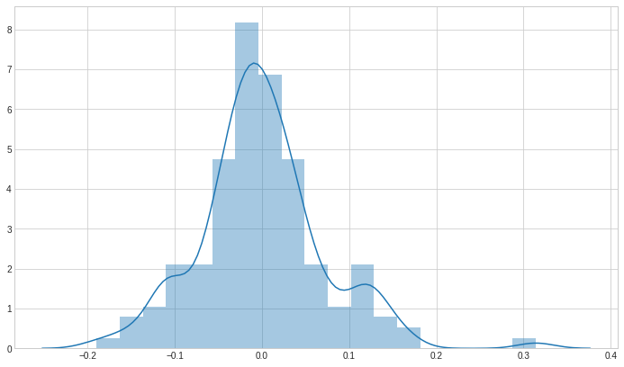

```python
y_train_predict = lr.predict(X_train_model)
residuals = y_train - y_train_predict

plt.figure(figsize=(12,7))
sns.distplot(residuals)
```

### Making Predictions on the Test Set:

```python
df_test.head()
```

|  | car_ID | symboling | fueltype | aspiration | doornumber | enginelocation | wheelbase | carlength | carwidth | carheight | ... | ohcf | ohcv | rotor | 2bbl | 4bbl | idi | mfi | mpfi | spdi | spfi |
| --- | --- | --- | --- | --- | --- | --- | --- | --- | --- | --- | --- | --- | --- | --- | --- | --- | --- | --- | --- | --- | --- |
| 87 | 88 | 4 | 0 | 1 | 0 | 0 | 96.3 | 172.4 | 65.4 | 51.6 | ... | 0 | 0 | 0 | 0 | 0 | 0 | 0 | 0 | 1 | 0 |
| 47 | 48 | 3 | 0 | 0 | 0 | 0 | 113.0 | 199.6 | 69.6 | 52.8 | ... | 0 | 0 | 0 | 0 | 0 | 0 | 0 | 1 | 0 | 0 |
| 188 | 189 | 5 | 0 | 0 | 0 | 0 | 97.3 | 171.7 | 65.5 | 55.7 | ... | 0 | 0 | 0 | 0 | 0 | 0 | 0 | 1 | 0 | 0 |
| 145 | 146 | 3 | 0 | 1 | 0 | 0 | 97.0 | 172.0 | 65.4 | 54.3 | ... | 1 | 0 | 0 | 0 | 0 | 0 | 0 | 1 | 0 | 0 |
| 181 | 182 | 2 | 0 | 0 | 0 | 0 | 104.5 | 187.8 | 66.5 | 54.1 | ... | 0 | 0 | 0 | 0 | 0 | 0 | 0 | 1 | 0 | 0 |

5 rows × 42 columns

```python
df_test.columns
```

```
Index(['car_ID', 'symboling', 'fueltype', 'aspiration', 'doornumber',
       'enginelocation', 'wheelbase', 'carlength', 'carwidth', 'carheight',
       'curbweight', 'cylindernumber', 'enginesize', 'boreratio', 'stroke',
       'compressionratio', 'horsepower', 'peakrpm', 'citympg', 'highwaympg',
       'price', 'Company_Name', 'Model_Name', 'hardtop', 'hatchback', 'sedan',
       'wagon', 'fwd', 'rwd', 'dohcv', 'l', 'ohc', 'ohcf', 'ohcv', 'rotor',
       '2bbl', '4bbl', 'idi', 'mfi', 'mpfi', 'spdi', 'spfi'],
      dtype='object')
```

#### Scaling the numerical variables:

To be noted that the test set will only be **transformed** using the scaler() object that was defined for the the training dataset.

```python
# Getting a list of all numerical variables:

num_vars = ['wheelbase',
'carlength',
'carwidth',
'carheight',
'curbweight',
'enginesize',
'boreratio',
'stroke',
'compressionratio',
'horsepower',
'peakrpm',
'citympg',
'highwaympg',
'price']

# Transforming the test variables with the scaler() function defined earlier.
df_test[num_vars] = scaler.transform(df_test[num_vars])
df_test[num_vars].describe()
```

|  | wheelbase | carlength | carwidth | carheight | curbweight | enginesize | boreratio | stroke | compressionratio | horsepower | peakrpm | citympg | highwaympg | price |
| --- | --- | --- | --- | --- | --- | --- | --- | --- | --- | --- | --- | --- | --- | --- |
| count | 62.000000 | 62.000000 | 62.000000 | 62.000000 | 62.000000 | 62.000000 | 62.000000 | 62.000000 | 62.000000 | 62.000000 | 62.000000 | 62.000000 | 62.000000 | 62.000000 |
| mean | 0.366501 | 0.503274 | 0.501792 | 0.507392 | 0.437868 | 0.264881 | 0.572120 | 0.579724 | 0.194657 | 0.290926 | 0.561901 | 0.320341 | 0.364601 | 0.221118 |
| std | 0.177754 | 0.186513 | 0.197073 | 0.199733 | 0.209631 | 0.152592 | 0.192228 | 0.146549 | 0.248893 | 0.204878 | 0.262545 | 0.165503 | 0.169534 | 0.210306 |
| min | 0.084548 | 0.132836 | 0.282051 | 0.158333 | 0.149728 | 0.109434 | 0.264286 | 0.057143 | 0.000000 | 0.018692 | 0.000000 | 0.055556 | 0.052632 | 0.001912 |
| 25% | 0.230321 | 0.377985 | 0.333333 | 0.350000 | 0.287529 | 0.139623 | 0.435714 | 0.496429 | 0.093750 | 0.106308 | 0.351351 | 0.166667 | 0.236842 | 0.083369 |
| 50% | 0.303207 | 0.473134 | 0.452991 | 0.533333 | 0.401474 | 0.203774 | 0.521429 | 0.595238 | 0.125000 | 0.252336 | 0.567568 | 0.305556 | 0.355263 | 0.128519 |
| 75% | 0.473761 | 0.671642 | 0.583333 | 0.641667 | 0.606575 | 0.354717 | 0.753571 | 0.633333 | 0.150000 | 0.389019 | 0.729730 | 0.409722 | 0.447368 | 0.282856 |
| max | 0.845481 | 0.917910 | 1.025641 | 0.941667 | 1.000000 | 0.743396 | 1.000000 | 1.000000 | 1.000000 | 1.121495 | 1.324324 | 0.694444 | 0.815789 | 0.792165 |

```python
# Instantiating the X_test and y_test variables:
y_test = df_test.pop('price')
X_test = df_test
```

```python
print(X_test.shape)
print(y_test.shape)
```

```
(62, 41)
(62,)
```

We need to modify **X_test** to only contain those columns which are requierd in the model.

```python
# Columns in the model:
X_train.columns
```

```
Index(['aspiration', 'enginelocation', 'enginesize', 'Company_Name',
       'hatchback', 'ohcv', 'rotor'],
      dtype='object')
```

```python
# List of columns to retain in the test set:
cols_to_retain = ['aspiration', 'enginelocation', 'enginesize', 'Company_Name','hatchback', 'ohcv', 'rotor']
X_test = X_test[cols_to_retain]
```

```python
print(X_test.shape)
print(X_train.shape)
```

```
(62, 7)
(143, 7)
```

#### Predicting the values:

```python
# Adding the constant, to avoid the regression line passing through 0 by default.
X_test_model = sm.add_constant(X_test)
```

```python
# predicting the values of price on the test set.
y_test_predict = lr.predict(X_test_model)
```

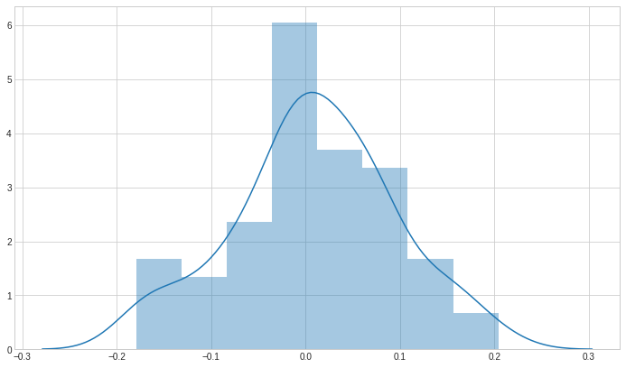

```python
# Residual analysis on the test set:
residual_test = y_test - y_test_predict

plt.figure(figsize=(12,7))
sns.distplot(residual_test)
```

The distribution looks normal and the mean is centered around 0.

### Calculating the R-squared on the test set:

```python
from sklearn.metrics import r2_score
```

```python
r2_test = r2_score(y_true = y_test, y_pred = y_test_predict)
r2_test
```

```
0.8288830765398404
```

```python
# R-squared on the training set:
r2_train = r2_score(y_true = y_train, y_pred = y_train_predict)
r2_train
```

```
0.8610981205412662
```

Since the R2 of test is within 5% of the training set, therefore this is a pretty good model.

where:  
b1 = aspiration  
b2 = enginelocation  
b3 = enginesize  
b4 = Company_Name  
b5 = hatchback  
b6 = ohcv  
b7 = rotor

## Automated Variable Selection using RFE

We'll use the cars dataframe that was instantiated above since it has been cleaned and brought in shape for analysis.

```python
cars.head()
```

|  | car_ID | symboling | fueltype | aspiration | doornumber | enginelocation | wheelbase | carlength | carwidth | carheight | ... | ohcf | ohcv | rotor | 2bbl | 4bbl | idi | mfi | mpfi | spdi | spfi |
| --- | --- | --- | --- | --- | --- | --- | --- | --- | --- | --- | --- | --- | --- | --- | --- | --- | --- | --- | --- | --- | --- |
| 0 | 1 | 6 | 0 | 0 | 1 | 0 | 88.6 | 168.8 | 64.1 | 48.8 | ... | 0 | 0 | 0 | 0 | 0 | 0 | 0 | 1 | 0 | 0 |
| 1 | 2 | 6 | 0 | 0 | 1 | 0 | 88.6 | 168.8 | 64.1 | 48.8 | ... | 0 | 0 | 0 | 0 | 0 | 0 | 0 | 1 | 0 | 0 |
| 2 | 3 | 4 | 0 | 0 | 1 | 0 | 94.5 | 171.2 | 65.5 | 52.4 | ... | 0 | 1 | 0 | 0 | 0 | 0 | 0 | 1 | 0 | 0 |
| 3 | 4 | 5 | 0 | 0 | 0 | 0 | 99.8 | 176.6 | 66.2 | 54.3 | ... | 0 | 0 | 0 | 0 | 0 | 0 | 0 | 1 | 0 | 0 |
| 4 | 5 | 5 | 0 | 0 | 0 | 0 | 99.4 | 176.6 | 66.4 | 54.3 | ... | 0 | 0 | 0 | 0 | 0 | 0 | 0 | 1 | 0 | 0 |

5 rows × 42 columns

#### Splitting the Data into Training and Test sets:

```python
df_train_rfe, df_test_rfe = train_test_split(cars, train_size=0.70, random_state=33)
print(df_train_rfe.shape)
print('\n')
print(df_test_rfe.shape)
```

```
(143, 42)


(62, 42)
```

#### Rescaling the numerical variables:

```python
# Instantiating the scaler variable:
scaler_rfe = MinMaxScaler()
```

```python
# Getting a list of numerical variables:
num_vars = ['wheelbase',
'carlength',
'carwidth',
'carheight',
'curbweight',
'enginesize',
'boreratio',
'stroke',
'compressionratio',
'horsepower',
'peakrpm',
'citympg',
'highwaympg',
'price']
```

```python
# Scaling the variables:
df_train_rfe[num_vars] = scaler_rfe.fit_transform(df_train_rfe[num_vars])
df_train_rfe.head()
```

|  | car_ID | symboling | fueltype | aspiration | doornumber | enginelocation | wheelbase | carlength | carwidth | carheight | ... | ohcf | ohcv | rotor | 2bbl | 4bbl | idi | mfi | mpfi | spdi | spfi |
| --- | --- | --- | --- | --- | --- | --- | --- | --- | --- | --- | --- | --- | --- | --- | --- | --- | --- | --- | --- | --- | --- |
| 22 | 23 | 4 | 0 | 0 | 1 | 0 | 0.206997 | 0.241791 | 0.299145 | 0.250000 | ... | 0 | 0 | 0 | 1 | 0 | 0 | 0 | 0 | 0 | 0 |
| 136 | 137 | 6 | 0 | 1 | 1 | 0 | 0.364431 | 0.679104 | 0.529915 | 0.691667 | ... | 0 | 0 | 0 | 0 | 0 | 0 | 0 | 1 | 0 | 0 |
| 148 | 149 | 3 | 0 | 0 | 0 | 0 | 0.300292 | 0.485075 | 0.435897 | 0.591667 | ... | 1 | 0 | 0 | 1 | 0 | 0 | 0 | 0 | 0 | 0 |
| 81 | 82 | 6 | 0 | 0 | 1 | 0 | 0.282799 | 0.476119 | 0.435897 | 0.133333 | ... | 0 | 0 | 0 | 1 | 0 | 0 | 0 | 0 | 0 | 0 |
| 101 | 102 | 3 | 0 | 0 | 0 | 0 | 0.402332 | 0.605970 | 0.529915 | 0.608333 | ... | 0 | 1 | 0 | 0 | 0 | 0 | 0 | 1 | 0 | 0 |

5 rows × 42 columns

```python
df_train_rfe[num_vars].describe()
```

|  | wheelbase | carlength | carwidth | carheight | curbweight | enginesize | boreratio | stroke | compressionratio | horsepower | peakrpm | citympg | highwaympg | price |
| --- | --- | --- | --- | --- | --- | --- | --- | --- | --- | --- | --- | --- | --- | --- |
| count | 143.000000 | 143.000000 | 143.000000 | 143.000000 | 143.000000 | 143.000000 | 143.000000 | 143.000000 | 143.000000 | 143.000000 | 143.000000 | 143.000000 | 143.000000 | 143.000000 |
| mean | 0.349181 | 0.486797 | 0.469548 | 0.487821 | 0.403804 | 0.241694 | 0.560639 | 0.557875 | 0.197168 | 0.249788 | 0.512002 | 0.347708 | 0.398417 | 0.194485 |
| std | 0.174971 | 0.183535 | 0.176904 | 0.205704 | 0.198423 | 0.159089 | 0.194561 | 0.150551 | 0.248847 | 0.174664 | 0.255210 | 0.188278 | 0.185703 | 0.193105 |
| min | 0.000000 | 0.000000 | 0.000000 | 0.000000 | 0.000000 | 0.000000 | 0.000000 | 0.000000 | 0.000000 | 0.000000 | 0.000000 | 0.000000 | 0.000000 | 0.000000 |
| 25% | 0.230321 | 0.379851 | 0.320513 | 0.350000 | 0.251552 | 0.135849 | 0.435714 | 0.495238 | 0.100000 | 0.102804 | 0.351351 | 0.180556 | 0.236842 | 0.062832 |
| 50% | 0.300292 | 0.479104 | 0.435897 | 0.508333 | 0.357642 | 0.222642 | 0.564286 | 0.571429 | 0.125000 | 0.205607 | 0.513514 | 0.333333 | 0.394737 | 0.128519 |
| 75% | 0.425656 | 0.570896 | 0.529915 | 0.641667 | 0.522110 | 0.290566 | 0.742857 | 0.638095 | 0.150000 | 0.315421 | 0.729730 | 0.500000 | 0.552632 | 0.282558 |
| max | 1.000000 | 1.000000 | 1.000000 | 1.000000 | 1.000000 | 1.000000 | 1.000000 | 1.000000 | 1.000000 | 1.000000 | 1.000000 | 1.000000 | 1.000000 | 1.000000 |

#### Building the model:

```python
y_train_rfe = df_train_rfe.pop('price')
X_train_rfe = df_train_rfe
```

```python
# Removing unwanted variables:
X_train_rfe.pop('Model_Name')
X_train_rfe.pop('car_ID')
```

[output not shown]

[output cut: 47 more lines]

```python
from sklearn.linear_model import LinearRegression
from sklearn.feature_selection import RFE
```

```python
# Instantiating the model:
lr_rfe = LinearRegression()

# Fitting the model:
lr_rfe.fit(X_train_rfe, y_train_rfe)
```

```
LinearRegression(copy_X=True, fit_intercept=True, n_jobs=1, normalize=False)
```

```python
# Taking the top 10 variables:
rfe = RFE(lr_rfe, 10)

# Fitting the model:
rfe = rfe.fit(X_train_rfe, y_train_rfe)
```

```python
rfe_ranking = pd.DataFrame({'Feature':X_train_rfe.columns, 'Feature_selected':rfe.support_,
                           'Ranking':rfe.ranking_})
rfe_ranking = rfe_ranking.sort_values('Ranking', ascending=True)
rfe_ranking
```

|  | Feature | Feature_selected | Ranking |
| --- | --- | --- | --- |
| 16 | peakrpm | True | 1 |
| 34 | idi | True | 1 |
| 31 | rotor | True | 1 |
| 13 | stroke | True | 1 |
| 11 | enginesize | True | 1 |
| 9 | curbweight | True | 1 |
| 7 | carwidth | True | 1 |
| 14 | compressionratio | True | 1 |
| 1 | fueltype | True | 1 |
| 4 | enginelocation | True | 1 |
| 18 | highwaympg | False | 2 |
| 30 | ohcv | False | 3 |
| 15 | horsepower | False | 4 |
| 37 | spdi | False | 5 |
| 6 | carlength | False | 6 |
| 5 | wheelbase | False | 7 |
| 23 | wagon | False | 8 |
| 21 | hatchback | False | 9 |
| 22 | sedan | False | 10 |
| 28 | ohc | False | 11 |
| 20 | hardtop | False | 12 |
| 10 | cylindernumber | False | 13 |
| 8 | carheight | False | 14 |
| 12 | boreratio | False | 15 |
| 29 | ohcf | False | 16 |
| 25 | rwd | False | 17 |
| 17 | citympg | False | 18 |
| 2 | aspiration | False | 19 |
| 36 | mpfi | False | 20 |
| 38 | spfi | False | 21 |
| 33 | 4bbl | False | 22 |
| 27 | l | False | 23 |
| 3 | doornumber | False | 24 |
| 0 | symboling | False | 25 |
| 24 | fwd | False | 26 |
| 32 | 2bbl | False | 27 |
| 19 | Company_Name | False | 28 |
| 26 | dohcv | False | 29 |
| 35 | mfi | False | 30 |

```python
# Taking all the columns which were selected by RFE:
cols_to_retain = X_train_rfe.columns[rfe.support_]
cols_to_retain
```

```
Index(['fueltype', 'enginelocation', 'carwidth', 'curbweight', 'enginesize',
       'stroke', 'compressionratio', 'peakrpm', 'rotor', 'idi'],
      dtype='object')
```

#### Building the model using statsmodels:

```python
# Filtering the significant variables according to RFE:
X_train_rfe = X_train_rfe[cols_to_retain]

# Adding the constant:
X_train_rfe_model = sm.add_constant(X_train_rfe)
```

```python
# Fitting the model:
lr_rfe_sm = sm.OLS(y_train_rfe, X_train_rfe_model).fit()

# Summary:
lr_rfe_sm.summary()
```

OLS Regression Results

| Dep. Variable: | price | R-squared: | 0.870 |
| --- | --- | --- | --- |
| Model: | OLS | Adj. R-squared: | 0.861 |
| Method: | Least Squares | F-statistic: | 98.72 |
| Date: | Sun, 14 Jul 2019 | Prob (F-statistic): | 1.90e-54 |
| Time: | 07:09:32 | Log-Likelihood: | 178.52 |
| No. Observations: | 143 | AIC: | -337.0 |
| Df Residuals: | 133 | BIC: | -307.4 |
| Df Model: | 9 |  |  |
| Covariance Type: | nonrobust |  |  |

|  | coef | std err | t | P>\|t\| | [0.025 | 0.975] |
| --- | --- | --- | --- | --- | --- | --- |
| const | -0.1011 | 0.044 | -2.286 | 0.024 | -0.189 | -0.014 |
| fueltype | 0.1336 | 0.076 | 1.756 | 0.081 | -0.017 | 0.284 |
| enginelocation | 0.2416 | 0.059 | 4.124 | 0.000 | 0.126 | 0.357 |
| carwidth | 0.1457 | 0.071 | 2.041 | 0.043 | 0.005 | 0.287 |
| curbweight | 0.1402 | 0.090 | 1.558 | 0.122 | -0.038 | 0.318 |
| enginesize | 0.8386 | 0.089 | 9.380 | 0.000 | 0.662 | 1.015 |
| stroke | -0.1280 | 0.047 | -2.715 | 0.008 | -0.221 | -0.035 |
| compressionratio | -0.2428 | 0.172 | -1.414 | 0.160 | -0.582 | 0.097 |
| peakrpm | 0.1043 | 0.032 | 3.286 | 0.001 | 0.042 | 0.167 |
| rotor | 0.1477 | 0.042 | 3.541 | 0.001 | 0.065 | 0.230 |
| idi | 0.1336 | 0.076 | 1.756 | 0.081 | -0.017 | 0.284 |

| Omnibus: | 36.668 | Durbin-Watson: | 2.073 |
| --- | --- | --- | --- |
| Prob(Omnibus): | 0.000 | Jarque-Bera (JB): | 131.445 |
| Skew: | 0.876 | Prob(JB): | 2.87e-29 |
| Kurtosis: | 7.358 | Cond. No. | 1.26e+17 |

Warnings:  
[1] Standard Errors assume that the covariance matrix of the errors is correctly specified.  
[2] The smallest eigenvalue is 1.9e-32. This might indicate that there are  
strong multicollinearity problems or that the design matrix is singular.

We can see that the p-values of multiple variables are high, also there seems to be a problem of multicollinearity. Calcualating the VIF:

```python
vif = pd.DataFrame()
vif['Features'] = X_train_rfe.columns
vif['VIF'] = [variance_inflation_factor(X_train_rfe.values, i) for i in range(X_train_rfe.shape[1])]
vif['VIF'] = round(vif['VIF'], 2)
vif = vif.sort_values('VIF', ascending = False)
vif
```

|  | Features | VIF |
| --- | --- | --- |
| 0 | fueltype | inf |
| 9 | idi | inf |
| 6 | compressionratio | 41.090000 |
| 3 | curbweight | 40.590000 |
| 2 | carwidth | 34.410000 |
| 4 | enginesize | 16.490000 |
| 5 | stroke | 11.480000 |
| 7 | peakrpm | 8.840000 |
| 1 | enginelocation | 1.320000 |
| 8 | rotor | 1.250000 |

```python
# Removing idi:
X_train_rfe.pop('idi')
X_train_rfe_model = sm.add_constant(X_train_rfe)
lr_rfe_sm = sm.OLS(y_train_rfe, X_train_rfe_model).fit()
lr_rfe_sm.summary()
```

OLS Regression Results

| Dep. Variable: | price | R-squared: | 0.870 |
| --- | --- | --- | --- |
| Model: | OLS | Adj. R-squared: | 0.861 |
| Method: | Least Squares | F-statistic: | 98.72 |
| Date: | Sun, 14 Jul 2019 | Prob (F-statistic): | 1.90e-54 |
| Time: | 07:09:33 | Log-Likelihood: | 178.52 |
| No. Observations: | 143 | AIC: | -337.0 |
| Df Residuals: | 133 | BIC: | -307.4 |
| Df Model: | 9 |  |  |
| Covariance Type: | nonrobust |  |  |

|  | coef | std err | t | P>\|t\| | [0.025 | 0.975] |
| --- | --- | --- | --- | --- | --- | --- |
| const | -0.1011 | 0.044 | -2.286 | 0.024 | -0.189 | -0.014 |
| fueltype | 0.2673 | 0.152 | 1.756 | 0.081 | -0.034 | 0.568 |
| enginelocation | 0.2416 | 0.059 | 4.124 | 0.000 | 0.126 | 0.357 |
| carwidth | 0.1457 | 0.071 | 2.041 | 0.043 | 0.005 | 0.287 |
| curbweight | 0.1402 | 0.090 | 1.558 | 0.122 | -0.038 | 0.318 |
| enginesize | 0.8386 | 0.089 | 9.380 | 0.000 | 0.662 | 1.015 |
| stroke | -0.1280 | 0.047 | -2.715 | 0.008 | -0.221 | -0.035 |
| compressionratio | -0.2428 | 0.172 | -1.414 | 0.160 | -0.582 | 0.097 |
| peakrpm | 0.1043 | 0.032 | 3.286 | 0.001 | 0.042 | 0.167 |
| rotor | 0.1477 | 0.042 | 3.541 | 0.001 | 0.065 | 0.230 |

| Omnibus: | 36.668 | Durbin-Watson: | 2.073 |
| --- | --- | --- | --- |
| Prob(Omnibus): | 0.000 | Jarque-Bera (JB): | 131.445 |
| Skew: | 0.876 | Prob(JB): | 2.87e-29 |
| Kurtosis: | 7.358 | Cond. No. | 57.5 |

Warnings:  
[1] Standard Errors assume that the covariance matrix of the errors is correctly specified.

```python
vif = pd.DataFrame()
vif['Features'] = X_train_rfe.columns
vif['VIF'] = [variance_inflation_factor(X_train_rfe.values, i) for i in range(X_train_rfe.shape[1])]
vif['VIF'] = round(vif['VIF'], 2)
vif = vif.sort_values('VIF', ascending = False)
vif
```

|  | Features | VIF |
| --- | --- | --- |
| 6 | compressionratio | 41.09 |
| 3 | curbweight | 40.59 |
| 2 | carwidth | 34.41 |
| 0 | fueltype | 32.53 |
| 4 | enginesize | 16.49 |
| 5 | stroke | 11.48 |
| 7 | peakrpm | 8.84 |
| 1 | enginelocation | 1.32 |
| 8 | rotor | 1.25 |

The R2 remains the same.  
Removing **curbweight**

```python
X_train_rfe.pop('curbweight')
X_train_rfe_model = sm.add_constant(X_train_rfe)
lr_rfe_sm = sm.OLS(y_train_rfe, X_train_rfe_model).fit()
lr_rfe_sm.summary()
```

OLS Regression Results

| Dep. Variable: | price | R-squared: | 0.867 |
| --- | --- | --- | --- |
| Model: | OLS | Adj. R-squared: | 0.860 |
| Method: | Least Squares | F-statistic: | 109.6 |
| Date: | Sun, 14 Jul 2019 | Prob (F-statistic): | 5.79e-55 |
| Time: | 07:09:33 | Log-Likelihood: | 177.23 |
| No. Observations: | 143 | AIC: | -336.5 |
| Df Residuals: | 134 | BIC: | -309.8 |
| Df Model: | 8 |  |  |
| Covariance Type: | nonrobust |  |  |

|  | coef | std err | t | P>\|t\| | [0.025 | 0.975] |
| --- | --- | --- | --- | --- | --- | --- |
| const | -0.0791 | 0.042 | -1.878 | 0.063 | -0.162 | 0.004 |
| fueltype | 0.3720 | 0.137 | 2.709 | 0.008 | 0.100 | 0.644 |
| enginelocation | 0.2340 | 0.059 | 3.986 | 0.000 | 0.118 | 0.350 |
| carwidth | 0.2121 | 0.058 | 3.684 | 0.000 | 0.098 | 0.326 |
| enginesize | 0.9341 | 0.065 | 14.272 | 0.000 | 0.805 | 1.064 |
| stroke | -0.1475 | 0.046 | -3.229 | 0.002 | -0.238 | -0.057 |
| compressionratio | -0.3550 | 0.157 | -2.267 | 0.025 | -0.665 | -0.045 |
| peakrpm | 0.1099 | 0.032 | 3.467 | 0.001 | 0.047 | 0.173 |
| rotor | 0.1634 | 0.041 | 4.017 | 0.000 | 0.083 | 0.244 |

| Omnibus: | 37.338 | Durbin-Watson: | 2.118 |
| --- | --- | --- | --- |
| Prob(Omnibus): | 0.000 | Jarque-Bera (JB): | 118.618 |
| Skew: | 0.943 | Prob(JB): | 1.75e-26 |
| Kurtosis: | 7.044 | Cond. No. | 48.4 |

Warnings:  
[1] Standard Errors assume that the covariance matrix of the errors is correctly specified.

```python
vif = pd.DataFrame()
vif['Features'] = X_train_rfe.columns
vif['VIF'] = [variance_inflation_factor(X_train_rfe.values, i) for i in range(X_train_rfe.shape[1])]
vif['VIF'] = round(vif['VIF'], 2)
vif = vif.sort_values('VIF', ascending = False)
vif
```

|  | Features | VIF |
| --- | --- | --- |
| 5 | compressionratio | 37.62 |
| 0 | fueltype | 29.14 |
| 2 | carwidth | 17.85 |
| 4 | stroke | 11.42 |
| 3 | enginesize | 9.54 |
| 6 | peakrpm | 8.56 |
| 1 | enginelocation | 1.31 |
| 7 | rotor | 1.21 |

From the above model summary and VIF table, we can see that the p-values of all the variables are below 0.05 which means that all the variables are significant.  
However, the VIF of some variables is pretty high. Let us remove them one by one.  
Remvoving **compressionratio**

```python
X_train_rfe.pop('compressionratio')
X_train_rfe_model = sm.add_constant(X_train_rfe)
lr_rfe_sm = sm.OLS(y_train_rfe, X_train_rfe_model).fit()
lr_rfe_sm.summary()
```

OLS Regression Results

| Dep. Variable: | price | R-squared: | 0.862 |
| --- | --- | --- | --- |
| Model: | OLS | Adj. R-squared: | 0.855 |
| Method: | Least Squares | F-statistic: | 120.8 |
| Date: | Sun, 14 Jul 2019 | Prob (F-statistic): | 6.19e-55 |
| Time: | 07:09:33 | Log-Likelihood: | 174.54 |
| No. Observations: | 143 | AIC: | -333.1 |
| Df Residuals: | 135 | BIC: | -309.4 |
| Df Model: | 7 |  |  |
| Covariance Type: | nonrobust |  |  |

|  | coef | std err | t | P>\|t\| | [0.025 | 0.975] |
| --- | --- | --- | --- | --- | --- | --- |
| const | -0.1425 | 0.032 | -4.451 | 0.000 | -0.206 | -0.079 |
| fueltype | 0.0661 | 0.026 | 2.549 | 0.012 | 0.015 | 0.117 |
| enginelocation | 0.2369 | 0.060 | 3.976 | 0.000 | 0.119 | 0.355 |
| carwidth | 0.2488 | 0.056 | 4.437 | 0.000 | 0.138 | 0.360 |
| enginesize | 0.9140 | 0.066 | 13.884 | 0.000 | 0.784 | 1.044 |
| stroke | -0.1155 | 0.044 | -2.619 | 0.010 | -0.203 | -0.028 |
| peakrpm | 0.0969 | 0.032 | 3.061 | 0.003 | 0.034 | 0.159 |
| rotor | 0.1524 | 0.041 | 3.717 | 0.000 | 0.071 | 0.234 |

| Omnibus: | 39.629 | Durbin-Watson: | 2.075 |
| --- | --- | --- | --- |
| Prob(Omnibus): | 0.000 | Jarque-Bera (JB): | 164.652 |
| Skew: | 0.902 | Prob(JB): | 1.76e-36 |
| Kurtosis: | 7.938 | Cond. No. | 19.8 |

Warnings:  
[1] Standard Errors assume that the covariance matrix of the errors is correctly specified.

```python
vif = pd.DataFrame()
vif['Features'] = X_train_rfe.columns
vif['VIF'] = [variance_inflation_factor(X_train_rfe.values, i) for i in range(X_train_rfe.shape[1])]
vif['VIF'] = round(vif['VIF'], 2)
vif = vif.sort_values('VIF', ascending = False)
vif
```

|  | Features | VIF |
| --- | --- | --- |
| 2 | carwidth | 17.82 |
| 4 | stroke | 11.00 |
| 3 | enginesize | 9.52 |
| 5 | peakrpm | 6.88 |
| 0 | fueltype | 1.75 |
| 1 | enginelocation | 1.31 |
| 6 | rotor | 1.21 |

Removing **carwidth**

```python
X_train_rfe.pop('carwidth')
X_train_rfe_model = sm.add_constant(X_train_rfe)
lr_rfe_sm = sm.OLS(y_train_rfe, X_train_rfe_model).fit()
lr_rfe_sm.summary()
```

OLS Regression Results

| Dep. Variable: | price | R-squared: | 0.842 |
| --- | --- | --- | --- |
| Model: | OLS | Adj. R-squared: | 0.835 |
| Method: | Least Squares | F-statistic: | 121.0 |
| Date: | Sun, 14 Jul 2019 | Prob (F-statistic): | 4.98e-52 |
| Time: | 07:09:33 | Log-Likelihood: | 164.80 |
| No. Observations: | 143 | AIC: | -315.6 |
| Df Residuals: | 136 | BIC: | -294.9 |
| Df Model: | 6 |  |  |
| Covariance Type: | nonrobust |  |  |

|  | coef | std err | t | P>\|t\| | [0.025 | 0.975] |
| --- | --- | --- | --- | --- | --- | --- |
| const | -0.0876 | 0.031 | -2.781 | 0.006 | -0.150 | -0.025 |
| fueltype | 0.1011 | 0.026 | 3.833 | 0.000 | 0.049 | 0.153 |
| enginelocation | 0.1594 | 0.061 | 2.624 | 0.010 | 0.039 | 0.280 |
| enginesize | 1.1338 | 0.046 | 24.503 | 0.000 | 1.042 | 1.225 |
| stroke | -0.1190 | 0.047 | -2.530 | 0.013 | -0.212 | -0.026 |
| peakrpm | 0.1113 | 0.034 | 3.314 | 0.001 | 0.045 | 0.178 |
| rotor | 0.1904 | 0.043 | 4.452 | 0.000 | 0.106 | 0.275 |

| Omnibus: | 21.283 | Durbin-Watson: | 2.033 |
| --- | --- | --- | --- |
| Prob(Omnibus): | 0.000 | Jarque-Bera (JB): | 81.012 |
| Skew: | 0.365 | Prob(JB): | 2.56e-18 |
| Kurtosis: | 6.614 | Cond. No. | 13.3 |

Warnings:  
[1] Standard Errors assume that the covariance matrix of the errors is correctly specified.

```python
vif = pd.DataFrame()
vif['Features'] = X_train_rfe.columns
vif['VIF'] = [variance_inflation_factor(X_train_rfe.values, i) for i in range(X_train_rfe.shape[1])]
vif['VIF'] = round(vif['VIF'], 2)
vif = vif.sort_values('VIF', ascending = False)
vif
```

|  | Features | VIF |
| --- | --- | --- |
| 3 | stroke | 10.07 |
| 4 | peakrpm | 6.09 |
| 2 | enginesize | 3.69 |
| 0 | fueltype | 1.55 |
| 1 | enginelocation | 1.19 |
| 5 | rotor | 1.18 |

Removing **stroke** since its p-value has increased and it also has a high VIF:

```python
X_train_rfe.pop('stroke')
X_train_rfe_model = sm.add_constant(X_train_rfe)
lr_rfe_sm = sm.OLS(y_train_rfe, X_train_rfe_model).fit()
lr_rfe_sm.summary()
```

OLS Regression Results

| Dep. Variable: | price | R-squared: | 0.835 |
| --- | --- | --- | --- |
| Model: | OLS | Adj. R-squared: | 0.829 |
| Method: | Least Squares | F-statistic: | 138.5 |
| Date: | Sun, 14 Jul 2019 | Prob (F-statistic): | 9.01e-52 |
| Time: | 07:09:33 | Log-Likelihood: | 161.51 |
| No. Observations: | 143 | AIC: | -311.0 |
| Df Residuals: | 137 | BIC: | -293.3 |
| Df Model: | 5 |  |  |
| Covariance Type: | nonrobust |  |  |

|  | coef | std err | t | P>\|t\| | [0.025 | 0.975] |
| --- | --- | --- | --- | --- | --- | --- |
| const | -0.1388 | 0.025 | -5.650 | 0.000 | -0.187 | -0.090 |
| fueltype | 0.0816 | 0.026 | 3.174 | 0.002 | 0.031 | 0.132 |
| enginelocation | 0.1903 | 0.061 | 3.137 | 0.002 | 0.070 | 0.310 |
| enginesize | 1.1069 | 0.046 | 24.108 | 0.000 | 1.016 | 1.198 |
| peakrpm | 0.0973 | 0.034 | 2.882 | 0.005 | 0.031 | 0.164 |
| rotor | 0.1896 | 0.044 | 4.349 | 0.000 | 0.103 | 0.276 |

| Omnibus: | 20.209 | Durbin-Watson: | 2.044 |
| --- | --- | --- | --- |
| Prob(Omnibus): | 0.000 | Jarque-Bera (JB): | 48.279 |
| Skew: | 0.541 | Prob(JB): | 3.28e-11 |
| Kurtosis: | 5.633 | Cond. No. | 11.5 |

Warnings:  
[1] Standard Errors assume that the covariance matrix of the errors is correctly specified.

```python
vif = pd.DataFrame()
vif['Features'] = X_train_rfe.columns
vif['VIF'] = [variance_inflation_factor(X_train_rfe.values, i) for i in range(X_train_rfe.shape[1])]
vif['VIF'] = round(vif['VIF'], 2)
vif = vif.sort_values('VIF', ascending = False)
vif
```

|  | Features | VIF |
| --- | --- | --- |
| 2 | enginesize | 2.27 |
| 3 | peakrpm | 2.27 |
| 4 | rotor | 1.17 |
| 0 | fueltype | 1.14 |
| 1 | enginelocation | 1.05 |

This seems to be a good model with an R2 of 0.835 and all the variables are significant with no multicollinearity.

The regression equation will be:  
**price = 0.0816(b1) + 0.1903(b2)+ 1.1069(b3) + 0.0973(b4) + 0.1896(b5) - 0.1388**  
where:  
b1 = fueltype  
b2 = enginelocation  
b3 = enginesize  
b4 = peakrpm  
b5 = rotor

#### Residual Analysis and Prediction on the Test set:

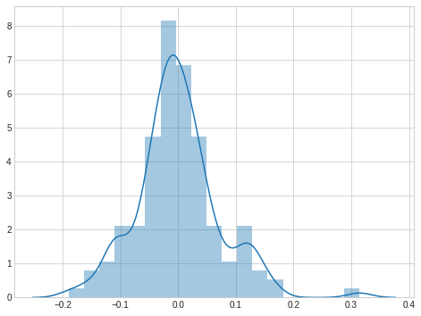

```python
y_train_rfe_predict = lr_rfe_sm.predict(X_train_rfe_model)
residuals_rfe = y_train_rfe_predict - y_train_rfe

plt.figure(figsize = (8,6))
sns.distplot(residuals)
```

```python
df_test_rfe.head()
```

|  | car_ID | symboling | fueltype | aspiration | doornumber | enginelocation | wheelbase | carlength | carwidth | carheight | ... | ohcf | ohcv | rotor | 2bbl | 4bbl | idi | mfi | mpfi | spdi | spfi |
| --- | --- | --- | --- | --- | --- | --- | --- | --- | --- | --- | --- | --- | --- | --- | --- | --- | --- | --- | --- | --- | --- |
| 87 | 88 | 4 | 0 | 1 | 0 | 0 | 96.3 | 172.4 | 65.4 | 51.6 | ... | 0 | 0 | 0 | 0 | 0 | 0 | 0 | 0 | 1 | 0 |
| 47 | 48 | 3 | 0 | 0 | 0 | 0 | 113.0 | 199.6 | 69.6 | 52.8 | ... | 0 | 0 | 0 | 0 | 0 | 0 | 0 | 1 | 0 | 0 |
| 188 | 189 | 5 | 0 | 0 | 0 | 0 | 97.3 | 171.7 | 65.5 | 55.7 | ... | 0 | 0 | 0 | 0 | 0 | 0 | 0 | 1 | 0 | 0 |
| 145 | 146 | 3 | 0 | 1 | 0 | 0 | 97.0 | 172.0 | 65.4 | 54.3 | ... | 1 | 0 | 0 | 0 | 0 | 0 | 0 | 1 | 0 | 0 |
| 181 | 182 | 2 | 0 | 0 | 0 | 0 | 104.5 | 187.8 | 66.5 | 54.1 | ... | 0 | 0 | 0 | 0 | 0 | 0 | 0 | 1 | 0 | 0 |

5 rows × 42 columns

```python
# Scaling the numerical variables:
num_vars = ['wheelbase',
'carlength',
'carwidth',
'carheight',
'curbweight',
'enginesize',
'boreratio',
'stroke',
'compressionratio',
'horsepower',
'peakrpm',
'citympg',
'highwaympg',
'price']

df_test_rfe[num_vars] = scaler_rfe.transform(df_test_rfe[num_vars])
df_test_rfe[num_vars].describe()
```

|  | wheelbase | carlength | carwidth | carheight | curbweight | enginesize | boreratio | stroke | compressionratio | horsepower | peakrpm | citympg | highwaympg | price |
| --- | --- | --- | --- | --- | --- | --- | --- | --- | --- | --- | --- | --- | --- | --- |
| count | 62.000000 | 62.000000 | 62.000000 | 62.000000 | 62.000000 | 62.000000 | 62.000000 | 62.000000 | 62.000000 | 62.000000 | 62.000000 | 62.000000 | 62.000000 | 62.000000 |
| mean | 0.366501 | 0.503274 | 0.501792 | 0.507392 | 0.437868 | 0.264881 | 0.572120 | 0.579724 | 0.194657 | 0.290926 | 0.561901 | 0.320341 | 0.364601 | 0.221118 |
| std | 0.177754 | 0.186513 | 0.197073 | 0.199733 | 0.209631 | 0.152592 | 0.192228 | 0.146549 | 0.248893 | 0.204878 | 0.262545 | 0.165503 | 0.169534 | 0.210306 |
| min | 0.084548 | 0.132836 | 0.282051 | 0.158333 | 0.149728 | 0.109434 | 0.264286 | 0.057143 | 0.000000 | 0.018692 | 0.000000 | 0.055556 | 0.052632 | 0.001912 |
| 25% | 0.230321 | 0.377985 | 0.333333 | 0.350000 | 0.287529 | 0.139623 | 0.435714 | 0.496429 | 0.093750 | 0.106308 | 0.351351 | 0.166667 | 0.236842 | 0.083369 |
| 50% | 0.303207 | 0.473134 | 0.452991 | 0.533333 | 0.401474 | 0.203774 | 0.521429 | 0.595238 | 0.125000 | 0.252336 | 0.567568 | 0.305556 | 0.355263 | 0.128519 |
| 75% | 0.473761 | 0.671642 | 0.583333 | 0.641667 | 0.606575 | 0.354717 | 0.753571 | 0.633333 | 0.150000 | 0.389019 | 0.729730 | 0.409722 | 0.447368 | 0.282856 |
| max | 0.845481 | 0.917910 | 1.025641 | 0.941667 | 1.000000 | 0.743396 | 1.000000 | 1.000000 | 1.000000 | 1.121495 | 1.324324 | 0.694444 | 0.815789 | 0.792165 |

```python
# Instantiating the X and y variables:
y_test_rfe = df_test_rfe.pop('price')
X_test_rfe = df_test
print(y_test_rfe.shape)
print(X_test_rfe.shape)
```

```
(62,)
(62, 41)
```

```python
# Removing unwanted variables from X_test:
cols_to_retain = ['fueltype','enginelocation','enginesize','peakrpm','rotor']
X_test_rfe = X_test_rfe[cols_to_retain]
```

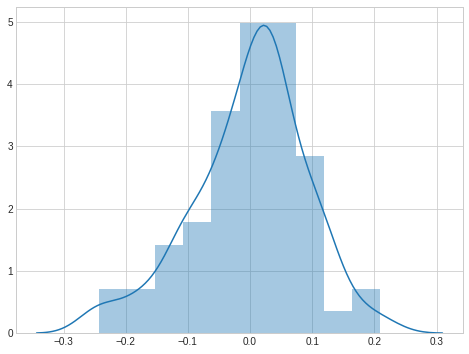

```python
X_test_rfe_model = sm.add_constant(X_test_rfe)

# Predicting values:
y_test_rfe_predict = lr_rfe_sm.predict(X_test_rfe_model)

# Residuals:
residuals_test_rfe = y_test_rfe_predict - y_test_rfe

plt.figure(figsize=(8,6))
sns.distplot(residuals_test_rfe)
```

Distribution resembles normal distribution and the mean is centred around 0 which is good.

#### Calculating the R2 value on the test set:

```python
r2_score_rfe_test = r2_score(y_true=y_test_rfe, y_pred=y_test_rfe_predict)
r2_score_rfe_test
```

```
0.8074377772763361
```

```python
r2_score_rfe_train = r2_score(y_true=y_train_rfe, y_pred=y_train_rfe_predict)
r2_score_rfe_train
```

```
0.83482797025101
```

Since the R2 of test is within 5% of the training set, therefore we can say that our model works pretty well on the test set and is able to account for 80% of the data points.

## Comparison of Manual and Automated Variable Selection:

#### Automated Variable Selection:

The regression equation will be:  
**price = 0.0816(b1) + 0.1903(b2)+ 1.1069(b3) + 0.0973(b4) + 0.1896(b5) - 0.1388**  
R2 = 0.835  
Adjusted R2 = 0.829  
where:  
b1 = fueltype  
b2 = enginelocation  
b3 = enginesize  
b4 = peakrpm  
b5 = rotor

We can see that the variables **enginesize, enginelocation and rotor** are common across the two models which means that they are significant.  
Let us now try creating a model with all the above variables and see which of them are the most significant.

### Building a model with a combination of variables from both Manual and RFE models:

```python
cars.head()
```

|  | car_ID | symboling | fueltype | aspiration | doornumber | enginelocation | wheelbase | carlength | carwidth | carheight | ... | ohcf | ohcv | rotor | 2bbl | 4bbl | idi | mfi | mpfi | spdi | spfi |
| --- | --- | --- | --- | --- | --- | --- | --- | --- | --- | --- | --- | --- | --- | --- | --- | --- | --- | --- | --- | --- | --- |
| 0 | 1 | 6 | 0 | 0 | 1 | 0 | 88.6 | 168.8 | 64.1 | 48.8 | ... | 0 | 0 | 0 | 0 | 0 | 0 | 0 | 1 | 0 | 0 |
| 1 | 2 | 6 | 0 | 0 | 1 | 0 | 88.6 | 168.8 | 64.1 | 48.8 | ... | 0 | 0 | 0 | 0 | 0 | 0 | 0 | 1 | 0 | 0 |
| 2 | 3 | 4 | 0 | 0 | 1 | 0 | 94.5 | 171.2 | 65.5 | 52.4 | ... | 0 | 1 | 0 | 0 | 0 | 0 | 0 | 1 | 0 | 0 |
| 3 | 4 | 5 | 0 | 0 | 0 | 0 | 99.8 | 176.6 | 66.2 | 54.3 | ... | 0 | 0 | 0 | 0 | 0 | 0 | 0 | 1 | 0 | 0 |
| 4 | 5 | 5 | 0 | 0 | 0 | 0 | 99.4 | 176.6 | 66.4 | 54.3 | ... | 0 | 0 | 0 | 0 | 0 | 0 | 0 | 1 | 0 | 0 |

5 rows × 42 columns

```python
# Splitting the data into train and test:
df_train_combined, df_test_combined = train_test_split(cars, train_size=0.7, random_state=33)
print(df_train_combined.shape)
print(df_test_combined.shape)
```

```
(143, 42)
(62, 42)
```

```python
# Filtering out only the relevant columns:
cols = ['aspiration','enginelocation','enginesize','Company_Name','hatchback',
        'ohcv','rotor','fueltype','peakrpm','price']

df_train_combined = df_train_combined[cols]
df_train_combined.head()
```

|  | aspiration | enginelocation | enginesize | Company_Name | hatchback | ohcv | rotor | fueltype | peakrpm | price |
| --- | --- | --- | --- | --- | --- | --- | --- | --- | --- | --- |
| 22 | 0 | 0 | 90 | 6 | 1 | 0 | 0 | 0 | 5500 | 6377.0 |
| 136 | 1 | 0 | 121 | 20 | 1 | 0 | 0 | 0 | 5500 | 18150.0 |
| 148 | 0 | 0 | 108 | 21 | 0 | 0 | 0 | 0 | 4800 | 8013.0 |
| 81 | 0 | 0 | 122 | 13 | 1 | 0 | 0 | 0 | 5000 | 8499.0 |
| 101 | 0 | 0 | 181 | 14 | 0 | 1 | 0 | 0 | 5200 | 13499.0 |

```python
# Rescaling the data:
scaler_combined = MinMaxScaler()
num_vars_c = ['enginesize', 'peakrpm', 'price']
df_train_combined[num_vars_c] = scaler_combined.fit_transform(df_train_combined[num_vars_c])
df_train_combined[num_vars_c].describe()
```

|  | enginesize | peakrpm | price |
| --- | --- | --- | --- |
| count | 143.000000 | 143.000000 | 143.000000 |
| mean | 0.241694 | 0.512002 | 0.194485 |
| std | 0.159089 | 0.255210 | 0.193105 |
| min | 0.000000 | 0.000000 | 0.000000 |
| 25% | 0.135849 | 0.351351 | 0.062832 |
| 50% | 0.222642 | 0.513514 | 0.128519 |
| 75% | 0.290566 | 0.729730 | 0.282558 |
| max | 1.000000 | 1.000000 | 1.000000 |

```python
# Instantiating the X and the y variables:
y_train_combined = df_train_combined.pop('price')
X_train_combined = df_train_combined
```

```python
# Training the model:
X_train_combined_model = sm.add_constant(X_train_combined)
lr_combined = sm.OLS(y_train_combined, X_train_combined_model).fit()
lr_combined.summary()
```

OLS Regression Results

| Dep. Variable: | price | R-squared: | 0.864 |
| --- | --- | --- | --- |
| Model: | OLS | Adj. R-squared: | 0.855 |
| Method: | Least Squares | F-statistic: | 94.25 |
| Date: | Sun, 14 Jul 2019 | Prob (F-statistic): | 2.68e-53 |
| Time: | 07:09:37 | Log-Likelihood: | 175.65 |
| No. Observations: | 143 | AIC: | -331.3 |
| Df Residuals: | 133 | BIC: | -301.7 |
| Df Model: | 9 |  |  |
| Covariance Type: | nonrobust |  |  |

|  | coef | std err | t | P>\|t\| | [0.025 | 0.975] |
| --- | --- | --- | --- | --- | --- | --- |
| const | -0.0835 | 0.034 | -2.463 | 0.015 | -0.150 | -0.016 |
| aspiration | 0.0529 | 0.020 | 2.697 | 0.008 | 0.014 | 0.092 |
| enginelocation | 0.1872 | 0.059 | 3.179 | 0.002 | 0.071 | 0.304 |
| enginesize | 1.1619 | 0.061 | 19.162 | 0.000 | 1.042 | 1.282 |
| Company_Name | -0.0026 | 0.001 | -2.829 | 0.005 | -0.004 | -0.001 |
| hatchback | -0.0312 | 0.014 | -2.167 | 0.032 | -0.060 | -0.003 |
| ohcv | -0.1114 | 0.035 | -3.185 | 0.002 | -0.181 | -0.042 |
| rotor | 0.2279 | 0.041 | 5.534 | 0.000 | 0.146 | 0.309 |
| fueltype | 0.0248 | 0.028 | 0.902 | 0.369 | -0.030 | 0.079 |
| peakrpm | 0.0611 | 0.034 | 1.817 | 0.072 | -0.005 | 0.128 |

| Omnibus: | 14.089 | Durbin-Watson: | 2.200 |
| --- | --- | --- | --- |
| Prob(Omnibus): | 0.001 | Jarque-Bera (JB): | 23.402 |
| Skew: | 0.478 | Prob(JB): | 8.28e-06 |
| Kurtosis: | 4.736 | Cond. No. | 202. |

Warnings:  
[1] Standard Errors assume that the covariance matrix of the errors is correctly specified.

```python
# Calculating the VIF:
vif = pd.DataFrame()
vif['Features'] = X_train_combined.columns
vif['VIF'] = [variance_inflation_factor(X_train_combined.values, i) for i in range(X_train_combined.shape[1])]
vif['VIF'] = round(vif['VIF'], 2)
vif = vif.sort_values('VIF', ascending = False)
vif
```

|  | Features | VIF |
| --- | --- | --- |
| 2 | enginesize | 4.62 |
| 8 | peakrpm | 3.47 |
| 3 | Company_Name | 3.27 |
| 5 | ohcv | 1.90 |
| 4 | hatchback | 1.73 |
| 7 | fueltype | 1.60 |
| 0 | aspiration | 1.57 |
| 6 | rotor | 1.23 |
| 1 | enginelocation | 1.11 |

We can see that the VIF value for all variables is well below 5 which is a good sign. However, the p-value of **fueltype** is high.  
Let us remove that variable.

```python
X_train_combined.pop('fueltype')
X_train_combined_model = sm.add_constant(X_train_combined)
lr_combined = sm.OLS(y_train_combined, X_train_combined_model).fit()
lr_combined.summary()
```

OLS Regression Results

| Dep. Variable: | price | R-squared: | 0.864 |
| --- | --- | --- | --- |
| Model: | OLS | Adj. R-squared: | 0.855 |
| Method: | Least Squares | F-statistic: | 106.1 |
| Date: | Sun, 14 Jul 2019 | Prob (F-statistic): | 3.77e-54 |
| Time: | 07:09:37 | Log-Likelihood: | 175.22 |
| No. Observations: | 143 | AIC: | -332.4 |
| Df Residuals: | 134 | BIC: | -305.8 |
| Df Model: | 8 |  |  |
| Covariance Type: | nonrobust |  |  |

|  | coef | std err | t | P>\|t\| | [0.025 | 0.975] |
| --- | --- | --- | --- | --- | --- | --- |
| const | -0.0702 | 0.031 | -2.301 | 0.023 | -0.131 | -0.010 |
| aspiration | 0.0610 | 0.017 | 3.489 | 0.001 | 0.026 | 0.096 |
| enginelocation | 0.1937 | 0.058 | 3.318 | 0.001 | 0.078 | 0.309 |
| enginesize | 1.1540 | 0.060 | 19.247 | 0.000 | 1.035 | 1.273 |
| Company_Name | -0.0027 | 0.001 | -2.975 | 0.003 | -0.005 | -0.001 |
| hatchback | -0.0351 | 0.014 | -2.563 | 0.011 | -0.062 | -0.008 |
| ohcv | -0.1120 | 0.035 | -3.203 | 0.002 | -0.181 | -0.043 |
| rotor | 0.2349 | 0.040 | 5.808 | 0.000 | 0.155 | 0.315 |
| peakrpm | 0.0465 | 0.029 | 1.578 | 0.117 | -0.012 | 0.105 |

| Omnibus: | 14.889 | Durbin-Watson: | 2.214 |
| --- | --- | --- | --- |
| Prob(Omnibus): | 0.001 | Jarque-Bera (JB): | 25.212 |
| Skew: | 0.500 | Prob(JB): | 3.35e-06 |
| Kurtosis: | 4.798 | Cond. No. | 195. |

Warnings:  
[1] Standard Errors assume that the covariance matrix of the errors is correctly specified.

```python
# Calculating the VIF:
vif = pd.DataFrame()
vif['Features'] = X_train_combined.columns
vif['VIF'] = [variance_inflation_factor(X_train_combined.values, i) for i in range(X_train_combined.shape[1])]
vif['VIF'] = round(vif['VIF'], 2)
vif = vif.sort_values('VIF', ascending = False)
vif
```

|  | Features | VIF |
| --- | --- | --- |
| 2 | enginesize | 4.42 |
| 7 | peakrpm | 3.25 |
| 3 | Company_Name | 3.13 |
| 5 | ohcv | 1.86 |
| 4 | hatchback | 1.67 |
| 0 | aspiration | 1.30 |
| 6 | rotor | 1.21 |
| 1 | enginelocation | 1.10 |

The value of R2 hasn't changed which is good, but the p-value of **peakrpm** has increased.  
Let us try removing it.

```python
X_train_combined.pop('peakrpm')
X_train_combined_model = sm.add_constant(X_train_combined)
lr_combined = sm.OLS(y_train_combined, X_train_combined_model).fit()
lr_combined.summary()
```

OLS Regression Results

| Dep. Variable: | price | R-squared: | 0.861 |
| --- | --- | --- | --- |
| Model: | OLS | Adj. R-squared: | 0.854 |
| Method: | Least Squares | F-statistic: | 119.6 |
| Date: | Sun, 14 Jul 2019 | Prob (F-statistic): | 1.13e-54 |
| Time: | 07:09:37 | Log-Likelihood: | 173.90 |
| No. Observations: | 143 | AIC: | -331.8 |
| Df Residuals: | 135 | BIC: | -308.1 |
| Df Model: | 7 |  |  |
| Covariance Type: | nonrobust |  |  |

|  | coef | std err | t | P>\|t\| | [0.025 | 0.975] |
| --- | --- | --- | --- | --- | --- | --- |
| const | -0.0340 | 0.020 | -1.681 | 0.095 | -0.074 | 0.006 |
| aspiration | 0.0591 | 0.018 | 3.374 | 0.001 | 0.024 | 0.094 |
| enginelocation | 0.2245 | 0.055 | 4.057 | 0.000 | 0.115 | 0.334 |
| enginesize | 1.1244 | 0.057 | 19.635 | 0.000 | 1.011 | 1.238 |
| Company_Name | -0.0032 | 0.001 | -3.680 | 0.000 | -0.005 | -0.001 |
| hatchback | -0.0346 | 0.014 | -2.515 | 0.013 | -0.062 | -0.007 |
| ohcv | -0.1054 | 0.035 | -3.021 | 0.003 | -0.174 | -0.036 |
| rotor | 0.2510 | 0.039 | 6.382 | 0.000 | 0.173 | 0.329 |

| Omnibus: | 18.221 | Durbin-Watson: | 2.200 |
| --- | --- | --- | --- |
| Prob(Omnibus): | 0.000 | Jarque-Bera (JB): | 33.234 |
| Skew: | 0.585 | Prob(JB): | 6.07e-08 |
| Kurtosis: | 5.051 | Cond. No. | 176. |

Warnings:  
[1] Standard Errors assume that the covariance matrix of the errors is correctly specified.

```python
# Calculating the VIF:
vif = pd.DataFrame()
vif['Features'] = X_train_combined.columns
vif['VIF'] = [variance_inflation_factor(X_train_combined.values, i) for i in range(X_train_combined.shape[1])]
vif['VIF'] = round(vif['VIF'], 2)
vif = vif.sort_values('VIF', ascending = False)
vif
```

|  | Features | VIF |
| --- | --- | --- |
| 2 | enginesize | 3.76 |
| 3 | Company_Name | 2.81 |
| 5 | ohcv | 1.81 |
| 4 | hatchback | 1.50 |
| 0 | aspiration | 1.28 |
| 6 | rotor | 1.10 |
| 1 | enginelocation | 1.09 |

```python
X_train_combined.pop('hatchback')
X_train_combined_model = sm.add_constant(X_train_combined)
lr_combined = sm.OLS(y_train_combined, X_train_combined_model).fit()
lr_combined.summary()
```

OLS Regression Results

| Dep. Variable: | price | R-squared: | 0.855 |
| --- | --- | --- | --- |
| Model: | OLS | Adj. R-squared: | 0.848 |
| Method: | Least Squares | F-statistic: | 133.2 |
| Date: | Sun, 14 Jul 2019 | Prob (F-statistic): | 2.02e-54 |
| Time: | 07:09:37 | Log-Likelihood: | 170.63 |
| No. Observations: | 143 | AIC: | -327.3 |
| Df Residuals: | 136 | BIC: | -306.5 |
| Df Model: | 6 |  |  |
| Covariance Type: | nonrobust |  |  |

|  | coef | std err | t | P>\|t\| | [0.025 | 0.975] |
| --- | --- | --- | --- | --- | --- | --- |
| const | -0.0541 | 0.019 | -2.862 | 0.005 | -0.091 | -0.017 |
| aspiration | 0.0545 | 0.018 | 3.069 | 0.003 | 0.019 | 0.090 |
| enginelocation | 0.2248 | 0.056 | 3.984 | 0.000 | 0.113 | 0.336 |
| enginesize | 1.1618 | 0.056 | 20.610 | 0.000 | 1.050 | 1.273 |
| Company_Name | -0.0031 | 0.001 | -3.538 | 0.001 | -0.005 | -0.001 |
| ohcv | -0.1204 | 0.035 | -3.435 | 0.001 | -0.190 | -0.051 |
| rotor | 0.2342 | 0.040 | 5.928 | 0.000 | 0.156 | 0.312 |

| Omnibus: | 16.183 | Durbin-Watson: | 2.129 |
| --- | --- | --- | --- |
| Prob(Omnibus): | 0.000 | Jarque-Bera (JB): | 27.139 |
| Skew: | 0.550 | Prob(JB): | 1.28e-06 |
| Kurtosis: | 4.829 | Cond. No. | 173. |

Warnings:  
[1] Standard Errors assume that the covariance matrix of the errors is correctly specified.

```python
# Calculating the VIF:
vif = pd.DataFrame()
vif['Features'] = X_train_combined.columns
vif['VIF'] = [variance_inflation_factor(X_train_combined.values, i) for i in range(X_train_combined.shape[1])]
vif['VIF'] = round(vif['VIF'], 2)
vif = vif.sort_values('VIF', ascending = False)
vif
```

|  | Features | VIF |
| --- | --- | --- |
| 2 | enginesize | 3.75 |
| 3 | Company_Name | 2.51 |
| 4 | ohcv | 1.80 |
| 0 | aspiration | 1.28 |
| 1 | enginelocation | 1.08 |
| 5 | rotor | 1.02 |

All the variables in this model are now significant and there is not multicollinearity.  
We can now predict move forward with the residual analysis.

### Residual Analysis:

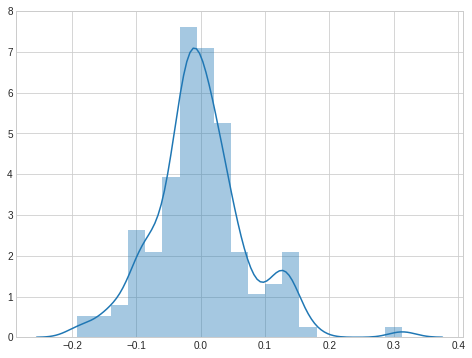

```python
y_train_predict_com = lr_combined.predict(X_train_combined_model)
residual_com = y_train_combined - y_train_predict_com

plt.figure(figsize=(8,6))
sns.distplot(residual_com)
```

The distribution is normal and the mean is also centered around 0. Therefore our assumptions hold true.

### Predicting values on the Test set:

```python
df_test_combined.head()
```

|  | car_ID | symboling | fueltype | aspiration | doornumber | enginelocation | wheelbase | carlength | carwidth | carheight | ... | ohcf | ohcv | rotor | 2bbl | 4bbl | idi | mfi | mpfi | spdi | spfi |
| --- | --- | --- | --- | --- | --- | --- | --- | --- | --- | --- | --- | --- | --- | --- | --- | --- | --- | --- | --- | --- | --- |
| 87 | 88 | 4 | 0 | 1 | 0 | 0 | 96.3 | 172.4 | 65.4 | 51.6 | ... | 0 | 0 | 0 | 0 | 0 | 0 | 0 | 0 | 1 | 0 |
| 47 | 48 | 3 | 0 | 0 | 0 | 0 | 113.0 | 199.6 | 69.6 | 52.8 | ... | 0 | 0 | 0 | 0 | 0 | 0 | 0 | 1 | 0 | 0 |
| 188 | 189 | 5 | 0 | 0 | 0 | 0 | 97.3 | 171.7 | 65.5 | 55.7 | ... | 0 | 0 | 0 | 0 | 0 | 0 | 0 | 1 | 0 | 0 |
| 145 | 146 | 3 | 0 | 1 | 0 | 0 | 97.0 | 172.0 | 65.4 | 54.3 | ... | 1 | 0 | 0 | 0 | 0 | 0 | 0 | 1 | 0 | 0 |
| 181 | 182 | 2 | 0 | 0 | 0 | 0 | 104.5 | 187.8 | 66.5 | 54.1 | ... | 0 | 0 | 0 | 0 | 0 | 0 | 0 | 1 | 0 | 0 |

5 rows × 42 columns

```python
# Rescaling the features:
num_vars_c = ['enginesize', 'peakrpm', 'price']
df_test_combined[num_vars_c] = scaler_combined.transform(df_test_combined[num_vars_c])
df_test_combined[num_vars_c].describe()
```

|  | enginesize | peakrpm | price |
| --- | --- | --- | --- |
| count | 62.000000 | 62.000000 | 62.000000 |
| mean | 0.264881 | 0.561901 | 0.221118 |
| std | 0.152592 | 0.262545 | 0.210306 |
| min | 0.109434 | 0.000000 | 0.001912 |
| 25% | 0.139623 | 0.351351 | 0.083369 |
| 50% | 0.203774 | 0.567568 | 0.128519 |
| 75% | 0.354717 | 0.729730 | 0.282856 |
| max | 0.743396 | 1.324324 | 0.792165 |

```python
# Instantiating the X and the y variables:
y_test_combined = df_test_combined.pop('price')
X_test_combined = df_test_combined

# Removing the unwanted variables:
cols = ['aspiration', 'enginelocation', 'enginesize', 'Company_Name', 'ohcv','rotor']
X_test_combined = X_test_combined[cols]
```

```python
# Adding the constant:
X_test_combined_model = sm.add_constant(X_test_combined)

# Predicting the values:
y_test_predict_combined = lr_combined.predict(X_test_combined_model)
```

### Calculating the R2 value for the Test Set:

```python
r2_test_combined = r2_score(y_true=y_test_combined, y_pred=y_test_predict_combined)
print('Test set R2: ', r2_test_combined)
r2_train_combined = r2_score(y_true=y_train_combined, y_pred=y_train_predict_com)
print('Training set R2: ', r2_train_combined)
```

```
Test set R2:  0.8164719721829357
Training set R2:  0.8545915834109542
```

This is a neat model since the value of test R2 is within 5% of the training R2.

## Comparison of all the 3 models (Manual, RFE and Combined)

#### Automated Variable Selection:

The regression equation will be:  
**price = 0.0816(b1) + 0.1903(b2)+ 1.1069(b3) + 0.0973(b4) + 0.1896(b5) - 0.1388**  
R2 = 0.835  
Adjusted R2 = 0.829  
Test R2 = 0.807  
where:  
b1 = fueltype  
b2 = enginelocation  
b3 = enginesize  
b4 = peakrpm  
b5 = rotor

From the above comparison it becomes clear that the model obtained by all 3 methods have almost the same level of accuracy, however the Adjusted R2 for Model 1 (Manual variable selection) is higher than the other two models and it is also capable of generalizing the regression line on the test dataset.  
Therefore model 1 would be the best choice in this case.